# Machine Learning Project - Predicting a country's energy mix

### Warning :

I created this project in 2024, during a Machine Learning class at ESILV. I uploaded it because some aspects are good, but it has some defaults. A new version is to be created and uploaded here, addressing the following issues : -French / English mixed up -Questioning and addressing the dataset building methodology -Trying to cluster the data in a more relevant way -More accurate geopolitical analysis about the different countries' characteristics (industry, ecology, etc.) The new version will also have to be shorter, containing an appendix for non-essential data.

This notebook contains all the work and analyses performed on the "World Energy Consumption" dataset. It must be ran using scikit learn version 1.5.2 and xgboost version 2.1.1.

```python
# All imports necessary to the project :
%pip install numpy pandas matplotlib seaborn scikit-learn==1.5.2 xgboost==2.1.1oodb tensorflow imbalanced-learn adjustText torch torchvision torchaudio kaggle
import pandas as pd
import numpy as np
import matplotlib.pyplot as plt
import seaborn as sns
from IPython.display import display
from sklearn.tree import DecisionTreeClassifier, plot_tree
from sklearn.model_selection import train_test_split, cross_val_score, GridSearchCV
from sklearn.metrics import classification_report, accuracy_score, mean_absolute_error, mean_squared_error, r2_score, f1_score
from sklearn.utils.class_weight import compute_class_weight
from sklearn.linear_model import LogisticRegression, LinearRegression
from sklearn.ensemble import RandomForestRegressor, RandomForestClassifier, GradientBoostingClassifier, VotingClassifier
from sklearn.decomposition import PCA
from sklearn.preprocessing import StandardScaler, OneHotEncoder, MinMaxScaler
from sklearn.feature_selection import RFE
from sklearn.neighbors import NearestNeighbors, KNeighborsClassifier
from sklearn.svm import SVC
from adjustText import adjust_text
from xgboost import XGBClassifier
from imblearn.over_sampling import BorderlineSMOTE, ADASYN
from imblearn.combine import SMOTETomek, SMOTEENN
from imblearn.ensemble import BalancedRandomForestClassifier, EasyEnsembleClassifier
from imblearn.under_sampling import RandomUnderSampler, NearMiss
from imblearn.over_sampling import SMOTE, BorderlineSMOTE
from imblearn.under_sampling import EditedNearestNeighbours
from imblearn.pipeline import Pipeline
from tensorflow.keras.models import Sequential
from tensorflow.keras.layers import Dense, Dropout, LSTM
from tensorflow.keras.optimizers import Adam, RMSprop, Adagrad, SGD
from tensorflow.keras.utils import to_categorical
import itertools
import torch
import torch.nn as nn
import torch.optim as optim
from zipfile import ZipFile
import warnings
warnings.filterwarnings("ignore")
```

[output not shown]

[output cut: 98 more lines]

[output not shown]

We will be using PyTorch as well. It works better on GPU but no member of our team has it, so we'll use the CPU-only version. This version will download automatically with the general installation command as follows :

```python
!kaggle datasets download -d pralabhpoudel/world-energy-consumption

dataset_zip = "world-energy-consumption.zip"
with ZipFile(dataset_zip, 'r') as zip_ref:
    zip_ref.extractall("dataset")  # Extract to a folder named 'dataset'

print("Dataset downloaded and extracted successfully!")
energy_data = pd.read_csv("dataset/World Energy Consumption.csv")
```

```python
energy_data.head()
```

|  | country | year | iso_code | population | gdp | biofuel_cons_change_pct | biofuel_cons_change_twh | biofuel_cons_per_capita | biofuel_consumption | biofuel_elec_per_capita | ... | solar_share_elec | solar_share_energy | wind_cons_change_pct | wind_cons_change_twh | wind_consumption | wind_elec_per_capita | wind_electricity | wind_energy_per_capita | wind_share_elec | wind_share_energy |
| --- | --- | --- | --- | --- | --- | --- | --- | --- | --- | --- | --- | --- | --- | --- | --- | --- | --- | --- | --- | --- | --- |
| 0 | ASEAN (Ember) | 2000 | NaN | NaN | NaN | NaN | NaN | NaN | NaN | NaN | ... | 0.0 | NaN | NaN | NaN | NaN | NaN | 0.0 | NaN | 0.0 | NaN |
| 1 | ASEAN (Ember) | 2001 | NaN | NaN | NaN | NaN | NaN | NaN | NaN | NaN | ... | 0.0 | NaN | NaN | NaN | NaN | NaN | 0.0 | NaN | 0.0 | NaN |
| 2 | ASEAN (Ember) | 2002 | NaN | NaN | NaN | NaN | NaN | NaN | NaN | NaN | ... | 0.0 | NaN | NaN | NaN | NaN | NaN | 0.0 | NaN | 0.0 | NaN |
| 3 | ASEAN (Ember) | 2003 | NaN | NaN | NaN | NaN | NaN | NaN | NaN | NaN | ... | 0.0 | NaN | NaN | NaN | NaN | NaN | 0.0 | NaN | 0.0 | NaN |
| 4 | ASEAN (Ember) | 2004 | NaN | NaN | NaN | NaN | NaN | NaN | NaN | NaN | ... | 0.0 | NaN | NaN | NaN | NaN | NaN | 0.0 | NaN | 0.0 | NaN |

5 rows × 129 columns

# Stage 1 : implementation of standard solutions

## 1. Analysis of the data

To get the spirit of the dataset, we need to identify the features and the target columns of it. Features include country, year, iso_code, population and GDP. We could use GDP as a target and the energy productions and consumptions as features but we will do it the other way around, as we're studying energy. All remaining columns, consumptions, production, and the repartition of these per capita or per way of production, will be targets.

First, let's start with a quick quality check of the data.

```python
# Let's start with displaying the informations info() allows us to access.
energy_data.info()
```

```
<class 'pandas.core.frame.DataFrame'>
RangeIndex: 22012 entries, 0 to 22011
Columns: 129 entries, country to wind_share_energy
dtypes: float64(126), int64(1), object(2)
memory usage: 21.7+ MB
```

So we have 129 columns and 22012 rows.

```python
# We'll also check for missing values :

# Missing values count per column
missing_values = energy_data.isnull().sum()
print(missing_values)

# List of columns with missing values
columns_with_missing = energy_data.columns[energy_data.isnull().any()].tolist()
print(f"Columns with missing values: {columns_with_missing}")

# Columns with all missing values
columns_all_missing = energy_data.columns[energy_data.isnull().all()].tolist()
print(f"Columns with all missing values: {columns_all_missing}")
```

```
country                       0
year                          0
iso_code                   5500
population                 3889
gdp                       10899
                          ...
wind_elec_per_capita      14947
wind_electricity          14016
wind_energy_per_capita    17947
wind_share_elec           15126
wind_share_energy         17911
Length: 129, dtype: int64
Columns with missing values: ['iso_code', 'population', 'gdp', 'biofuel_cons_change_pct', 'biofuel_cons_change_twh', 'biofuel_cons_per_capita', 'biofuel_consumption', 'biofuel_elec_per_capita', 'biofuel_electricity', 'biofuel_share_elec', 'biofuel_share_energy', 'carbon_intensity_elec', 'coal_cons_c…
Columns with all missing values: []
```

It is perfectly normal to have huge amounts of zeros or null values for certain energies or their share in the energy mixes of concerned countries, because the dataset starts a long time ago and some countries don't use all types of existing sources of energy.

```python
# Now let's check for duplicates.
duplicate_rows = energy_data.duplicated().sum()
print(f"Number of duplicate rows: {duplicate_rows}")
```

```
Number of duplicate rows: 0
```

```python
numeric_summary = energy_data.describe().transpose()
print(numeric_summary)
```

```
                           count          mean           std           min  \
year                     22012.0  1.974213e+03  3.505865e+01  1.900000e+03
population               18123.0  1.053096e+08  4.640460e+08  1.833000e+03
gdp                      11113.0  3.585114e+11  2.411179e+12  1.642060e+08
biofuel_cons_change_pct   1747.0  4.609169e+01  2.746167e+02 -1.000000e+02
biofuel_cons_change_twh   2687.0  2.719074e+00  1.005702e+01 -5.084300e+01
...                          ...           ...           ...           ...
wind_elec_per_capita      7065.0  6.281183e+01  2.527342e+02  0.000000e+00
wind_electricity          7996.0  1.756115e+01  1.016932e+02  0.000000e+00
wind_energy_per_capita    4065.0  2.321089e+02  7.338413e+02  0.000000e+00
wind_share_elec           6886.0  1.404910e+00  4.489043e+00  0.000000e+00
wind_share_energy         4101.0  6.514126e-01  1.893820e+00  0.000000e+00

                                  25%           50%           75%  \
year                     1.946000e+03  1.984000e+03  2.003000e+03
population               1.712404e+06  6.991543e+06  2.557688e+07
gdp                      1.365898e+10  4.167411e+10  1.744295e+11
biofuel_cons_change_pct -6.165000e-01  8.179000e+00  2.650850e+01
biofuel_cons_change_twh  0.000000e+00  0.000000e+00  8.615000e-01
...                               ...           ...           ...
wind_elec_per_capita     0.000000e+00  0.000000e+00  2.101000e+00
wind_electricity         0.000000e+00  0.000000e+00  1.400000e-01
wind_energy_per_capita   0.000000e+00  5.100000e-02  4.552300e+01
wind_share_elec          0.000000e+00  0.000000e+00  3.720000e-01
wind_share_energy        0.000000e+00  3.000000e-03  2.680000e-01

                                  max
year                     2.022000e+03
population               7.975105e+09
gdp                      1.136302e+14
biofuel_cons_change_pct  5.659328e+03
biofuel_cons_change_twh  1.411310e+02
...                               ...
wind_elec_per_capita     3.219852e+03
wind_electricity         2.139230e+03
wind_energy_per_capita   8.422012e+03
wind_share_elec          5.684000e+01
wind_share_energy        2.615700e+01

[127 rows x 8 columns]
```

We might need to imbalance our data. We shall check the distribution of classes in feature variables.

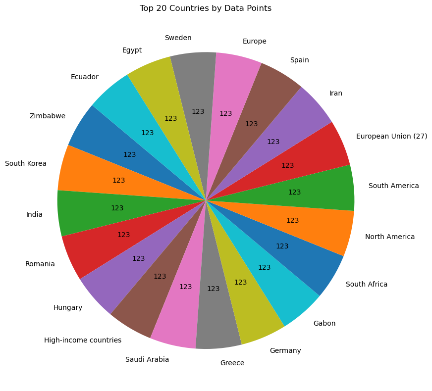

```python
top_countries = energy_data['country'].value_counts().head(20)
plt.figure(figsize=(10, 8))
top_countries.plot.pie(
    labels=top_countries.index,
    autopct=lambda p: f'{int(p * sum(top_countries) / 100)}',  # Display counts
    startangle=140,
    title="Top 20 Countries by Data Points"
)
plt.ylabel('')
plt.tight_layout()
plt.show()
```

There are no countries which appear significantly more than the others in the dataset. Thus, we don't need to imbalance the data. However, some countries will eventually have more complete data than the others. We will also need to be careful about regroupments such as "Africa", "EU", "World"... Now, let's take a look at the number of countries in it :

```python
num_distinct_countries = energy_data['country'].nunique()
print(f"Number of distinct countries: {num_distinct_countries}")
```

```
Number of distinct countries: 306
```

Countries are a categorical variable. One-Hot Encodage is not really an option because of the number of distinct countries in the dataset. We will still keep that data in the dataset, because it can be used with embeddings or CatBoost, for example.

Let's take a look at the correlation between the variables. We will do it bit by bit, because otherwise no computer will be able to face the complexity of the correlation matrix calculation.

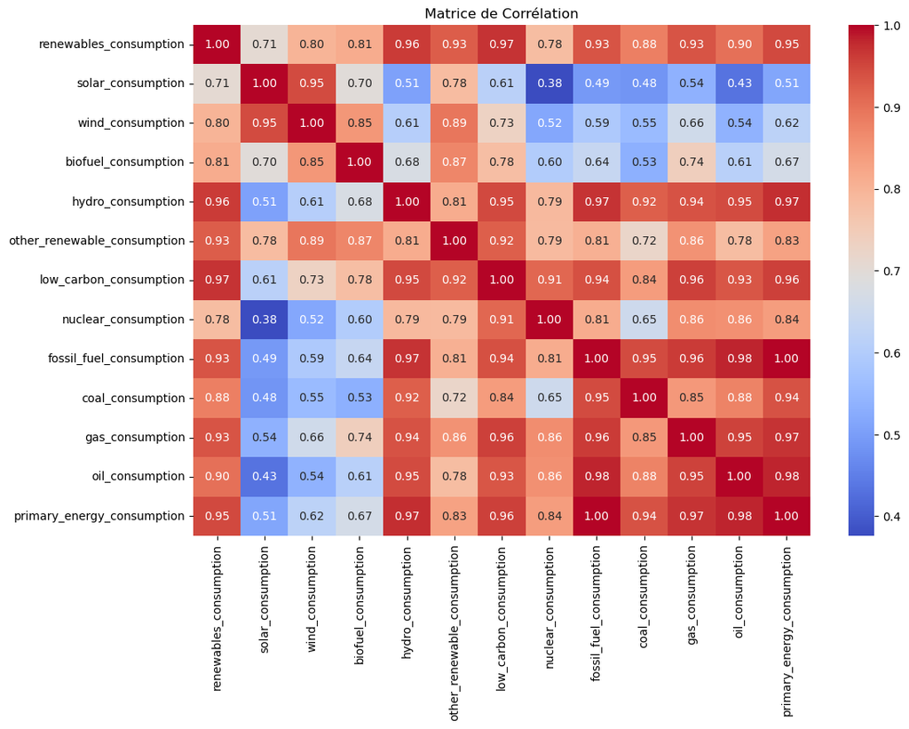

```python
# 1. First, we'll talk a look at the correlation between consumptions to see which ones evolve together :
columns_to_keep = ['renewables_consumption', 'solar_consumption', 'wind_consumption', 'biofuel_consumption', 'hydro_consumption', 'other_renewable_consumption', 'low_carbon_consumption', 'nuclear_consumption', 'fossil_fuel_consumption', 'coal_consumption', 'gas_consumption', 'oil_consumption', 'primary_energy_consumption']
df=energy_data[columns_to_keep]
correlation_matrix = df.corr()
plt.figure(figsize=(12, 8))
sns.heatmap(correlation_matrix, annot=True, fmt=".2f", cmap="coolwarm", cbar=True)
plt.title('Matrice de Corrélation')
plt.show()
```

We can see that there are very strong correlations between some variables, which is quite logic : the consumption of renewable energies is closely linked to hydro and low-carbon consumptions. We can also notice that it is linked to the fossil fuel consumption ; that is logical, because the production of renewables generally doesn't lower the production of other energies ; it often only compensates for the increase in demand. This statistical review of world energy by the energy institute explains it : https://www.energyinst.org/statistical-review.  
Low carbon is also closely linked to hydro, which is known to be a very clean source of energy. Primary energy is closely linked to fossil fuel, which is still logical, because oil and fossil fuels are widely used in regards to other primary energies such as wind or solar, so they account for more in the primary energies consumption numbers. Oil and gas are also closely linked to fossil fuels consumption. All of this indicate PCA will probably be very useful for this dataset, as a lot of data are closely linked. Now that we've checked these data, let's take a look at the links between economical and demographic data and energy consumption.

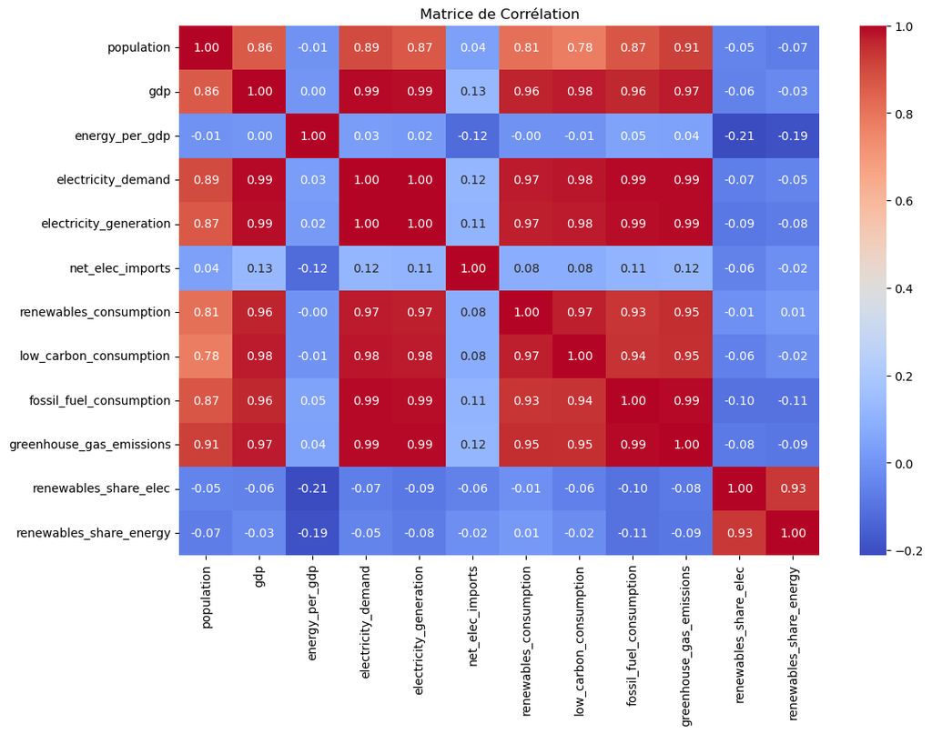

```python
# 2. Now, let's take a look at the links between demographic, economic and energy data :
columns_to_keep = ['population', 'gdp', 'energy_per_gdp', 'electricity_demand', 'electricity_generation', 'net_elec_imports', 'renewables_consumption', 'low_carbon_consumption', 'fossil_fuel_consumption', 'greenhouse_gas_emissions',  'renewables_share_elec', 'renewables_share_energy']
df=energy_data[columns_to_keep]
correlation_matrix = df.corr()
plt.figure(figsize=(12, 8))
sns.heatmap(correlation_matrix, annot=True, fmt=".2f", cmap="coolwarm", cbar=True)
plt.title('Matrice de Corrélation')
plt.show()
```

We can see that GDP is closely linked to energy consumption, more than population ; population seems to have a lower impact on energy consumption. This gives proof that energy is more a matter of standards of living than the number of people in concerned country.  
We can notice that GDP is also closely linked to energy production : we can explain that with more developed countries needing a lot of energy as they can afford to be less efficient, their economies being based on services, and population densities being higher in those kinds of countries, which have most of the time achieved their demographical transition. Countries are also producing their energy for themselves ; countries needing to import energy or not has visibly no correlation with their consumption, population or GDP.  
Despite popular belief, we can also see that countries with higher GDP are typically not "cleaner" (don't use more renewables in their energy mix) than countries with smaller economies ; that shows that it is more a matter of choice. A big or small economy has visibly no correlation with use of renewable energies.  
We can also notice that countries with higher GDP also tend to have higher greenhouse gases emissions.

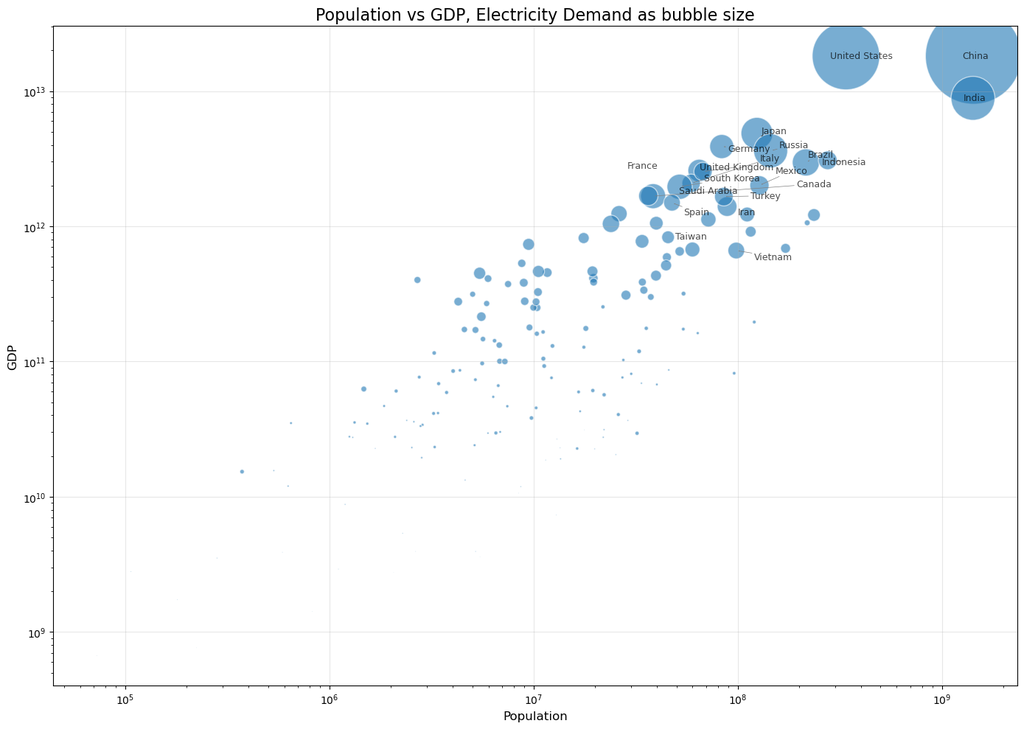

```python
latest_data = energy_data.dropna(subset=['iso_code'])  # Keep only rows with valid ISO codes
latest_data = latest_data.sort_values('year').groupby('country').last().reset_index()

# Extraire les colonnes pertinentes
plot_data = latest_data[['country', 'population', 'gdp', 'electricity_demand']].dropna()

top_countries = plot_data.nlargest(20, 'electricity_demand')

# Créer le graphique
plt.figure(figsize=(14, 10))
plt.scatter(
    plot_data['population'],
    plot_data['gdp'],
    s=plot_data['electricity_demand'],
    alpha=0.6,
    edgecolor="w"
)

# Préparer les étiquettes uniquement pour les 20 plus gros pays
texts = []
for i, row in top_countries.iterrows():
    texts.append(plt.text(
        row['population'],
        row['gdp'],
        row['country'],
        fontsize=9,
        alpha=0.7
    ))

# Ajuster automatiquement les positions des étiquettes
adjust_text(
    texts,
    arrowprops=dict(arrowstyle="->", color='gray', lw=0.5)  # Ajouter des flèches pour plus de clarté
)

# Ajouter des labels, un titre et des échelles
plt.title("Population vs GDP, Electricity Demand as bubble size", fontsize=16)
plt.xlabel("Population", fontsize=12)
plt.ylabel("GDP", fontsize=12)
plt.xscale('log')  # Échelle logarithmique pour la population
plt.yscale('log')  # Échelle logarithmique pour le PIB
plt.grid(alpha=0.3)

# Afficher le graphique
plt.tight_layout()
plt.show()
```

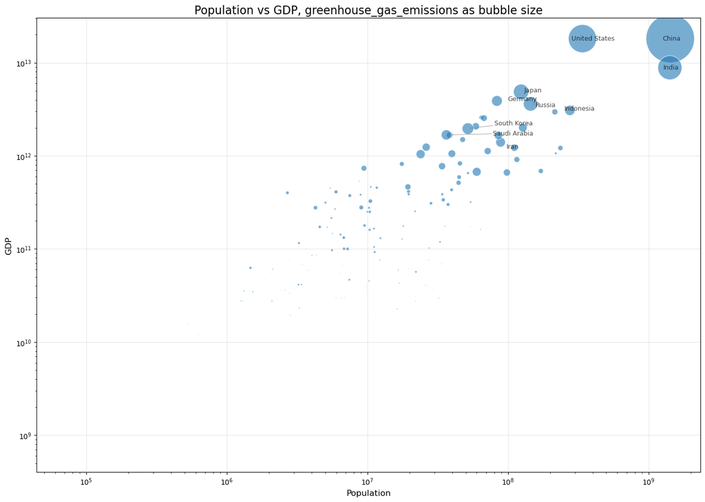

```python
latest_data = energy_data.dropna(subset=['iso_code'])  # Keep only rows with valid ISO codes
latest_data = latest_data.sort_values('year').groupby('country').last().reset_index()

# Extraire les colonnes pertinentes
plot_data = latest_data[['country', 'population', 'gdp', 'greenhouse_gas_emissions']].dropna()


top_countries = plot_data.nlargest(10, 'greenhouse_gas_emissions')

# Créer le graphique
plt.figure(figsize=(14, 10))
plt.scatter(
    plot_data['population'],
    plot_data['gdp'],
    s=plot_data['greenhouse_gas_emissions'],
    alpha=0.6,
    edgecolor="w"
)

# Préparer les étiquettes pour les 20 plus gros pays
texts = []
for i, row in top_countries.iterrows():
    texts.append(plt.text(
        row['population'],
        row['gdp'],
        row['country'],
        fontsize=9,
        alpha=0.7
    ))

# Ajuster automatiquement les positions des étiquettes
adjust_text(
    texts,
    arrowprops=dict(arrowstyle="->", color='gray', lw=0.5)  # Ajouter des flèches pour plus de clarté
)

# Ajouter des labels, un titre et des échelles
plt.title("Population vs GDP, greenhouse_gas_emissions as bubble size", fontsize=16)
plt.xlabel("Population", fontsize=12)
plt.ylabel("GDP", fontsize=12)
plt.xscale('log')  # Échelle logarithmique pour la population
plt.yscale('log')  # Échelle logarithmique pour le PIB
plt.grid(alpha=0.3)

# Afficher le graphique
plt.tight_layout()
plt.show()
```

These graphs confirm that there still seems to be a correlation between population and gdp on one side and greenhouse gas emission and energy consumption on the other side, even though it's not always exact.

Let's take a look at different data evolutions through the years !

```python
columns_to_keep = ['iso_code', 'year', 'population', 'gdp', 'energy_per_gdp', 'electricity_demand',  'renewables_consumption', 'low_carbon_consumption', 'fossil_fuel_consumption', 'greenhouse_gas_emissions',  'renewables_share_elec', 'renewables_share_energy', 'renewables_share_elec', 'electricity_generation', 'energy_per_capita']
df=energy_data[columns_to_keep]
# We also need to drop the rows for agregations of countries, otherwise there will be a bias. We consider the agregations are all rows which don't have ISO codes.
df = df.dropna(subset=['iso_code'])
print(df.info())
```

```
<class 'pandas.core.frame.DataFrame'>
Index: 16512 entries, 23 to 22011
Data columns (total 15 columns):
 #   Column                    Non-Null Count  Dtype
---  ------                    --------------  -----
 0   iso_code                  16512 non-null  object
 1   year                      16512 non-null  int64
 2   population                16396 non-null  float64
 3   gdp                       10870 non-null  float64
 4   energy_per_gdp            7151 non-null   float64
 5   electricity_demand        5116 non-null   float64
 6   renewables_consumption    4067 non-null   float64
 7   low_carbon_consumption    4067 non-null   float64
 8   fossil_fuel_consumption   3557 non-null   float64
 9   greenhouse_gas_emissions  4766 non-null   float64
 10  renewables_share_elec     5674 non-null   float64
 11  renewables_share_energy   3382 non-null   float64
 12  renewables_share_elec     5674 non-null   float64
 13  electricity_generation    5982 non-null   float64
 14  energy_per_capita         9842 non-null   float64
dtypes: float64(13), int64(1), object(1)
memory usage: 2.0+ MB
None
```

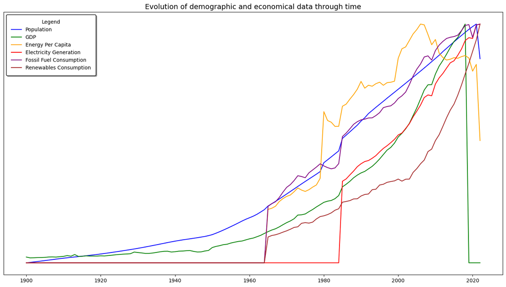

```python
metrics_by_year = df.groupby('year')[[
    'population',
    'gdp',
    'energy_per_capita',
    'electricity_generation',
    'fossil_fuel_consumption',
    'renewables_consumption'
]].sum()

# We normalize the data to compare their evolution and not their values !
metrics_normalized = metrics_by_year.apply(lambda x: (x - x.min()) / (x.max() - x.min()), axis=0)

fig, ax = plt.subplots(figsize=(14, 8))
colors = ['blue', 'green', 'orange', 'red', 'purple', 'brown']
labels = [
    'Population',
    'GDP',
    'Energy Per Capita',
    'Electricity Generation',
    'Fossil Fuel Consumption',
    'Renewables Consumption'
]

for column, color, label in zip(metrics_normalized.columns, colors, labels):
    ax.plot(metrics_normalized.index, metrics_normalized[column], label=label, color=color)

legend = ax.legend(loc="upper left", title="Legend", frameon=True, fancybox=True, shadow=True, borderpad=1)
legend.get_frame().set_edgecolor('black')
ax.tick_params(left=False, bottom=True, labelleft=False, labelbottom=True)
ax.set_title("Evolution of demographic and economical data through time", fontsize=14)
plt.tight_layout()
plt.show()
```

The number of available data after 2020 decreases. It's probably because some data has not been put in yet. When we will make predictions, we should keep some only to check for predictions, but let's not use these for training. We can also see that it is visibly useless to use data about energy before 1965. Let's check this :

```python
df = energy_data[(energy_data['year'] <= 1965) & (energy_data['year'] > 1955)]
df = df.dropna(subset=['iso_code'])
df = df.groupby('year', as_index=False)[['energy_per_capita', 'electricity_generation', 'fossil_fuel_consumption', 'renewables_consumption']].sum()


def highlight_zero_and_null(val):
    if pd.isnull(val):  # Vérifier si la valeur est NaN
        return 'background-color: red'
    elif val == 0:  # Vérifier si la valeur est 0
        return 'background-color: red'
    else:
        return ''


styled_df = df.style.applymap(highlight_zero_and_null)
display(styled_df)
```

|  | year | energy_per_capita | electricity_generation | fossil_fuel_consumption | renewables_consumption |
| --- | --- | --- | --- | --- | --- |
| 0 | 1956 | 0.000000 | 0.000000 | 0.000000 | 0.000000 |
| 1 | 1957 | 0.000000 | 0.000000 | 0.000000 | 0.000000 |
| 2 | 1958 | 0.000000 | 0.000000 | 0.000000 | 0.000000 |
| 3 | 1959 | 0.000000 | 0.000000 | 0.000000 | 0.000000 |
| 4 | 1960 | 0.000000 | 0.000000 | 0.000000 | 0.000000 |
| 5 | 1961 | 0.000000 | 0.000000 | 0.000000 | 0.000000 |
| 6 | 1962 | 0.000000 | 0.000000 | 0.000000 | 0.000000 |
| 7 | 1963 | 0.000000 | 0.000000 | 0.000000 | 0.000000 |
| 8 | 1964 | 0.000000 | 0.000000 | 0.000000 | 0.000000 |
| 9 | 1965 | 1468722.043000 | 0.000000 | 31121.957000 | 2446.405000 |

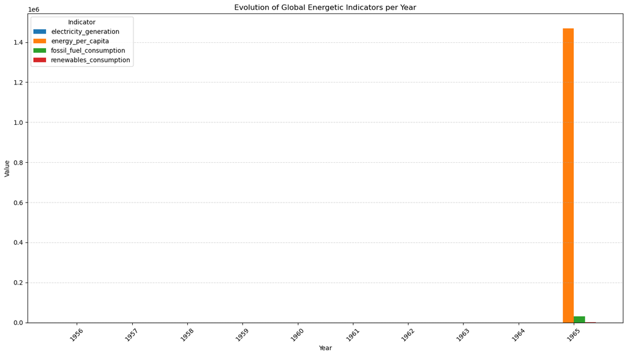

```python
df_long = pd.melt(df, id_vars=['year'], var_name='Indicator', value_name='Value')
df_long = df_long.pivot(index='year', columns='Indicator', values='Value').fillna(0).reset_index()

# Prepare the data for the barplot
indicators = df_long.columns[1:]
years = df_long['year']
bar_width = 0.2
x_positions = np.arange(len(years))

# Create graphic
plt.figure(figsize=(14, 8))
for i, indicator in enumerate(indicators):
    plt.bar(x_positions + i * bar_width, df_long[indicator], width=bar_width, label=indicator)

# Add labels
plt.xticks(x_positions + bar_width * (len(indicators) - 1) / 2, years, rotation=45)
plt.title("Evolution of Global Energetic Indicators per Year")
plt.xlabel("Year")
plt.ylabel("Value")
plt.legend(title="Indicator")
plt.grid(axis="y", linestyle="--", alpha=0.5)
plt.tight_layout()

plt.show()
```

We can also check energy consumption per geographical and economical area :

```python
countries_to_keep = ["Antarctica", "Asia", "Oceania", "Europe", "North America", "South America", "Africa"]
df = energy_data[energy_data['country'].isin(countries_to_keep)][
    ['year', 'country', 'energy_per_capita', 'electricity_generation',
     'fossil_fuel_consumption', 'renewables_consumption']
]

# Deleting the lines where all columns except year and country are null or =0
df = df.dropna(subset=['energy_per_capita', 'electricity_generation',
                       'fossil_fuel_consumption', 'renewables_consumption'], how='all')

styled_df = df.head(15).style.applymap(highlight_zero_and_null)
display(styled_df)
```

|  | year | country | energy_per_capita | electricity_generation | fossil_fuel_consumption | renewables_consumption |
| --- | --- | --- | --- | --- | --- | --- |
| 210 | 1965 | Africa | 2228.423000 | nan | 675.202000 | 41.119000 |
| 211 | 1966 | Africa | 2275.487000 | nan | 704.270000 | 45.863000 |
| 212 | 1967 | Africa | 2241.349000 | nan | 710.059000 | 47.876000 |
| 213 | 1968 | Africa | 2307.324000 | nan | 744.596000 | 56.000000 |
| 214 | 1969 | Africa | 2310.408000 | nan | 757.316000 | 65.352000 |
| 215 | 1970 | Africa | 2443.656000 | nan | 811.332000 | 81.703000 |
| 216 | 1971 | Africa | 2541.196000 | nan | 875.723000 | 77.445000 |
| 217 | 1972 | Africa | 2618.036000 | nan | 919.611000 | 88.152000 |
| 218 | 1973 | Africa | 2761.800000 | nan | 998.266000 | 93.232000 |
| 219 | 1974 | Africa | 2822.004000 | nan | 1039.903000 | 106.026000 |
| 220 | 1975 | Africa | 2908.514000 | nan | 1102.390000 | 112.081000 |
| 221 | 1976 | Africa | 3070.085000 | nan | 1194.641000 | 124.186000 |
| 222 | 1977 | Africa | 3150.411000 | nan | 1255.128000 | 136.414000 |
| 223 | 1978 | Africa | 3179.803000 | nan | 1307.552000 | 137.552000 |
| 224 | 1979 | Africa | 3364.423000 | nan | 1427.264000 | 147.205000 |

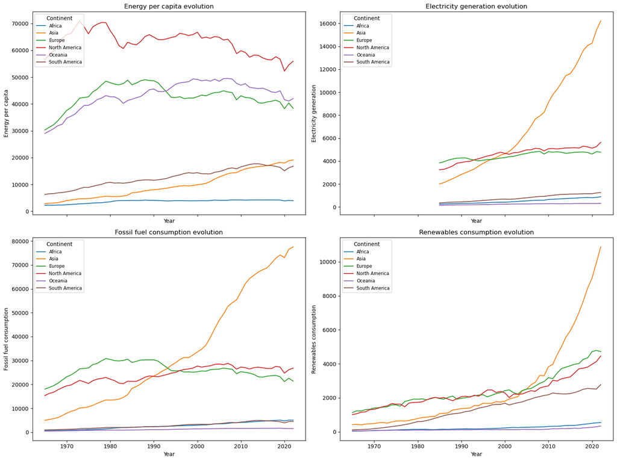

```python
# Now let's print the graph :
# First, let's list the indicators we want to display :
indicators = ['energy_per_capita', 'electricity_generation', 'fossil_fuel_consumption', 'renewables_consumption']

fig, axes = plt.subplots(2, 2, figsize=(16, 12), sharex=True)

# Associate indicators with subgraphs :
for indicator, ax in zip(indicators, axes.flatten()):
    for country in df['country'].unique():
        subset = df[df['country'] == country]
        ax.plot(subset['year'], subset[indicator], label=country)
    ax.set_title(f"{indicator.replace('_', ' ').capitalize()} evolution")
    ax.set_xlabel("Year")
    ax.set_ylabel(indicator.replace('_', ' ').capitalize())
    ax.legend(title="Continent", loc="upper left", fontsize="small")
plt.tight_layout()
plt.show()
```

Let's also take a look on whether or not countries will be able to use low carbon electricity and renewable energies.

```python
energy_data['low_carbon_electricity_percentage'] = np.where(
    energy_data['electricity_generation'] == 0,
    np.nan,
    (energy_data['low_carbon_electricity'] / energy_data['electricity_generation']) * 100
)

# Calculate the rate of renewable energy while avoiding dividing by 0.
energy_data['renewable_energy_percentage'] = np.where(
    (energy_data['renewables_consumption'] + energy_data['fossil_fuel_consumption']) == 0,
    np.nan,
    (energy_data['renewables_consumption'] /
     (energy_data['renewables_consumption'] + energy_data['fossil_fuel_consumption'])) * 100
)

# Filtrate the last 10 years available for each country.
latest_years = energy_data.groupby('country')['year'].nlargest(10).reset_index(level=0)
latest_data = energy_data.merge(latest_years, on=['country', 'year'])

# Compute the average for each country on the last 10 years.
average_data = latest_data.groupby('country')[['low_carbon_electricity_percentage', 'renewable_energy_percentage']].mean()

# Sort the countries for each indicator
top_25_low_carbon = average_data[['low_carbon_electricity_percentage']].sort_values(
    by='low_carbon_electricity_percentage', ascending=False
).head(25)

top_25_renewable = average_data[['renewable_energy_percentage']].sort_values(
    by='renewable_energy_percentage', ascending=False
).head(25)


def color_percentage(val):
    if pd.isnull(val):  # Handle the NaN
        return ''
    elif val == 100:
        return 'background-color: darkgreen; color: white'
    elif val > 90:
        return 'background-color: green; color: white'
    elif val > 70:
        return 'background-color: lightgreen; color: black'
    elif val > 50:
        return 'background-color: lightblue; color: black'
    elif val > 30:
        return 'background-color: blue; color: white'
    else:
        return ''


styled_top_25_low_carbon = top_25_low_carbon.style.applymap(color_percentage).set_caption(
    "Top 25 Countries by Average Low Carbon Electricity Percentage"
)
styled_top_25_renewable = top_25_renewable.style.applymap(color_percentage).set_caption(
    "Top 25 Countries by Average Renewable Energy Percentage"
)

display(styled_top_25_low_carbon)
display(styled_top_25_renewable)
```

Top 25 Countries by Average Low Carbon Electricity Percentage

| country | low_carbon_electricity_percentage |
| --- | --- |
| Bhutan | 100.000000 |
| Albania | 100.000000 |
| Lesotho | 100.000000 |
| Iceland | 99.999005 |
| Paraguay | 99.931992 |
| Nepal | 99.914771 |
| Ethiopia | 99.828300 |
| Democratic Republic of Congo | 99.800786 |
| Central African Republic | 98.333333 |
| Norway | 98.243286 |
| Sweden | 97.986816 |
| Namibia | 97.101798 |
| Costa Rica | 95.969431 |
| Tajikistan | 95.869672 |
| Switzerland | 94.746326 |
| Eswatini | 94.133880 |
| Zambia | 92.704544 |
| Uganda | 92.529311 |
| Kyrgyzstan | 91.074149 |
| Malawi | 90.815252 |
| France | 90.671486 |
| Mozambique | 87.591424 |
| Uruguay | 86.000675 |
| Kenya | 84.960573 |
| Afghanistan | 84.661710 |

Top 25 Countries by Average Renewable Energy Percentage

| country | renewable_energy_percentage |
| --- | --- |
| Norway | 70.042298 |
| Sweden | 60.205065 |
| Brazil | 44.391499 |
| Switzerland | 41.112522 |
| New Zealand | 38.568109 |
| Finland | 36.342129 |
| Austria | 35.810856 |
| South America | 34.611259 |
| Eastern Africa (EI) | 33.075922 |
| Denmark | 32.704091 |
| South and Central America (EI) | 31.834287 |
| Canada | 31.467086 |
| Colombia | 28.680087 |
| Peru | 28.220348 |
| Portugal | 28.183076 |
| Central America (EI) | 28.142140 |
| Middle Africa (EI) | 26.961145 |
| Ecuador | 26.440867 |
| Croatia | 25.600743 |
| Venezuela | 25.138047 |
| Latvia | 23.812458 |
| Chile | 22.971898 |
| Slovenia | 22.477558 |
| Vietnam | 21.383406 |
| Spain | 21.310096 |

Over the last 10 years, a lot of countries have low carbon electricity. We can try later to predict whether or not a country has low carbon electricity. Fewer countries have renewable energy.

To conclude with this part of data analysis and adaptation, we chose to not reduce, normalize or standardize the data now. We will train the models with data reduced and not reduced, thus we will see if it's more efficient to not perform these operations on this dataset using verifications. Moreover, some of these simplification options are useful only with certain algorithms, like a linear regression. We will eventually use them, but only when needed.

## 2. Implement solutions for each task using the algos seen in class.

We will try to predict energy consumption for the years to come, in different countries and different continents. We will also look at the ability of the country to use low carbon electricity.

### First, let's look at whether or not we can predict ability of countries to get low-carbon electricity.

Let's start with defining what we call ability of countries to get low-carbon electricity. Let's take a look at the distribution of different rates of low-carbon electricity :

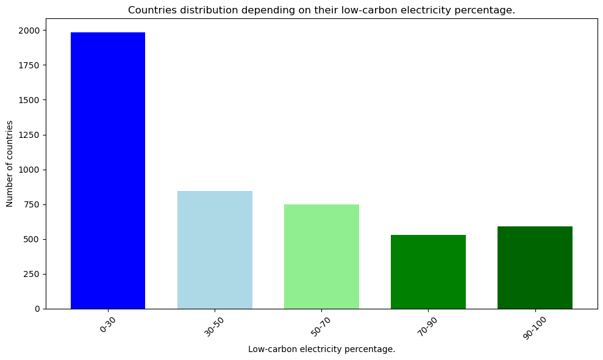

```python
# Filtrate data to keep only countries with ISO code.
filtered_data = energy_data.dropna(subset=['iso_code'])

# Compute low-carbon electricity percentage.
filtered_data['low_carbon_electricity_percentage'] = np.where(
    filtered_data['electricity_generation'] == 0,
    np.nan,
    (filtered_data['low_carbon_electricity'] / filtered_data['electricity_generation']) * 100)
filtered_data = filtered_data.dropna(subset=['low_carbon_electricity_percentage'])

# Create intervals for percentages
bins = [0, 30, 50, 70, 90, 100]
labels = ['0-30', '30-50', '50-70', '70-90', '90-100']

# Add a column for categories.
filtered_data['category'] = pd.cut(
    filtered_data['low_carbon_electricity_percentage'], bins=bins, labels=labels, right=True)
distribution = filtered_data['category'].value_counts(sort=False)

plt.figure(figsize=(10, 6))
plt.bar(distribution.index, distribution.values, width=0.7, color=['blue', 'lightblue', 'lightgreen', 'green', 'darkgreen'])
plt.title("Countries distribution depending on their low-carbon electricity percentage.")
plt.xlabel("Low-carbon electricity percentage.")
plt.ylabel("Number of countries")
plt.xticks(rotation=45)
plt.tight_layout()
plt.show()
```

```
Number of countries with more than 50% low-carbon electricty : 72 (34.29%)
Number of countries with 50% or less low-carbon electricity : 138 (65.71%)
Total number of countries : 210
```

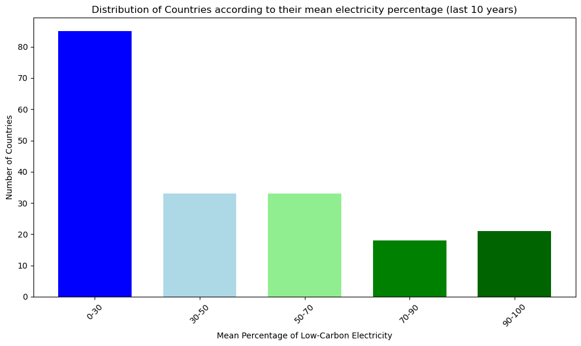

```python
filtered_data = energy_data.dropna(subset=['iso_code'])

filtered_data['low_carbon_electricity_percentage'] = np.where(
    filtered_data['electricity_generation'] == 0,
    np.nan,
    (filtered_data['low_carbon_electricity'] / filtered_data['electricity_generation']) * 100)
filtered_data = filtered_data.dropna(subset=['low_carbon_electricity_percentage'])

# Identify the last 10 years with data for each country.
latest_years = filtered_data.groupby('country')['year'].nlargest(10).reset_index(level=0)

# Join to keep only the last 10 years.
latest_data = filtered_data.merge(latest_years, on=['country', 'year'])

# Compute the mean for the last 10 years for each country.
average_data = latest_data.groupby('country')['low_carbon_electricity_percentage'].mean().reset_index()

# Count the countries higher and below 50%.
total_countries = average_data['country'].nunique()
above_50 = average_data[average_data['low_carbon_electricity_percentage'] > 50].shape[0]
below_or_equal_50 = average_data[average_data['low_carbon_electricity_percentage'] <= 50].shape[0]
above_50_percentage = (above_50 / total_countries) * 100
below_or_equal_50_percentage = (below_or_equal_50 / total_countries) * 100
print(f"Number of countries with more than 50% low-carbon electricty : {above_50} ({above_50_percentage:.2f}%)")
print(f"Number of countries with 50% or less low-carbon electricity : {below_or_equal_50} ({below_or_equal_50_percentage:.2f}%)")

bins = [0, 30, 50, 70, 90, 100]
labels = ['0-30', '30-50', '50-70', '70-90', '90-100']

average_data['category'] = pd.cut(average_data['low_carbon_electricity_percentage'], bins=bins, labels=labels, right=True)
distribution = average_data['category'].value_counts(sort=False)

print(f"Total number of countries : {average_data['country'].nunique()}")
plt.figure(figsize=(10, 6))
plt.bar(distribution.index, distribution.values, width=0.7, color=['blue', 'lightblue', 'lightgreen', 'green', 'darkgreen'])
plt.title("Distribution of Countries according to their mean electricity percentage (last 10 years)")
plt.xlabel("Mean Percentage of Low-Carbon Electricity")
plt.ylabel("Number of Countries")
plt.xticks(rotation=45)
plt.tight_layout()
plt.show()
```

We have about 35-65% ratio of countries having more than 50% low-carbon energy. That is enough to not need to balance the data. Here we are observing a small amount of data (210 countries) ; thus, Logistic Regression and Decision Tree are the better "beginner" options to try and predict whether or not a country has low carbon energy. Let's start with adding a binary column indicating "1" if the country is using more than 50% low-carbon energy, "0" if not.

```python
filtered_data = energy_data.dropna(subset=['iso_code'])

# Compute the percentage of low-carbon electricity (while avoiding x/0)
filtered_data['low_carbon_electricity_percentage'] = np.where(
    filtered_data['electricity_generation'] == 0,
    np.nan,
    (filtered_data['low_carbon_electricity'] / filtered_data['electricity_generation']) * 100)
latest_years = filtered_data.groupby('country')['year'].nlargest(10).reset_index(level=0)
latest_data = filtered_data.merge(latest_years, on=['country', 'year'])

# Add the column "low_carbon-binary"
latest_data['low_carbon_binary'] = (latest_data['low_carbon_electricity_percentage'] > 50).astype(int)

# Display the df
display(latest_data.head())
```

|  | country | year | iso_code | population | gdp | biofuel_cons_change_pct | biofuel_cons_change_twh | biofuel_cons_per_capita | biofuel_consumption | biofuel_elec_per_capita | ... | wind_cons_change_twh | wind_consumption | wind_elec_per_capita | wind_electricity | wind_energy_per_capita | wind_share_elec | wind_share_energy | low_carbon_electricity_percentage | renewable_energy_percentage | low_carbon_binary |
| --- | --- | --- | --- | --- | --- | --- | --- | --- | --- | --- | --- | --- | --- | --- | --- | --- | --- | --- | --- | --- | --- |
| 0 | Afghanistan | 2012 | AFG | 30466484.0 | 5.916690e+10 | NaN | NaN | NaN | NaN | 0.0 | ... | NaN | NaN | 0.0 | 0.0 | NaN | 0.0 | NaN | 84.090909 | NaN | 1 |
| 1 | Afghanistan | 2013 | AFG | 31541216.0 | 6.299370e+10 | NaN | NaN | NaN | NaN | 0.0 | ... | NaN | NaN | 0.0 | 0.0 | NaN | 0.0 | NaN | 80.180180 | NaN | 1 |
| 2 | Afghanistan | 2014 | AFG | 32716214.0 | 6.434611e+10 | NaN | NaN | NaN | NaN | 0.0 | ... | NaN | NaN | 0.0 | 0.0 | NaN | 0.0 | NaN | 86.206897 | NaN | 1 |
| 3 | Afghanistan | 2015 | AFG | 33753500.0 | 6.278339e+10 | NaN | NaN | NaN | NaN | 0.0 | ... | NaN | NaN | 0.0 | 0.0 | NaN | 0.0 | NaN | 87.288136 | NaN | 1 |
| 4 | Afghanistan | 2016 | AFG | 34636212.0 | 6.429743e+10 | NaN | NaN | NaN | NaN | 0.0 | ... | NaN | NaN | 0.0 | 0.0 | NaN | 0.0 | NaN | 87.603306 | NaN | 1 |

5 rows × 132 columns

```python
df = latest_data[['renewables_consumption', 'fossil_fuel_consumption', 'electricity_generation', 'population', 'gdp', 'low_carbon_binary']]
df = df.dropna()
display(df.head())
print(f"Number of rows after cleanup : {df.shape[0]}")
print(f"Number of low-carbon countries on given years : {df['low_carbon_binary'].sum()}")
```

|  | renewables_consumption | fossil_fuel_consumption | electricity_generation | population | gdp | low_carbon_binary |
| --- | --- | --- | --- | --- | --- | --- |
| 20 | 0.348 | 536.629 | 56.32 | 38000628.0 | 5.118877e+11 | 0 |
| 21 | 0.688 | 584.925 | 60.40 | 38760168.0 | 5.313081e+11 | 0 |
| 22 | 0.598 | 616.920 | 64.68 | 39543148.0 | 5.515191e+11 | 0 |
| 23 | 0.900 | 616.096 | 66.77 | 40339328.0 | 5.746961e+11 | 0 |
| 24 | 1.541 | 622.254 | 71.50 | 41136548.0 | 5.821672e+11 | 0 |

```
Number of rows after cleanup : 410
Number of low-carbon countries on given years : 151
```

## A. Decision Tree

We still a relatively balanced data when we take it per country and per year instead of computing the mean for a country over the period of time. We will still be able to use solutions such as "class_weight='balanced'" or SMOTE to see if these are more efficient.

```python
features = ['renewables_consumption', 'fossil_fuel_consumption', 'electricity_generation', 'population', 'gdp']
X = df[features]
y = df['low_carbon_binary']
# Right before we're just checking that X and y don't contain NaN !

# Divide the data in training and test ensembles.
X_train, X_test, y_train, y_test = train_test_split(X, y, test_size=0.3, random_state=42)

# Train a decision tree
clf = DecisionTreeClassifier(max_depth=5, random_state=42)
clf.fit(X_train, y_train)

# Predict on the test ensemble.
y_pred = clf.predict(X_test)

# Print the results
print("Accuracy:", accuracy_score(y_test, y_pred))
print("\nClassification Report:\n", classification_report(y_test, y_pred))
```

```
Accuracy: 0.9024390243902439

Classification Report:
               precision    recall  f1-score   support

           0       0.99      0.87      0.92        84
           1       0.78      0.97      0.86        39

    accuracy                           0.90       123
   macro avg       0.88      0.92      0.89       123
weighted avg       0.92      0.90      0.90       123
```

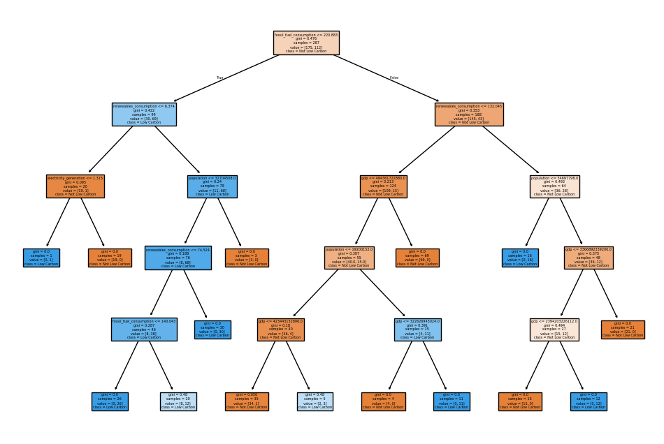

```python
# Let's visualize the tree :
plt.figure(figsize=(12, 8))
plot_tree(clf, feature_names=features, class_names=["Not Low Carbon", "Low Carbon"], filled=True)
plt.show()
```

These indicate that the model predicts the correct class for most of the instances (90% of the time in total). It has a very high precision for class 0, which means that when the model predicts 0, it is almost always correct. It has a high F1-Score, indicating good precision and recall. When the model predicts 1, it is correct 78% of the time. The fact that this is also the least frequent class tells us to remain prudent, as it is worse than the score for class 0. However, it has a very good recall, meaning that it successfully identifies most of the actual instances of 1. That's also what Weighted Average tells us : with an F1-score of 90%, the model is quite good.

Support for class 0 (84) being more than the double that of class 1 (39) is an imbalance. This can influence the performance metrics. Let's try to do it again, this time imbalancing data before with SMOTE :

```python
features = ['renewables_consumption', 'fossil_fuel_consumption', 'electricity_generation', 'population', 'gdp']
X = df[features]
y = df['low_carbon_binary']

X_train, X_test, y_train, y_test = train_test_split(X, y, test_size=0.3, random_state=42)

# Apply SMOTE to balance the classes in the training set.
smote = SMOTE(random_state=42)
X_train_resampled, y_train_resampled = smote.fit_resample(X_train, y_train)

# Print the class distribution before and after SMOTE.
print("Class distribution before SMOTE :")
print(y_train.value_counts())
print("\nClass distribution after SMOTE :")
print(pd.Series(y_train_resampled).value_counts())

clf = DecisionTreeClassifier(max_depth=5, random_state=42)
clf.fit(X_train_resampled, y_train_resampled)

y_pred = clf.predict(X_test)

print("Accuracy:", accuracy_score(y_test, y_pred))
print("\nClassification Report:\n", classification_report(y_test, y_pred))
```

```
Class distribution before SMOTE :
low_carbon_binary
0    175
1    112
Name: count, dtype: int64

Class distribution after SMOTE :
low_carbon_binary
1    175
0    175
Name: count, dtype: int64
Accuracy: 0.8943089430894309

Classification Report:
               precision    recall  f1-score   support

           0       0.99      0.86      0.92        84
           1       0.76      0.97      0.85        39

    accuracy                           0.89       123
   macro avg       0.87      0.92      0.89       123
weighted avg       0.91      0.89      0.90       123
```

After SMOTE, all metrics are either slightly decreased or unchanged. A slight drop in accuracy is expected because SMOTE modifies the training data, prioritizing class balance over the overall accuracy. Metrics for class 0 remain stable, with only a minor decrease in recall (from 87% to 86%), reflecting that the model still performs well for the majority class. Metrics for class 1 remained stable as well, as recall remains very high (97%), indicating that the model continues to identify most positive cases. Precision dropped slightly (from 78% to 76%), showing a marginal increase in false positives for class 1. SMOTE did not give results that were way worse, but it is of better use in models with low recall for the minority class. Here, recall for class 1 was already high. We can explain that with the strong correlation between some of the variables and the target, low_carbon, as shown previously in the correlation matrix.

We can still try again to make it better using automatic class weight balancing :

```python
clf = DecisionTreeClassifier(max_depth=5, class_weight='balanced', random_state=42)
clf.fit(X_train, y_train)

# Predict on the test ensemble
y_pred = clf.predict(X_test)

# Print the results
print("Accuracy:", accuracy_score(y_test, y_pred))
print("\nClassification Report:\n", classification_report(y_test, y_pred))
```

```
Accuracy: 0.9024390243902439

Classification Report:
               precision    recall  f1-score   support

           0       0.99      0.87      0.92        84
           1       0.78      0.97      0.86        39

    accuracy                           0.90       123
   macro avg       0.88      0.92      0.89       123
weighted avg       0.92      0.90      0.90       123
```

We have the exact same results as when we were not using the "class_weight='balanced'" parameter ! Let's check the distribution of class weights :

```python
class_weights = compute_class_weight(class_weight='balanced', classes=np.array([0, 1]),y=y_train)
print(f"Class weights: {dict(zip(np.array([0, 1]), class_weights))}")
```

```
Class weights: {0: 0.82, 1: 1.28125}
```

Class weights are quite close to 1. That explains why results aren't enhanced by their balancing. Let's also try with Logistic Regression to see if it gives better results.

## B. Logistic Regression

```python
features = ['renewables_consumption', 'fossil_fuel_consumption', 'electricity_generation', 'population', 'gdp']
X = df[features]
y = df['low_carbon_binary']

X_train, X_test, y_train, y_test = train_test_split(X, y, test_size=0.3, random_state=42)

# Train the Logistic Regression
clf = LogisticRegression(class_weight='balanced', random_state=42, max_iter=1000)
clf.fit(X_train, y_train)

y_pred = clf.predict(X_test)

print("Accuracy:", accuracy_score(y_test, y_pred))
print("\nClassification Report:\n", classification_report(y_test, y_pred))
```

```
Accuracy: 0.6829268292682927

Classification Report:
               precision    recall  f1-score   support

           0       0.68      1.00      0.81        84
           1       0.00      0.00      0.00        39

    accuracy                           0.68       123
   macro avg       0.34      0.50      0.41       123
weighted avg       0.47      0.68      0.55       123
```

This model gives an accuracy of 68%. However, this is high accuracy is misleading because it has not predicted any instance of the class 1. Let's try to adjust the threshold to get better results. Then we'll try to use SMOTE and the class balance to see if it gives better results.

```python
# Predict probabilities
y_prob = clf.predict_proba(X_test)[:, 1]

# Adjust threshold
threshold = 0.3
y_pred_adjusted = (y_prob >= threshold).astype(int)

# Evaluate with the adjusted threshold
print("Adjusted Classification Report:\n", classification_report(y_test, y_pred_adjusted))

adjusted_accuracy = accuracy_score(y_test, y_pred_adjusted)
print(f"Adjusted Accuracy (Threshold = {threshold}): {adjusted_accuracy:.4f}")
```

```
Adjusted Classification Report:
               precision    recall  f1-score   support

           0       1.00      0.23      0.37        84
           1       0.38      1.00      0.55        39

    accuracy                           0.47       123
   macro avg       0.69      0.61      0.46       123
weighted avg       0.80      0.47      0.42       123

Adjusted Accuracy (Threshold = 0.3): 0.4715
```

```python
smote = SMOTE(random_state=42)
X_train_resampled, y_train_resampled = smote.fit_resample(X_train, y_train)

print("Class distribution before SMOTE :")
print(y_train.value_counts())
print("\nClass distribution after SMOTE :")
print(pd.Series(y_train_resampled).value_counts())

# Train a logistic regression model
clf = LogisticRegression(random_state=42, max_iter=1000)
clf.fit(X_train_resampled, y_train_resampled)

# Predict on the test set
y_pred = clf.predict(X_test)

# Display the results
print("Accuracy:", accuracy_score(y_test, y_pred))
print("\nClassification Report:\n", classification_report(y_test, y_pred))
```

```
Class distribution before SMOTE :
low_carbon_binary
0    175
1    112
Name: count, dtype: int64

Class distribution after SMOTE :
low_carbon_binary
1    175
0    175
Name: count, dtype: int64
Accuracy: 0.6829268292682927

Classification Report:
               precision    recall  f1-score   support

           0       0.68      1.00      0.81        84
           1       0.00      0.00      0.00        39

    accuracy                           0.68       123
   macro avg       0.34      0.50      0.41       123
weighted avg       0.47      0.68      0.55       123
```

Using SMOTE gives the exact same results as without it. The synthetic samples created by SMOTE are not improving the model's ability to distinguish between two classes. Logistic Regression assumes a linear relationship between the features and the log_odds of the target class ; this might be why it doesn't work. Some features, like GDP, population, or even gross fossil fuel consumption, can have a non-linear relationship to whether or not they use more than 50% low-carbon energy. We can still try to see if the results are better with balancing class weights.

```python
clf = LogisticRegression(class_weight='balanced', random_state=42, max_iter=1000)
clf.fit(X_train, y_train)

# Predict on the test set
y_pred = clf.predict(X_test)

# Evaluate the model
accuracy = accuracy_score(y_test, y_pred)
print(f"Accuracy: {accuracy:.4f}")

# Print the classification report
print("\nClassification Report:\n")
print(classification_report(y_test, y_pred))
```

```
Accuracy: 0.6829

Classification Report:

              precision    recall  f1-score   support

           0       0.68      1.00      0.81        84
           1       0.00      0.00      0.00        39

    accuracy                           0.68       123
   macro avg       0.34      0.50      0.41       123
weighted avg       0.47      0.68      0.55       123
```

The report is still bad ; the model never predicts correctly the class 1. We can say that Logistic Regression is useless to predict whether or not a country has low-carbon electricity, because although it has a correlation to the feature, this does not mean there is a direct linear relationship.

We can conclude that a country's ability to have low-carbon electricity is predictable using their behavior towards renewables and fossil fuel consumption, their electricity production, and their population and GDP. But these are not linear relationships, so we can analyze and break down correlations using a Decision Tree but not a Logistic Regression.

### And now, let's look at whether or not we can predict the numbers for electricity, renewable energy or fossil fuel production :

We will use Linear Regression, as it's the most simple and often used way to predict numbers. First, we need to identify which variables we will use as features.

```python
numeric_data = energy_data.select_dtypes(include=[np.number])
correlations = numeric_data.corr()['electricity_generation'].sort_values(ascending=False)
print(correlations.head(20))
```

```
electricity_generation                     1.000000
electricity_demand                         0.999993
fossil_electricity                         0.993606
primary_energy_consumption                 0.993074
greenhouse_gas_emissions                   0.991332
fossil_fuel_consumption                    0.988833
gdp                                        0.988362
low_carbon_electricity                     0.979964
low_carbon_consumption                     0.976285
hydro_electricity                          0.974002
oil_consumption                            0.971363
renewables_consumption                     0.969224
renewables_electricity                     0.967795
coal_electricity                           0.966818
hydro_consumption                          0.966632
gas_consumption                            0.964873
gas_electricity                            0.954834
biofuel_electricity                        0.937119
gas_production                             0.936530
other_renewable_exc_biofuel_electricity    0.932685
Name: electricity_generation, dtype: float64
```

Let's select the most relevant data among these : electricity_demand is "too easy" to use. We will train the model using fossil_electricity, primary_energy_consumption, greenhouse_gas_emissions, fossil_fuel_consumption, gdp, low_carbon_electricity, low_carbon_electricity, low_carbon_consumption, hydro_electricity, oil_consumption, renewables_consumption, renewables_electricity, coal_electricity, hydro_consumption, gas_consumption, gas_electricity, biofuel_electricity, gas_production, other_renewable_exc_biofuel_electricity.

```python
# Select features and target variable
features = ['fossil_electricity', 'primary_energy_consumption', 'greenhouse_gas_emissions', 'fossil_fuel_consumption', 'gdp', 'low_carbon_electricity', 'low_carbon_electricity', 'low_carbon_consumption', 'hydro_electricity', 'oil_consumption', 'renewables_consumption', 'renewables_electricity', 'coal_electricity', 'hydro_consumption', 'gas_consumption', 'gas_electricity', 'biofuel_electricity', 'gas_production', 'other_renewable_exc_biofuel_electricity']
X = energy_data[features]
y = energy_data['electricity_generation']

# Handle missing values (drop rows with NaN in features or target)
data = pd.concat([X, y], axis=1).dropna()
X = data[features]
y = data['electricity_generation']

# Split the data into training and testing sets
X_train, X_test, y_train, y_test = train_test_split(X, y, test_size=0.3, random_state=42)
```

```python
# Train a simple Random Forest to get feature importance
model = RandomForestRegressor(random_state=42)
model.fit(X_train, y_train)

# Feature importance
importances = pd.DataFrame({
    'Feature': X_train.columns,
    'Importance': model.feature_importances_})
importances = importances.sort_values(by='Importance', ascending=False)
print(importances)
```

[output not shown]

Fossil_electriciy and fossil_fuel_consumption have less than 1% importance. We can delete them from X to train the Linear Regression.

```python
features = [ 'primary_energy_consumption', 'greenhouse_gas_emissions', 'gdp', 'low_carbon_electricity', 'low_carbon_electricity', 'low_carbon_consumption', 'hydro_electricity', 'oil_consumption', 'renewables_consumption', 'renewables_electricity', 'coal_electricity', 'hydro_consumption', 'gas_consumption', 'gas_electricity', 'biofuel_electricity', 'gas_production', 'other_renewable_exc_biofuel_electricity']
X = energy_data[features]
y = energy_data['electricity_generation']
data = pd.concat([X, y], axis=1).dropna()
X = data[features]
y = data['electricity_generation']
X_train, X_test, y_train, y_test = train_test_split(X, y, test_size=0.3, random_state=42)

model = LinearRegression()
model.fit(X_train, y_train)

y_pred = model.predict(X_test)

mae = mean_absolute_error(y_test, y_pred)
mse = mean_squared_error(y_test, y_pred)
r2 = r2_score(y_test, y_pred)

print(f"Mean Absolute Error (MAE): {mae:.4f}")
print(f"Mean Squared Error (MSE): {mse:.4f}")
print(f"R^2 Score: {r2:.4f}")
```

```
Mean Absolute Error (MAE): 0.0853
Mean Squared Error (MSE): 0.0445
R^2 Score: 1.0000
```

An R² score of 1.0000 means the model fits the data perfectly. MSE and MAE are very small, so the predictions are extremely close to actual values. MSE penalizes larger errors more than MAE. This means there are no large deviations in predictions. We can conclude that, if we have all of this data and need to predict a country's electricity generation, we're able to do it very well !

It is probable that if we want to predict electricity generation, we wouldn't have any electricity data, even about specific productions such as low_carbon_electricity or ydro_electricity. Let's try without any electricity data, using only the correlation with other data !

```python
correlations = numeric_data.corr()['electricity_generation'].sort_values(ascending=False)
print(correlations.head(40))
```

```
electricity_generation                     1.000000
electricity_demand                         0.999993
fossil_electricity                         0.993606
primary_energy_consumption                 0.993074
greenhouse_gas_emissions                   0.991332
fossil_fuel_consumption                    0.988833
gdp                                        0.988362
low_carbon_electricity                     0.979964
low_carbon_consumption                     0.976285
hydro_electricity                          0.974002
oil_consumption                            0.971363
renewables_consumption                     0.969224
renewables_electricity                     0.967795
coal_electricity                           0.966818
hydro_consumption                          0.966632
gas_consumption                            0.964873
gas_electricity                            0.954834
biofuel_electricity                        0.937119
gas_production                             0.936530
other_renewable_exc_biofuel_electricity    0.932685
coal_production                            0.928607
coal_consumption                           0.927168
other_renewable_electricity                0.924356
other_renewable_consumption                0.906195
nuclear_electricity                        0.887065
oil_production                             0.880665
population                                 0.866028
nuclear_consumption                        0.849664
oil_electricity                            0.832119
other_renewables_cons_change_twh           0.814127
renewables_cons_change_twh                 0.802108
low_carbon_cons_change_twh                 0.780887
biofuel_consumption                        0.752094
wind_electricity                           0.749342
wind_cons_change_twh                       0.744417
wind_consumption                           0.728310
solar_cons_change_twh                      0.657597
solar_electricity                          0.637943
solar_consumption                          0.619291
energy_cons_change_twh                     0.576643
Name: electricity_generation, dtype: float64
```

```python
features = ['primary_energy_consumption', 'greenhouse_gas_emissions', 'fossil_fuel_consumption', 'gdp', 'low_carbon_consumption', 'oil_consumption', 'renewables_consumption', 'gas_consumption', 'gas_production', 'coal_production', 'coal_consumption', 'oil_production', 'population', 'biofuel_consumption']
X = energy_data[features]
y = energy_data['electricity_generation']

data = pd.concat([X, y], axis=1).dropna()
X = data[features]
y = data['electricity_generation']

X_train, X_test, y_train, y_test = train_test_split(X, y, test_size=0.3, random_state=42)
```

```python
# Train a simple Random Forest to get feature importance
model = RandomForestRegressor(random_state=42)
model.fit(X_train, y_train)

# Feature importance
importances = pd.DataFrame({
    'Feature': X_train.columns,
    'Importance': model.feature_importances_
})
importances = importances.sort_values(by='Importance', ascending=False)
print(importances)
```

```
                       Feature  Importance
4       low_carbon_consumption    0.150940
1     greenhouse_gas_emissions    0.117392
0   primary_energy_consumption    0.114416
2      fossil_fuel_consumption    0.112020
5              oil_consumption    0.101878
6       renewables_consumption    0.077425
12                  population    0.076734
9              coal_production    0.075159
3                          gdp    0.069026
10            coal_consumption    0.033740
8               gas_production    0.023437
13         biofuel_consumption    0.021240
7              gas_consumption    0.014693
11              oil_production    0.011899
```

This time, as we have less relevant data, so we can't really afford to delete some columns from the training set.

```python
# Train a linear regression model
model = LinearRegression()
model.fit(X_train, y_train)

# Predict on the test set
y_pred = model.predict(X_test)

# Evaluate the model
mae = mean_absolute_error(y_test, y_pred)
mse = mean_squared_error(y_test, y_pred)
r2 = r2_score(y_test, y_pred)

print(f"Mean Absolute Error (MAE): {mae:.4f}")
print(f"Mean Squared Error (MSE): {mse:.4f}")
print(f"R^2 Score: {r2:.4f}")
```

```
Mean Absolute Error (MAE): 9.9905
Mean Squared Error (MSE): 325.4621
R^2 Score: 0.9999
```

Let's check that we didn't overfit the model.

```python
# Using cross_validation to verify that the model's performance is consistent across multiple splits of the data.
scores = cross_val_score(model, X, y, cv=5, scoring='r2')
print(f"Cross-Validation R² Scores: {scores}")
print(f"Mean CV R²: {scores.mean():.4f}")
```

```
Cross-Validation R² Scores: [0.99850604 0.99343825 0.99404491 0.99700929 0.9994315 ]
Mean CV R²: 0.9965
```

R² scores are still OK. It is likely that the model is good and there is no overfitting. Let's still see if we can enhance the model with PCA, since a lot of data are correlated.

```python
scaler = StandardScaler()
X_scaled = scaler.fit_transform(X)

# Split the data into training and testing sets
X_train, X_test, y_train, y_test = train_test_split(X_scaled, y, test_size=0.3, random_state=42)

# Apply PCA
pca = PCA(n_components=0.95)  # Retain 95% of the variance
X_train_pca = pca.fit_transform(X_train)
X_test_pca = pca.transform(X_test)

# Train a regression model on PCA-transformed data
model = LinearRegression()
model.fit(X_train_pca, y_train)

# Predict on the test set
y_pred = model.predict(X_test_pca)

# Evaluate the model
mae = mean_absolute_error(y_test, y_pred)
mse = mean_squared_error(y_test, y_pred)
r2 = r2_score(y_test, y_pred)

print(f"Mean Absolute Error (MAE): {mae:.4f}")
print(f"Mean Squared Error (MSE): {mse:.4f}")
print(f"R^2 Score: {r2:.4f}")

# Check the explained variance ratio
print(f"Explained Variance Ratio: {pca.explained_variance_ratio_}")
print(f"Number of Components: {pca.n_components_}")
```

```
Mean Absolute Error (MAE): 82.5298
Mean Squared Error (MSE): 27618.5235
R^2 Score: 0.9953
Explained Variance Ratio: [0.89373586 0.06773216]
Number of Components: 2
```

We have a worse R² score, and much worse MAE and MSE. As we have established previously, it is probable that previous model is better, that there is no overfitting, and PCA is not really relevant. If we need to establish a countries' electricty production based on other energetic data, we're likely to be able to get a good estimation using the previously trained Linear Regression.

## Stage 2 : Improving the standard solution

We previously established that we can manage to make good predictions for a country's electricity production using data such as their GDP, greenhouse gas emissions, fossil fuel consumption, etc. Let's start this stage 2 with actually predicting target data using the features.

```python
# Let's train the model once more.
features = ['primary_energy_consumption', 'greenhouse_gas_emissions', 'fossil_fuel_consumption', 'gdp', 'low_carbon_consumption', 'oil_consumption', 'renewables_consumption', 'gas_consumption', 'gas_production', 'coal_production', 'coal_consumption', 'oil_production', 'population', 'biofuel_consumption']
X = energy_data[features]
y = energy_data['electricity_generation']

data = pd.concat([X, y], axis=1).dropna()
X = data[features]
y = data['electricity_generation']

X_train, X_test, y_train, y_test = train_test_split(X, y, test_size=0.3, random_state=42)

model = LinearRegression()
model.fit(X_train, y_train)

y_pred = model.predict(X_test)

test_data = X_test.copy()
test_data['Energy Consumption (Real)'] = y_test
test_data['Energy Consumption (Predicted)'] = y_pred


final_output = test_data.merge(
    energy_data[['country']].reset_index(),
    left_index=True,
    right_index=True,
    how='left')

final_output = final_output[['country', 'Energy Consumption (Real)', 'Energy Consumption (Predicted)', ] + list(X_test.columns)]

display(final_output.head())
```

|  | country | Energy Consumption (Real) | Energy Consumption (Predicted) | primary_energy_consumption | greenhouse_gas_emissions | fossil_fuel_consumption | gdp | low_carbon_consumption | oil_consumption | renewables_consumption | gas_consumption | gas_production | coal_production | coal_consumption | oil_production | population | biofuel_consumption |
| --- | --- | --- | --- | --- | --- | --- | --- | --- | --- | --- | --- | --- | --- | --- | --- | --- | --- |
| 2264 | Belarus | 23.56 | 19.851674 | 247.960 | 11.53 | 247.872 | 9.462413e+10 | 0.088 | 88.498 | 0.088 | 151.066 | 2.148 | 0.000 | 8.309 | 23.293 | 1.020121e+07 | 0.000 |
| 9275 | India | 879.71 | 856.926824 | 5986.512 | 567.02 | 5552.823 | 4.945731e+12 | 433.689 | 1793.477 | 388.624 | 491.081 | 361.499 | 2857.771 | 3268.266 | 441.893 | 1.223640e+09 | 8.839 |
| 2962 | Brazil | 458.67 | 493.909975 | 2918.588 | 38.42 | 1554.695 | 2.587478e+12 | 1363.893 | 1218.802 | 1329.170 | 206.686 | 122.769 | 35.403 | 129.207 | 1232.616 | 1.945176e+08 | 160.771 |
| 10902 | Lithuania | 17.15 | 16.229899 | 97.401 | 1.60 | 56.747 | 4.297113e+10 | 40.654 | 29.934 | 1.044 | 25.242 | 0.000 | 0.000 | 1.571 | 5.565 | 3.515799e+06 | 0.000 |
| 10913 | Lithuania | 3.98 | 4.953890 | 63.406 | 1.35 | 58.399 | 6.582607e+10 | 5.007 | 30.100 | 5.007 | 25.172 | 0.000 | 0.000 | 3.127 | 1.259 | 3.028191e+06 | 0.682 |

We can see that we are able to predit good enough results for energy consumption of some countries, based on other energy data. Now, to be able to improve our solution, we will try to check out other features, as we were nearly able to predict with 100% the previous target features. We can notice that we never used the year, but it could be very interesting to use it as a feature ; this way, we might be able to predict the energy data for a country for the years to come. We will also try to use more advanced versions of the preivously used algorithms. Concretely, we will try to predict the probability for a country to have more than 90% low-carbon electricity. We will also check to the probability to get more than 50% renewables share in electricity, because the method will be different, as there is a major difference in the repartitions for those conditions. We will also try to give more importance to the date variable, and see if in addition to predicting some data using other data for a country, we can predict data for for the years to come.

### Predicting the ability of countries to get >50% share in electricity

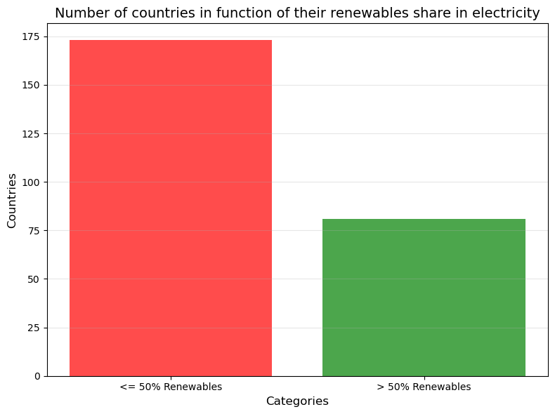

```python
# Filtrate and count countries with more or less than 50 in concerned column
below_50 = energy_data[(energy_data['renewables_share_elec'] <= 50) & (energy_data['iso_code'].notna())]
above_50 = energy_data[(energy_data['renewables_share_elec'] > 50) & (energy_data['iso_code'].notna())]
count_below_50 = below_50['country'].nunique()
count_above_50 = above_50['country'].nunique()
categories = ['<= 50% Renewables', '> 50% Renewables']
counts = [count_below_50, count_above_50]

# Create barplot
plt.figure(figsize=(8, 6))
plt.bar(categories, counts, alpha=0.7, color=['red', 'green'])
plt.title("Number of countries in function of their renewables share in electricity", fontsize=14)
plt.ylabel("Countries", fontsize=12)
plt.xlabel("Categories", fontsize=12)
plt.grid(axis='y', alpha=0.3)
plt.tight_layout()
plt.show()
```

If we want to predict ability of a country to get more than 50% renewable share in electricity, let's use data-driven methods to identify the feature which are most likely to help us predict this. Let's start with a correlation analysis.

```python
# Compute correlations with the target
energy_data['renewables_binary'] = (energy_data['renewables_share_elec'] > 50).astype(int)
numeric_data = energy_data.select_dtypes(include=[np.number])
correlation_matrix = numeric_data.corr()
target_correlation = correlation_matrix['renewables_binary'].sort_values(ascending=False)
print("Features most correlated with renewables_binary:")
print(target_correlation.head(20))
```

```
Features most correlated with renewables_binary:
renewables_binary                    1.000000
renewables_share_elec                0.886743
hydro_share_elec                     0.855193
low_carbon_share_elec                0.792858
low_carbon_electricity_percentage    0.792858
renewables_share_energy              0.720470
renewable_energy_percentage          0.712322
hydro_share_energy                   0.690501
low_carbon_share_energy              0.604070
biofuel_share_energy                 0.442817
renewables_energy_per_capita         0.434306
hydro_energy_per_capita              0.432073
low_carbon_energy_per_capita         0.417357
biofuel_cons_per_capita              0.326610
hydro_elec_per_capita                0.300145
renewables_elec_per_capita           0.298358
year                                 0.283889
low_carbon_elec_per_capita           0.277261
other_renewables_share_energy        0.274392
other_renewables_share_elec          0.239315
Name: renewables_binary, dtype: float64
```

Then, as we've done before, we can get take a look at the features importance using a random forest.

```python
y = (energy_data['renewables_share_elec'] > 50).astype(int)  # Binary target: > 50% renewables
X = energy_data.drop(columns=['renewables_share_elec', 'iso_code', 'country']).dropna()

# Ensure X and y are aligned after dropping NaN
y = y.loc[X.index]

X_train, X_test, y_train, y_test = train_test_split(X, y, test_size=0.3, random_state=42)
rf_model = RandomForestClassifier(random_state=42)
rf_model.fit(X_train, y_train)

# Get feature importances
feature_importances = pd.DataFrame({
    'Feature': X.columns,
    'Importance': rf_model.feature_importances_
}).sort_values(by='Importance', ascending=False)

# Display the top 30 features
print("Top Features by Random Forest (Classification):")
print(feature_importances.head(30))
```

```
Top Features by Random Forest (Classification):
                          Feature  Importance
109       renewables_share_energy    0.085269
54              hydro_consumption    0.077342
128             renewables_binary    0.067930
56              hydro_electricity    0.062336
58               hydro_share_elec    0.059013
59             hydro_share_energy    0.058232
55          hydro_elec_per_capita    0.051759
127   renewable_energy_percentage    0.044102
37              fossil_share_elec    0.042693
101        per_capita_electricity    0.038429
44          gas_energy_per_capita    0.036953
57        hydro_energy_per_capita    0.035141
108  renewables_energy_per_capita    0.032692
```

[output cut: 17 more lines]

We can also use RFE, which is a good option for feature selection, helping identifying the most important features in a dataset by recursively removing less important features.

```python
model = LogisticRegression(max_iter=1000, random_state=42)

# Perform RFE to select the top 5 most decisive features in the prediction of renewables share in electricity
rfe = RFE(model, n_features_to_select=5)
rfe.fit(X, y)
selected_features = X.columns[rfe.support_]
print("Selected Features by RFE:", selected_features)
```

```
Selected Features by RFE: Index(['coal_cons_per_capita', 'energy_per_capita', 'hydro_energy_per_capita',
       'low_carbon_energy_per_capita', 'renewables_energy_per_capita'],
      dtype='object')
```

Using the 3 previously used methods to select features, we will build our prediction dataset from data_energy using the features that appear the most in these 3 methods :

```python
features = ['population', 'gdp', 'electricity_generation', 'fossil_fuel_consumption', 'hydro_share_elec', 'low_carbon_electricity_percentage', 'renewables_share_energy', 'renewable_energy_percentage', 'hydro_share_energy',
            'low_carbon_share_energy', 'biofuel_share_energy', 'renewables_energy_per_capita', 'hydro_energy_per_capita', 'low_carbon_energy_per_capita', 'biofuel_cons_per_capita', 'hydro_elec_per_capita', 'renewables_elec_per_capita',
            'year', 'low_carbon_elec_per_capita', 'other_renewables_share_energy', 'other_renewables_share_elec', 'hydro_consumption', 'hydro_electricity', 'per_capita_electricity', 'gas_energy_per_capita']
X = energy_data[features]
y = energy_data['renewables_binary']
X=X.dropna()
y=y.loc[X.index]

X_train, X_test, y_train, y_test = train_test_split(X, y, test_size=0.3, random_state=42)

# Train a Logistic Regression model
logistic_model = LogisticRegression(class_weight='balanced', max_iter=1000, random_state=42)
logistic_model.fit(X_train, y_train)

# Train a Random Forest model as well to compare the results
rf_model = RandomForestClassifier(class_weight='balanced', random_state=42)
rf_model.fit(X_train, y_train)

# Make predictions
y_pred_logistic = logistic_model.predict(X_test)
y_pred_rf = rf_model.predict(X_test)

# Now we evaluate the models !
print("Logistic Regression Results:")
print(f"Accuracy: {accuracy_score(y_test, y_pred_logistic):.4f}")
print("\nClassification Report:\n", classification_report(y_test, y_pred_logistic))
print("Random Forest Results:")
print(f"Accuracy: {accuracy_score(y_test, y_pred_rf):.4f}")
print("\nClassification Report:\n", classification_report(y_test, y_pred_rf))
```

```
Logistic Regression Results:
Accuracy: 0.7970

Classification Report:
               precision    recall  f1-score   support

           0       0.80      1.00      0.89       318
           1       0.00      0.00      0.00        81

    accuracy                           0.80       399
   macro avg       0.40      0.50      0.44       399
weighted avg       0.64      0.80      0.71       399

Random Forest Results:
Accuracy: 0.9900

Classification Report:
               precision    recall  f1-score   support

           0       1.00      0.99      0.99       318
           1       0.96      0.99      0.98        81

    accuracy                           0.99       399
   macro avg       0.98      0.99      0.98       399
weighted avg       0.99      0.99      0.99       399
```

```python
smote = SMOTE(random_state=7)
X_train_balanced, y_train_balanced = smote.fit_resample(X_train, y_train)

# Train Logistic Regression and Random Forest over again on the balanced data to compare with what we got previously.
logistic_model = LogisticRegression(class_weight='balanced', max_iter=1000, random_state=42)
logistic_model.fit(X_train_balanced, y_train_balanced)

rf_model = RandomForestClassifier(class_weight='balanced', random_state=42)
rf_model.fit(X_train_balanced, y_train_balanced)

y_pred_logistic = logistic_model.predict(X_test)
y_pred_rf = rf_model.predict(X_test)

print("Logistic Regression Results with SMOTE:")
print(f"Accuracy: {accuracy_score(y_test, y_pred_logistic):.4f}")
print("\nClassification Report:\n\n", classification_report(y_test, y_pred_logistic))
print("Random Forest Results with SMOTE:")
print(f"Accuracy: {accuracy_score(y_test, y_pred_rf):.4f}")
print("\nClassification Report:\n", classification_report(y_test, y_pred_rf))
```

[output not shown]

```
Logistic Regression Results with SMOTE:
Accuracy: 0.7970

Classification Report:

               precision    recall  f1-score   support

           0       0.80      1.00      0.89       318
           1       0.00      0.00      0.00        81

    accuracy                           0.80       399
   macro avg       0.40      0.50      0.44       399
weighted avg       0.64      0.80      0.71       399

Random Forest Results with SMOTE:
Accuracy: 0.9925

Classification Report:
               precision    recall  f1-score   support

           0       1.00      0.99      1.00       318
           1       0.96      1.00      0.98        81

    accuracy                           0.99       399
   macro avg       0.98      1.00      0.99       399
weighted avg       0.99      0.99      0.99       399
```

Even with SMOTE, the Logistic Regression gives bad results. Let's try something more advanced and adjust the threshold : The Logistic Regression results are still insufficient while the data balanced with SMOTE. Although Random Forest accuracy is satisfying, we can try something a bit more advanced to see if the Logistic Regression performs better, for example adjusting its threshold :

```python
y_pred_probs = logistic_model.predict_proba(X_test)[:, 1]

# Adjust the threshold to 0.4
threshold = 0.4
y_pred_adjusted = (y_pred_probs >= threshold).astype(int)
print("Logistic Regression Results with Adjusted Threshold:")
print(f"Accuracy: {accuracy_score(y_test, y_pred_adjusted):.4f}")
print("\nClassification Report:\n", classification_report(y_test, y_pred_adjusted))
```

```
Logistic Regression Results with Adjusted Threshold:
Accuracy: 0.3333

Classification Report:
               precision    recall  f1-score   support

           0       0.93      0.18      0.30       318
           1       0.23      0.95      0.37        81

    accuracy                           0.33       399
   macro avg       0.58      0.56      0.33       399
weighted avg       0.79      0.33      0.31       399
```

This is still not satisfying. We will try also Gradient Boosting, and then, we will try to implement an Ensemble learnnig method based on the other methods. Now, the model is able to predict correctly a few instances of the class 1 (23%). This is still not enough, but these results might be interesting to implement in an ensemble learning system, because these may be different (and be good predictions) from the few errors in Random Forest predictions. Let's also try to make predictions with Gradient Boosting, and then we'll use other Ensemble learning methods.

```python
xgb_model = XGBClassifier(scale_pos_weight=len(y_train_balanced[y_train_balanced == 0]) / len(y_train_balanced[y_train_balanced == 1]),
                           random_state=42)
xgb_model.fit(X_train_balanced, y_train_balanced)

# Predictions and evaluation
y_pred_xgb = xgb_model.predict(X_test)
print("XGBoost Results:")
print(f"Accuracy: {accuracy_score(y_test, y_pred_xgb):.4f}")
print("\nClassification Report:\n", classification_report(y_test, y_pred_xgb))
```

```
XGBoost Results:
Accuracy: 0.9875

Classification Report:
               precision    recall  f1-score   support

           0       0.99      0.99      0.99       318
           1       0.96      0.98      0.97        81

    accuracy                           0.99       399
   macro avg       0.98      0.98      0.98       399
weighted avg       0.99      0.99      0.99       399
```

Global accuracy is slightly worse than for the Random Forest model, although not much different. Now, let's use Ensemble learning methods to see if we can enhance the Random Forest model results. We'll start with a simple one, the Voting Classifier with soft voting, based upon probability-based aggregation :

```python
xgb = XGBClassifier(n_estimators=100, learning_rate=0.1, random_state=42)
xgb.fit(X_train, y_train)
# Create a voting classifier
voting_model = VotingClassifier(estimators=[
    ('lr', logistic_model),
    ('rf', rf_model),
    ('xgb', xgb_model)
], voting='soft')

voting_model.fit(X_train_balanced, y_train_balanced)

y_pred_voting = voting_model.predict(X_test)

print("Voting Classifier Results (Logistic Regression, Random Forest, Gradient Boosting):")
print(f"Accuracy: {accuracy_score(y_test, y_pred_voting):.4f}")
print("\nClassification Report:\n", classification_report(y_test, y_pred_voting))
```

```
Voting Classifier Results (Logistic Regression, Random Forest, Gradient Boosting):
Accuracy: 0.9950

Classification Report:
               precision    recall  f1-score   support

           0       1.00      0.99      1.00       318
           1       0.98      1.00      0.99        81

    accuracy                           0.99       399
   macro avg       0.99      1.00      0.99       399
weighted avg       1.00      0.99      1.00       399
```

The results are outstanding, better than with Random Forest alone ! This means that the voting method allows the three prediction models to work better together. We can try other Ensemble Learning methods to see if they work any better. Let's start with the hard-voting method, based upon majority-based aggregation.

```python
voting_model_hard = VotingClassifier(estimators=[
    ('lr', logistic_model),
    ('rf', rf_model),
    ('xgb', xgb_model)
], voting='hard')

voting_model_hard.fit(X_train_balanced, y_train_balanced)

y_pred_voting_hard = voting_model_hard.predict(X_test)

print("Hard Voting Classifier Results (Logistic Regression, Random Forest, Gradient Boosting):")
print(f"Accuracy: {accuracy_score(y_test, y_pred_voting_hard):.4f}")
print("\nClassification Report:\n", classification_report(y_test, y_pred_voting_hard))
```

```
Hard Voting Classifier Results (Logistic Regression, Random Forest, Gradient Boosting):
Accuracy: 0.9925

Classification Report:
               precision    recall  f1-score   support

           0       0.99      1.00      1.00       318
           1       0.99      0.98      0.98        81

    accuracy                           0.99       399
   macro avg       0.99      0.99      0.99       399
weighted avg       0.99      0.99      0.99       399
```

Now we're alright, For the next part let's use other ensemble learning techniques We can say we can predict a country's ability to more than 50% renewables share in energy quite well : using this ensemble voting technique, we can predict this right in 99.25% of cases. Let's take a look at the few errors and shortly trying to answer to why these mistakes appear :

```python
# Assuming the original dataset `energy_data` contains 'country' and 'renewables_share_elec' columns

results_df = pd.DataFrame({
    'True Label': y_test.values,
    'Predicted Label': y_pred_voting_hard
}, index=X_test.index)

# Add country names and renewables share in electricity to the test set by joining with the original dataset
X_test_with_details = X_test.copy()
X_test_with_details['country'] = energy_data.loc[X_test.index, 'country']
X_test_with_details['renewables_share_elec'] = energy_data.loc[X_test.index, 'renewables_share_elec']

# Create a DataFrame that includes the full feature set, country names, renewables share, predictions, and true labels
full_results_df = pd.concat([X_test_with_details.reset_index(drop=True), results_df.reset_index(drop=True)], axis=1)

# Identify wrong and right predictions
wrong_predictions_full = full_results_df[full_results_df['True Label'] != full_results_df['Predicted Label']]
correct_predictions_full = full_results_df[full_results_df['True Label'] == full_results_df['Predicted Label']].sample(n=min(5, len(full_results_df)))

# Display these
print("\n--- Wrong Predictions (Full Details with Country and Renewables Share) ---")
display(wrong_predictions_full[['country', 'renewables_share_elec'] + list(X_test.columns) + ['True Label', 'Predicted Label']].head(5))
print("\n--- Correct Predictions (Full Details with Country and Renewables Share) ---")
display(correct_predictions_full[['country', 'renewables_share_elec'] + list(X_test.columns) + ['True Label', 'Predicted Label']])
```

```
--- Wrong Predictions (Full Details with Country and Renewables Share) ---
```

|  | country | renewables_share_elec | population | gdp | electricity_generation | fossil_fuel_consumption | hydro_share_elec | low_carbon_electricity_percentage | renewables_share_energy | renewable_energy_percentage | ... | year | low_carbon_elec_per_capita | other_renewables_share_energy | other_renewables_share_elec | hydro_consumption | hydro_electricity | per_capita_electricity | gas_energy_per_capita | True Label | Predicted Label |
| --- | --- | --- | --- | --- | --- | --- | --- | --- | --- | --- | --- | --- | --- | --- | --- | --- | --- | --- | --- | --- | --- |
| 169 | Sweden | 52.029 | 9164274.0 | 3.878852e+11 | 148.82 | 243.037 | 44.456 | 97.029969 | 34.601 | 48.042928 | ... | 2007 | 15756.839 | 4.834 | 6.612 | 187.103 | 66.16 | 16239.147 | 1034.779 | 1 | 0 |
| 220 | Sweden | 49.595 | 9104724.0 | 3.722380e+11 | 143.28 | 250.074 | 43.076 | 96.342825 | 32.325 | 45.264001 | ... | 2006 | 15161.360 | 4.171 | 5.835 | 175.321 | 61.72 | 15736.886 | 1009.229 | 0 | 1 |
| 282 | Sweden | 51.291 | 9051739.0 | 3.544987e+11 | 158.37 | 244.637 | 45.968 | 96.994380 | 34.650 | 49.060489 | ... | 2005 | 16970.219 | 3.516 | 4.729 | 207.321 | 72.80 | 17496.084 | 969.675 | 1 | 0 |

3 rows × 29 columns

```
--- Correct Predictions (Full Details with Country and Renewables Share) ---
```

|  | country | renewables_share_elec | population | gdp | electricity_generation | fossil_fuel_consumption | hydro_share_elec | low_carbon_electricity_percentage | renewables_share_energy | renewable_energy_percentage | ... | year | low_carbon_elec_per_capita | other_renewables_share_energy | other_renewables_share_elec | hydro_consumption | hydro_electricity | per_capita_electricity | gas_energy_per_capita | True Label | Predicted Label |
| --- | --- | --- | --- | --- | --- | --- | --- | --- | --- | --- | --- | --- | --- | --- | --- | --- | --- | --- | --- | --- | --- |
| 275 | Canada | 64.092 | 34323536.0 | 1.455580e+12 | 611.54 | 2532.390 | 60.825 | 78.529614 | 28.648 | 30.580577 | ... | 2011 | 13991.564 | 0.837 | 1.524 | 1036.492 | 371.97 | 17816.930 | 29294.998 | 1 | 1 |
| 87 | Belgium | 1.268 | 10264351.0 | 3.457368e+11 | 82.79 | 603.482 | 0.556 | 59.439546 | 0.433 | 0.530902 | ... | 2000 | 4794.263 | 0.244 | 0.688 | 1.360 | 0.46 | 8065.780 | 15126.406 | 0 | 0 |
| 313 | Romania | 37.983 | 19698852.0 | 3.698278e+11 | 63.95 | 291.520 | 22.658 | 55.981235 | 17.503 | 18.933274 | ... | 2017 | 1817.365 | 0.431 | 0.829 | 38.573 | 14.49 | 3246.382 | 5731.435 | 0 | 0 |
| 314 | Spain | 13.826 | 41477652.0 | 1.206113e+12 | 239.91 | 1334.461 | 8.845 | 40.094202 | 6.446 | 7.237172 | ... | 2002 | 2319.080 | 0.511 | 1.080 | 66.900 | 21.22 | 5784.079 | 5256.670 | 0 | 0 |
| 221 | Italy | 27.677 | 60025952.0 | 2.088117e+12 | 299.74 | 1749.311 | 15.287 | 27.677320 | 12.443 | 12.443041 | ... | 2011 | 1382.069 | 2.480 | 5.498 | 126.410 | 45.82 | 4993.507 | 12363.996 | 0 | 0 |

5 rows × 29 columns

We have only 3 errors here, and they are very close to the 50% threshold. We can say the model performs very well.

For the project's purposes, we can also display different Ensemble Learning methods. For these, we will work on much more disequilibrated data, trying to predict something similar to what we've done before ; this time, we will predict the ability of countries to get more than 90% low-carbon electricity.

### Predicting the ability of countries to get more than 90% low-carbon electricity

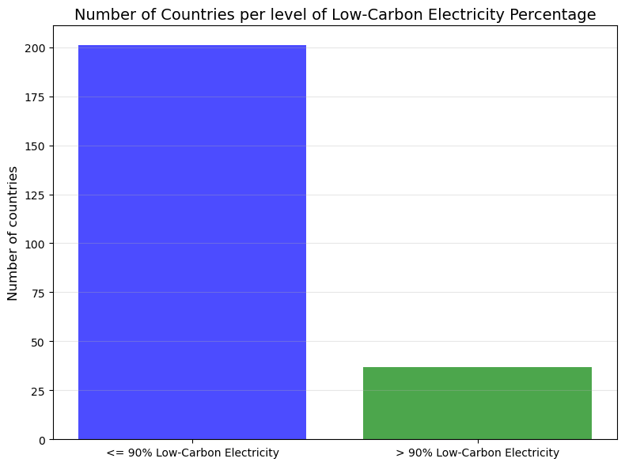

```python
# Filtrate the countries with more or less than 90% en 'low_carbon_electricity_percentage'
below_90 = energy_data[(energy_data['low_carbon_electricity_percentage'] <= 90) & (energy_data['iso_code'].notna())]
above_90 = energy_data[(energy_data['low_carbon_electricity_percentage'] > 90) & (energy_data['iso_code'].notna())]

# Count and show the number of countries for each category
count_below_90 = below_90['country'].nunique()
count_above_90 = above_90['country'].nunique()
categories = ['<= 90% Low-Carbon Electricity', '> 90% Low-Carbon Electricity']
counts = [count_below_90, count_above_90]
plt.figure(figsize=(8, 6))
plt.bar(categories, counts, alpha=0.7, color=['blue', 'green'])
plt.title("Number of Countries per level of Low-Carbon Electricity Percentage", fontsize=14)
plt.ylabel("Number of countries", fontsize=12)
plt.grid(axis='y', alpha=0.3)
plt.tight_layout()
plt.show()
```

```python
energy_data['above_90_low_carbon'] = (energy_data['low_carbon_electricity_percentage'] > 90).astype(int)
display(energy_data[['country', 'low_carbon_electricity_percentage', 'above_90_low_carbon']].head(10))
```

|  | country | low_carbon_electricity_percentage | above_90_low_carbon |
| --- | --- | --- | --- |
| 0 | ASEAN (Ember) | 19.774854 | 0 |
| 1 | ASEAN (Ember) | 19.305622 | 0 |
| 2 | ASEAN (Ember) | 17.972187 | 0 |
| 3 | ASEAN (Ember) | 16.931678 | 0 |
| 4 | ASEAN (Ember) | 15.882377 | 0 |
| 5 | ASEAN (Ember) | 15.316832 | 0 |
| 6 | ASEAN (Ember) | 15.957506 | 0 |
| 7 | ASEAN (Ember) | 15.934115 | 0 |
| 8 | ASEAN (Ember) | 16.708462 | 0 |
| 9 | ASEAN (Ember) | 16.906916 | 0 |

This dataset is much more disequilibrated. We can try to make predictions upon it to take a look, but we will probably have to balance the data. Here are the results for the predictions made on the unbalanced data :

```python
# We use the same features defined previously as linked to the low-carbon electricity percentage
features = ['year', 'primary_energy_consumption', 'greenhouse_gas_emissions', 'fossil_fuel_consumption', 'gdp',
            'low_carbon_consumption', 'oil_consumption', 'renewables_consumption', 'gas_consumption', 'gas_production',
            'coal_production', 'coal_consumption', 'oil_production', 'population', 'biofuel_consumption']
X = energy_data[features]
y = energy_data['above_90_low_carbon']
X = X.dropna()
y = y.loc[X.index]

# Split the data
X_train, X_test, y_train, y_test = train_test_split(X, y, test_size=0.3, random_state=42)

# Logistic Regression
logistic_model = LogisticRegression(max_iter=1000, random_state=42)
logistic_model.fit(X_train, y_train)
y_pred_logistic = logistic_model.predict(X_test)
print("Logistic Regression Results:")
print(f"Accuracy: {accuracy_score(y_test, y_pred_logistic):.4f}")
print("\nClassification Report:\n", classification_report(y_test, y_pred_logistic))

# Random Forest
rf_model = RandomForestClassifier(random_state=42)
rf_model.fit(X_train, y_train)
y_pred_rf = rf_model.predict(X_test)
print("Random Forest Results:")
print(f"Accuracy: {accuracy_score(y_test, y_pred_rf):.4f}")
print("\nClassification Report:\n", classification_report(y_test, y_pred_rf))

# Gradient Boosting
gb_model = GradientBoostingClassifier(random_state=42)
gb_model.fit(X_train, y_train)
y_pred_gb = gb_model.predict(X_test)
print("Gradient Boosting Results:")
print(f"Accuracy: {accuracy_score(y_test, y_pred_gb):.4f}")
print("\nClassification Report:\n", classification_report(y_test, y_pred_gb))
```

```
Logistic Regression Results:
Accuracy: 0.9472

Classification Report:
               precision    recall  f1-score   support

           0       0.95      1.00      0.97       251
           1       0.00      0.00      0.00        14

    accuracy                           0.95       265
   macro avg       0.47      0.50      0.49       265
weighted avg       0.90      0.95      0.92       265

Random Forest Results:
Accuracy: 0.9811

Classification Report:
               precision    recall  f1-score   support

           0       1.00      0.98      0.99       251
           1       0.74      1.00      0.85        14

    accuracy                           0.98       265
   macro avg       0.87      0.99      0.92       265
weighted avg       0.99      0.98      0.98       265

Gradient Boosting Results:
Accuracy: 0.9811

Classification Report:
               precision    recall  f1-score   support

           0       1.00      0.98      0.99       251
           1       0.76      0.93      0.84        14

    accuracy                           0.98       265
   macro avg       0.88      0.96      0.91       265
weighted avg       0.98      0.98      0.98       265
```

As expected, since the data is highly unbalanced, the results are not very good, especially on the Logistic Regression model. Let's take a look at how the models perform with balanced data. We'll start with SMOTE.

```python
smote = SMOTE(random_state=42)
X_train_balanced, y_train_balanced = smote.fit_resample(X_train, y_train)

# Logistic Regression
logistic_model = LogisticRegression(max_iter=1000, random_state=42)
logistic_model.fit(X_train_balanced, y_train_balanced)
y_pred_logistic = logistic_model.predict(X_test)
print("Logistic Regression Results with SMOTE:")
print(f"Accuracy: {accuracy_score(y_test, y_pred_logistic):.4f}")
print("\nClassification Report:\n", classification_report(y_test, y_pred_logistic))

# Random Forest
rf_model = RandomForestClassifier(random_state=42)
rf_model.fit(X_train_balanced, y_train_balanced)
y_pred_rf = rf_model.predict(X_test)
print("Random Forest Results with SMOTE:")
print(f"Accuracy: {accuracy_score(y_test, y_pred_rf):.4f}")
print("\nClassification Report:\n", classification_report(y_test, y_pred_rf))

# Gradient Boosting
gb_model = GradientBoostingClassifier(random_state=42)
gb_model.fit(X_train_balanced, y_train_balanced)
y_pred_gb = gb_model.predict(X_test)
print("Gradient Boosting Results with SMOTE:")
print(f"Accuracy: {accuracy_score(y_test, y_pred_gb):.4f}")
print("\nClassification Report:\n", classification_report(y_test, y_pred_gb))
```

```
Logistic Regression Results with SMOTE:
Accuracy: 0.8113

Classification Report:
               precision    recall  f1-score   support

           0       0.97      0.83      0.89       251
           1       0.14      0.50      0.22        14

    accuracy                           0.81       265
   macro avg       0.55      0.66      0.56       265
weighted avg       0.92      0.81      0.86       265

Random Forest Results with SMOTE:
Accuracy: 0.9774

Classification Report:
               precision    recall  f1-score   support

           0       1.00      0.98      0.99       251
           1       0.72      0.93      0.81        14

    accuracy                           0.98       265
   macro avg       0.86      0.95      0.90       265
weighted avg       0.98      0.98      0.98       265

Gradient Boosting Results with SMOTE:
Accuracy: 0.9774

Classification Report:
               precision    recall  f1-score   support

           0       1.00      0.98      0.99       251
           1       0.72      0.93      0.81        14

    accuracy                           0.98       265
   macro avg       0.86      0.95      0.90       265
weighted avg       0.98      0.98      0.98       265
```

The results are slightly worse for both Random Forest and Gradient Boosting for events 0 and 1. Meanwhile, they are better for the Logistic Regression. A Logistic Regression model trained on balanced data can then be useful in an Ensemble Learning method. Although these results are more interesting than the ones we got with non-balanced data, we can try to enhance them with other data balancing methods. To try them faster, we can make a for loop and try all balancing methods that we can find, and compare the results then.

```python
# Define balancing methods
balancing_methods = {
    "Random UnderSampler": RandomUnderSampler(random_state=42),
    "SMOTE": SMOTE(random_state=42),
    "Borderline-SMOTE": BorderlineSMOTE(random_state=42),
    "NearMiss": NearMiss(version=1),
    "SMOTEENN": SMOTEENN(random_state=42),
    "SMOTETomek": SMOTETomek(random_state=42),
    "Class Weights (Balanced)": "balanced",
    "Balanced Random Forest": BalancedRandomForestClassifier(random_state=42),
    "Easy Ensemble": EasyEnsembleClassifier(random_state=42),
    "ADASYN": ADASYN(random_state=42),
}

# Define models
models = {
    "Logistic Regression": LogisticRegression(max_iter=1000, random_state=42),
    "Random Forest": RandomForestClassifier(random_state=42),
    "Gradient Boosting": GradientBoostingClassifier(random_state=42)
}

# Iterate through balancing methods
for method_name, method in balancing_methods.items():
    print(f"\n=== Balancing Method: {method_name} ===")
    try:
        if method_name in ["Balanced Random Forest", "Easy Ensemble"]:
            # For ensemble methods, directly use the method as a model
            method.fit(X_train, y_train)
            y_pred = method.predict(X_test)
            print(f"\nAccuracy: {accuracy_score(y_test, y_pred):.4f}")
            print("Classification Report:")
            print(classification_report(y_test, y_pred))
        elif method_name == "Class Weights (Balanced)":
            # Apply class weights directly in the models
            for model_name, model in models.items():
                if isinstance(model, (LogisticRegression, RandomForestClassifier)):
                    model.set_params(class_weight="balanced")
                model.fit(X_train, y_train)
                y_pred = model.predict(X_test)
                print(f"\nModel: {model_name}")
                print(f"Accuracy: {accuracy_score(y_test, y_pred):.4f}")
                print("Classification Report:")
                print(classification_report(y_test, y_pred))
        else:
            # Balance the training data for other methods
            X_train_balanced, y_train_balanced = method.fit_resample(X_train, y_train)
            for model_name, model in models.items():
                model.fit(X_train_balanced, y_train_balanced)
                y_pred = model.predict(X_test)
                print(f"\nModel: {model_name}")
                print(f"Accuracy: {accuracy_score(y_test, y_pred):.4f}")
                print("Classification Report:")
                print(classification_report(y_test, y_pred))
    except Exception as e:
        print(f"Error with method {method_name}: {e}")
```

```
=== Balancing Method: Random UnderSampler ===

Model: Logistic Regression
Accuracy: 0.6868
Classification Report:
              precision    recall  f1-score   support

           0       0.97      0.69      0.81       251
           1       0.10      0.64      0.18        14

    accuracy                           0.69       265
   macro avg       0.54      0.67      0.49       265
weighted avg       0.93      0.69      0.77       265


Model: Random Forest
Accuracy: 0.9585
Classification Report:
              precision    recall  f1-score   support

           0       1.00      0.96      0.98       251
           1       0.56      1.00      0.72        14

    accuracy                           0.96       265
   macro avg       0.78      0.98      0.85       265
weighted avg       0.98      0.96      0.96       265


Model: Gradient Boosting
Accuracy: 0.9472
Classification Report:
              precision    recall  f1-score   support

           0       1.00      0.95      0.97       251
           1       0.50      0.93      0.65        14

    accuracy                           0.95       265
   macro avg       0.75      0.94      0.81       265
weighted avg       0.97      0.95      0.95       265

```

[output cut: 299 more lines]

```
   macro avg       0.85      0.92      0.88       265
weighted avg       0.98      0.97      0.97       265


Model: Gradient Boosting
Accuracy: 0.9774
Classification Report:
              precision    recall  f1-score   support

           0       1.00      0.98      0.99       251
           1       0.72      0.93      0.81        14

    accuracy                           0.98       265
   macro avg       0.86      0.95      0.90       265
weighted avg       0.98      0.98      0.98       265
```

Here, most methods don't work better than Gradient Boosting without SMOTE. The only balancing method giving better results is SMOTEENN, with a Logistic Regression model. The SMOTEENN method combines two techniques (SMOTE and ENN) to address class imbalance effectively. First, SMOTE generates synthetic samples for the minority class by interpolating between existing samples an their nearest neighbors, enhancing the representation of the minority class. Then, Edited Nearest Neighbors (ENN) cleans the dataset by removing samples from both classes that are misclassified by their k-nearest neighbors, reducing noise and overlap between classes. This combined approach balances the dataset while improving the decision boundaries for classification. SMOTEENN works particularly well here because as it removes samples near class boundaries (the ones prone to misclassification), it improves the separation between classes. This is particularly useful in contexts with overlapping features such as energy production and consumption, which may have ambiguous class boundaries. Energy-related data often exhibit non-linear relationships and noisy distributions due to differences between countries (e.g., industrialization, policies). SMOTEENN enhances the decision boundaries by balanacing the dataset while filtering out noisy examples, which ensures the model learns robust patterns instead of overfitting to noise. This is also why it works better with Logistic Regression when Logistic Regression is worse with most of other balancing methods. Logistic Regression works better when we have linear decision boundaries, which makes it work better when the oversampling step creates synthetic samples along linear interpolations between minority class points. These samples reinforce the linear reationship.

We can still enhance these results, adjusting the parameters of SMOTEENN. This time we'll use a grid search to look for the best hyperparameters.

```python
# This time we'll use a Pipeline, a very used tool in Machine Learning.
pipeline = Pipeline([
    ('smoteenn', SMOTEENN(
        smote=SMOTE(sampling_strategy=0.75, k_neighbors=5, random_state=42),
        enn=EditedNearestNeighbours(n_neighbors=5, sampling_strategy='majority')
    )),
    ('classifier', LogisticRegression(max_iter=1000, random_state=42))
])

# Define parameter grid for optimization
param_grid = {
    'smoteenn__smote__k_neighbors': [3, 5, 7],
    'smoteenn__enn__n_neighbors': [3, 5, 7],
    'classifier__C': [0.1, 1, 10],
    'classifier__solver': ['lbfgs', 'liblinear'] }

# Perform grid search and show found parameters
grid_search = GridSearchCV(pipeline, param_grid, scoring='f1', cv=3, n_jobs=-1)
grid_search.fit(X_train, y_train)
print("Best Parameters:", grid_search.best_params_)

# Evaluate and show the best parameters performance
best_model = grid_search.best_estimator_
y_pred = best_model.predict(X_test)
print("\nAccuracy:", accuracy_score(y_test, y_pred))
print("\nClassification Report:\n", classification_report(y_test, y_pred))
```

```
Best Parameters: {'classifier__C': 0.1, 'classifier__solver': 'lbfgs', 'smoteenn__enn__n_neighbors': 5, 'smoteenn__smote__k_neighbors': 7}

Accuracy: 0.9660377358490566

Classification Report:
               precision    recall  f1-score   support

           0       0.97      1.00      0.98       251
           1       0.86      0.43      0.57        14

    accuracy                           0.97       265
   macro avg       0.91      0.71      0.78       265
weighted avg       0.96      0.97      0.96       265
```

Here, we have a slightly worse global accuracy. This classification report is still better, as it has higher accuracy on the minority class 1.

### Are Ensemble Learning methods better than using Logistic Regression on SMOTEENN-balanced data ?

Logistic Regression on SMOTEENN-balanced data gives good results, with .97 accuracy on the 0 event and .86 on the 1 event. Other methods have given acceptable results, it might be a good idea to combine them in Ensemble Learning. Moreover, some Ensemble Learning methods perform very well on inbalanced datasets. Let's implement these and then take a look at the results.

```python
# We'll start with 2 methods we haven't used yet :
ensemble_methods = {
    "Balanced Random Forest": BalancedRandomForestClassifier(random_state=42, sampling_strategy="all", replacement=True, bootstrap=False),
    "Easy Ensemble": EasyEnsembleClassifier(random_state=42)
}

# Evaluate each ensemble method, using once again a for loop :
for method_name, model in ensemble_methods.items():
    print(f"\n=== Ensemble Method: {method_name} ===")
    try:
        model.fit(X_train, y_train)
        y_pred = model.predict(X_test)
        print(f"Accuracy: {accuracy_score(y_test, y_pred):.4f}")
        print("Classification Report:")
        print(classification_report(y_test, y_pred))
    except Exception as e:
        print(f"Error with ensemble method {method_name}: {e}")
```

```
=== Ensemble Method: Balanced Random Forest ===
Accuracy: 0.9774
Classification Report:
              precision    recall  f1-score   support

           0       1.00      0.98      0.99       251
           1       0.70      1.00      0.82        14

    accuracy                           0.98       265
   macro avg       0.85      0.99      0.91       265
weighted avg       0.98      0.98      0.98       265


=== Ensemble Method: Easy Ensemble ===
Accuracy: 0.9698
Classification Report:
              precision    recall  f1-score   support

           0       1.00      0.97      0.98       251
           1       0.64      1.00      0.78        14

    accuracy                           0.97       265
   macro avg       0.82      0.98      0.88       265
weighted avg       0.98      0.97      0.97       265
```

```python
smoteenn = SMOTEENN(
    smote=SMOTE(sampling_strategy=0.75, k_neighbors=7, random_state=42),  # Best k_neighbors
    enn=EditedNearestNeighbours(n_neighbors=5, sampling_strategy='majority'))  # Best n_neighbors
X_train_smoteenn, y_train_smoteenn = smoteenn.fit_resample(X_train, y_train)

# Logistic Regression with best parameters
logistic_model = LogisticRegression(max_iter=1000, C=0.1, solver='lbfgs', random_state=42)  # Best parameters
logistic_model.fit(X_train_smoteenn, y_train_smoteenn)


# Combine Logistic Regression and Ensemble Models in a Voting Classifier
voting_ensemble = VotingClassifier(
    estimators=[
        ('logistic', logistic_model),
        ('balanced_rf', ensemble_methods["Balanced Random Forest"]),
        ('easy_ensemble', ensemble_methods["Easy Ensemble"])
    ],
    voting='soft')

# Train and evaluate the voting method
voting_ensemble.fit(X_train, y_train)
y_pred_voting = voting_ensemble.predict(X_test)
print("\n=== Combined Voting Classifier ===")
print(f"Accuracy: {accuracy_score(y_test, y_pred_voting):.4f}")
print("Classification Report:")
print(classification_report(y_test, y_pred_voting))
```

```
=== Combined Voting Classifier ===
Accuracy: 0.9736
Classification Report:
              precision    recall  f1-score   support

           0       0.99      0.98      0.99       251
           1       0.71      0.86      0.77        14

    accuracy                           0.97       265
   macro avg       0.85      0.92      0.88       265
weighted avg       0.98      0.97      0.97       265
```

```python
logistic_model = LogisticRegression(max_iter=1000, C=0.1, solver='lbfgs', random_state=42)
logistic_model.fit(X_train_smoteenn, y_train_smoteenn)

# Train Gradient Boosting Classifier on SMOTEENN-balanced data
gb_model = GradientBoostingClassifier(n_estimators=100, learning_rate=0.1, max_depth=3, random_state=42)
gb_model.fit(X_train_smoteenn, y_train_smoteenn)

# Combine models in a Voting Classifier
voting_ensemble = VotingClassifier(
    estimators=[
        ('logistic', logistic_model),
        ('gradient_boosting', gb_model)
    ],
    voting='soft')

voting_ensemble.fit(X_train_smoteenn, y_train_smoteenn)
y_pred_voting = voting_ensemble.predict(X_test)
print("\n=== Combined Soft Voting Classifier ===")
print(f"Accuracy: {accuracy_score(y_test, y_pred_voting):.4f}")
print("Classification Report:")
print(classification_report(y_test, y_pred_voting))
```

```
=== Combined Soft Voting Classifier ===
Accuracy: 0.9698
Classification Report:
              precision    recall  f1-score   support

           0       1.00      0.97      0.98       251
           1       0.65      0.93      0.76        14

    accuracy                           0.97       265
   macro avg       0.82      0.95      0.87       265
weighted avg       0.98      0.97      0.97       265
```

With soft-voting, results appear to be worse. Let's check out how hard-voting does :

```python
voting_ensemble = VotingClassifier(
    estimators=[
        ('logistic', logistic_model),
        ('gradient_boosting', gb_model)
    ],
    voting='hard')   # This time we'll use hard voting

voting_ensemble.fit(X_train_smoteenn, y_train_smoteenn)

# Evaluate the combined Voting Classifier
y_pred_voting = voting_ensemble.predict(X_test)
print("\n=== Combined Hard Voting Classifier ===")
print(f"Accuracy: {accuracy_score(y_test, y_pred_voting):.4f}")
print("Classification Report:")
print(classification_report(y_test, y_pred_voting))
```

```
=== Combined Hard Voting Classifier ===
Accuracy: 0.9660
Classification Report:
              precision    recall  f1-score   support

           0       0.97      1.00      0.98       251
           1       1.00      0.36      0.53        14

    accuracy                           0.97       265
   macro avg       0.98      0.68      0.75       265
weighted avg       0.97      0.97      0.96       265
```

### Hard-Voting method between logistic regression and gradient boosting on data balanced using SMOTEENN gives tremendous results ! There, we have a correct prediction 96.6% of the time : whern the model predicts the 1 one event, it's always right, and when it predicts 0 (the majority class, so the one we can afford to make errors with), it's right 97% of the time.

For the next stage of this project, we can try another strategy to predict whether or not a country has more than 90% low-carbon electricity percentage. Rather that making this a binary variable, we can try to predict directly the percentage using Deep Learning and compare the result.

## Stage 3 : More improvements, more and more

In this stage we're supposed to add more improvements, using algorithms outside of the course (even Deep Learning ones). We will remain on the same problematic but will use several models to see which ones perform better, testing these with techniques such as pipelines and hyperparameters grid search.

The models we use here are Deep Neural Networks using libraries such as Keras and PyTorch, Regression Neural Network, and LSTM. Reasons why we choose those models are explained in the joint document.

```python
# Let's start with getting back data, with low-carbon electricity percentage as Y.
features = ['population', 'gdp', 'electricity_generation', 'fossil_fuel_consumption', 'hydro_share_elec', 'renewables_share_energy', 'renewable_energy_percentage', 'hydro_share_energy',
            'low_carbon_share_energy', 'biofuel_share_energy', 'renewables_energy_per_capita', 'hydro_energy_per_capita', 'low_carbon_energy_per_capita', 'biofuel_cons_per_capita', 'hydro_elec_per_capita', 'renewables_elec_per_capita',
            'year', 'low_carbon_elec_per_capita', 'other_renewables_share_energy', 'other_renewables_share_elec', 'hydro_consumption', 'hydro_electricity', 'per_capita_electricity', 'gas_energy_per_capita']
X = energy_data[features]
y = energy_data['low_carbon_electricity_percentage']
X=X.dropna()
y=y.loc[X.index]

X_train, X_test, y_train, y_test = train_test_split(X, y, test_size=0.3, random_state=42)
```

We'll start with the most basic technique used in this part, Deep Neural Network. This technique is relevant when linear regression models' results can't progress anymore ; moreover, this method is more suitable for large-scale datasets such as our, at it captures better its complexity and shades. It also allows us to use regularization techniques unavailable in most regression techniques such as dropout to make the prediction model more robust. Optimizers and techniques like batch training also make this approach able to converge faster than trraditional gradient descent.

```python
scaler = StandardScaler()
X_train_scaled = scaler.fit_transform(X_train)
X_test_scaled = scaler.transform(X_test)

# Build the neural network
model = Sequential([
    Dense(64, activation='relu', input_shape=(X_train_scaled.shape[1],)),
    Dropout(0.2),
    Dense(32, activation='relu'),
    Dropout(0.2),
    Dense(16, activation='relu'),
    Dense(1, activation='linear')])

# Compile the modeel
model.compile(optimizer=Adam(learning_rate=0.001), loss='mse', metrics=['mae'])

# Train the model
history = model.fit(
    X_train_scaled, y_train,
    validation_split=0.2,
    epochs=100,
    batch_size=32,
    verbose=1)

# Now we evaluate the model
y_pred = model.predict(X_test_scaled).flatten()
print("\n=== Evaluation ===")
print(f"Mean Absolute Error (MAE): {mean_absolute_error(y_test, y_pred):.4f}")
print(f"Mean Squared Error (MSE): {mean_squared_error(y_test, y_pred):.4f}")
```

[output not shown]

[output cut: 50 more lines]

```
24/24 ━━━━━━━━━━━━━━━━━━━━ 0s 3ms/step - loss: 47.5257 - mae: 4.8964 - val_loss: 9.3001 - val_mae: 2.2677
24/24 ━━━━━━━━━━━━━━━━━━━━ 0s 3ms/step - loss: 50.0616 - mae: 5.1465 - val_loss: 10.2437 - val_mae: 2.3149
24/24 ━━━━━━━━━━━━━━━━━━━━ 0s 3ms/step - loss: 59.3326 - mae: 5.5040 - val_loss: 10.6146 - val_mae: 2.5138
24/24 ━━━━━━━━━━━━━━━━━━━━ 0s 3ms/step - loss: 47.7369 - mae: 5.0206 - val_loss: 11.8155 - val_mae: 2.6196
24/24 ━━━━━━━━━━━━━━━━━━━━ 0s 3ms/step - loss: 45.0961 - mae: 4.8079 - val_loss: 12.6873 - val_mae: 2.6805
24/24 ━━━━━━━━━━━━━━━━━━━━ 0s 3ms/step - loss: 46.5030 - mae: 4.7558 - val_loss: 9.7163 - val_mae: 2.3236
24/24 ━━━━━━━━━━━━━━━━━━━━ 0s 3ms/step - loss: 49.7728 - mae: 5.1581 - val_loss: 9.9394 - val_mae: 2.3576
24/24 ━━━━━━━━━━━━━━━━━━━━ 0s 3ms/step - loss: 49.5463 - mae: 4.9396 - val_loss: 15.1658 - val_mae: 2.9411
24/24 ━━━━━━━━━━━━━━━━━━━━ 0s 3ms/step - loss: 43.1501 - mae: 4.7016 - val_loss: 11.1104 - val_mae: 2.5594
24/24 ━━━━━━━━━━━━━━━━━━━━ 0s 3ms/step - loss: 48.3994 - mae: 4.8727 - val_loss: 13.7063 - val_mae: 2.6987
13/13 ━━━━━━━━━━━━━━━━━━━━ 0s 3ms/step

=== Evaluation ===
Mean Absolute Error (MAE): 2.7308
Mean Squared Error (MSE): 13.2926
```

Here, we use significantly more epochs than in the lesson ; we need it bcause we have significantly more data influencing our output. Having more epochs allows us to have more learning stabiliy and better capture complex relationships. We can see visually how useful it is by drawing a graph of the training and precision loss in function of the number of epochs :

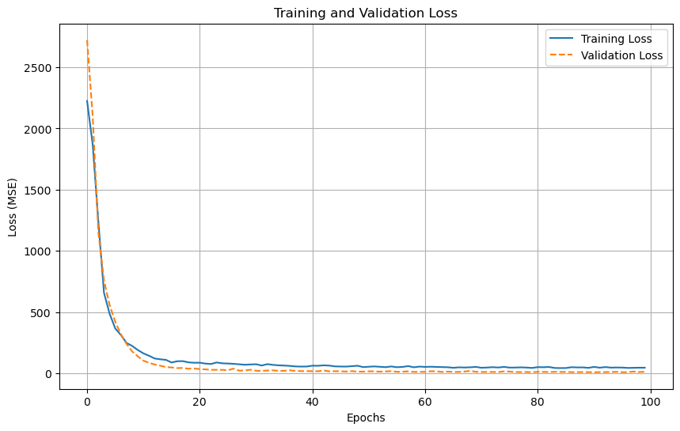

```python
plt.figure(figsize=(10, 6))
plt.plot(history.history['loss'], label='Training Loss')
plt.plot(history.history['val_loss'], label='Validation Loss', linestyle='--')
plt.title('Training and Validation Loss')
plt.xlabel('Epochs')
plt.ylabel('Loss (MSE)')
plt.legend()
plt.grid(True)
plt.show()
```

#### Here the validation and training loss converge together, meaning the model generalizes well to the test data.

Let's take a look at the predictions of the model !

```python
X_test_with_features = pd.DataFrame(X_test, columns=X.columns, index=X_test.index)

# Combine predictions with true  values and features data
predictions_df = pd.concat([
    X_test_with_features,
    pd.DataFrame({'True Value': y_test.values, 'Predicted Value': y_pred}, index=X_test.index)], axis=1)

# Calculate absolute errors and sort bu it
predictions_df['Absolute Error'] = abs(predictions_df['True Value'] - predictions_df['Predicted Value'])
# Sort by absolute error
best_predictions = predictions_df.sort_values(by='Absolute Error').head(5)
worst_predictions = predictions_df.sort_values(by='Absolute Error', ascending=False).head(5)

print("\n\t\t\t\t\t\t\t=== 5 Best Predictions ===")
display(best_predictions)

print("\n\t\t\t\t\t\t\t=== 5 Worst Predictions ===")
display(worst_predictions)
```

```
							=== 5 Best Predictions ===
```

|  | population | gdp | electricity_generation | fossil_fuel_consumption | hydro_share_elec | renewables_share_energy | renewable_energy_percentage | hydro_share_energy | low_carbon_share_energy | biofuel_share_energy | ... | low_carbon_elec_per_capita | other_renewables_share_energy | other_renewables_share_elec | hydro_consumption | hydro_electricity | per_capita_electricity | gas_energy_per_capita | True Value | Predicted Value | Absolute Error |
| --- | --- | --- | --- | --- | --- | --- | --- | --- | --- | --- | --- | --- | --- | --- | --- | --- | --- | --- | --- | --- | --- |
| 11901 | 84993160.0 | 9.021083e+11 | 132.276 | 1275.428 | 20.271 | 7.049 | 7.105738 | 5.728 | 7.852 | 0.000 | ... | 436.532 | 1.319 | 4.812 | 79.288 | 26.814 | 1556.310 | 3322.560 | 28.048928 | 28.056170 | 0.007242 |
| 18169 | 49634188.0 | 1.646108e+12 | 511.280 | 2796.073 | 0.757 | 0.771 | 0.879652 | 0.338 | 13.069 | 0.130 | ... | 3149.240 | 0.129 | 1.346 | 10.883 | 3.870 | 10300.964 | 10583.156 | 30.572289 | 30.554539 | 0.017750 |
| 10181 | 127853688.0 | 4.523675e+12 | 1046.600 | 5189.080 | 7.279 | 5.693 | 5.742207 | 3.807 | 6.546 | 0.043 | ... | 987.144 | 1.245 | 2.242 | 211.403 | 76.180 | 8185.919 | 9637.193 | 12.059048 | 12.080564 | 0.021515 |
| 19110 | 22703098.0 | 6.724718e+11 | 215.060 | 1070.123 | 1.493 | 1.275 | 1.402867 | 0.774 | 10.416 | 0.000 | ... | 1964.490 | 0.494 | 0.870 | 9.250 | 3.210 | 9472.716 | 4508.824 | 20.738399 | 20.794685 | 0.056287 |
| 11215 | 518207.0 | 2.808863e+10 | 2.640 | 47.574 | 2.273 | 2.554 | 2.554229 | 0.356 | 2.554 | 1.083 | ... | 463.135 | 0.608 | 3.409 | 0.174 | 0.060 | 5094.489 | 23166.949 | 9.090909 | 9.027741 | 0.063168 |

5 rows × 27 columns

```
							=== 5 Worst Predictions ===
```

|  | population | gdp | electricity_generation | fossil_fuel_consumption | hydro_share_elec | renewables_share_energy | renewable_energy_percentage | hydro_share_energy | low_carbon_share_energy | biofuel_share_energy | ... | low_carbon_elec_per_capita | other_renewables_share_energy | other_renewables_share_elec | hydro_consumption | hydro_electricity | per_capita_electricity | gas_energy_per_capita | True Value | Predicted Value | Absolute Error |
| --- | --- | --- | --- | --- | --- | --- | --- | --- | --- | --- | --- | --- | --- | --- | --- | --- | --- | --- | --- | --- | --- |
| 10918 | 2876128.0 | 7.661752e+10 | 2.75 | 63.582 | 15.636 | 10.193 | 10.192378 | 1.611 | 10.193 | 1.531 | ... | 764.917 | 2.448 | 19.636 | 1.140 | 0.43 | 956.147 | 7783.683 | 80.000000 | 65.076347 | 14.923653 |
| 17688 | 5439418.0 | 1.409634e+11 | 27.29 | 136.099 | 15.830 | 10.269 | 12.802327 | 5.914 | 30.060 | 0.873 | ... | 3974.690 | 2.782 | 6.229 | 11.507 | 4.32 | 5017.081 | 8844.594 | 79.223159 | 67.714798 | 11.508361 |
| 2956 | 182629280.0 | 1.902061e+12 | 358.90 | 1360.113 | 84.302 | 41.649 | 42.305681 | 37.013 | 43.201 | 3.037 | ... | 1792.046 | 1.592 | 3.137 | 886.324 | 302.56 | 1965.183 | 889.632 | 91.189746 | 80.131416 | 11.058330 |
| 2959 | 188820688.0 | 2.239748e+12 | 411.93 | 1487.402 | 83.830 | 42.398 | 43.007924 | 37.489 | 43.816 | 3.093 | ... | 1972.930 | 1.790 | 3.396 | 992.493 | 345.32 | 2181.594 | 1121.158 | 90.435268 | 79.422165 | 11.013103 |
| 17686 | 5424449.0 | 1.324401e+11 | 26.54 | 125.020 | 14.582 | 10.290 | 13.090024 | 5.689 | 31.679 | 0.948 | ... | 3908.231 | 2.899 | 6.255 | 10.411 | 3.87 | 4892.663 | 8317.526 | 79.879427 | 69.022278 | 10.857149 |

5 rows × 27 columns

To see how this model does compared to the best result we got with hard-voting, let's convert the predicted rate values we got to binary. If the value is >90%, it will be 1, else it will be 0, just as before.

```python
predictions_df['Actual > 90%'] = (predictions_df['True Value'] > 90).astype(int)
predictions_df['Predicted > 90%'] = (predictions_df['Predicted Value'] > 90).astype(int)
print("\n=== Updated Predictions with Binary Column ===")
display(predictions_df.head())
```

```
=== Updated Predictions with Binary Column ===
```

|  | population | gdp | electricity_generation | fossil_fuel_consumption | hydro_share_elec | renewables_share_energy | renewable_energy_percentage | hydro_share_energy | low_carbon_share_energy | biofuel_share_energy | ... | other_renewables_share_elec | hydro_consumption | hydro_electricity | per_capita_electricity | gas_energy_per_capita | True Value | Predicted Value | Absolute Error | Actual > 90% | Predicted > 90% |
| --- | --- | --- | --- | --- | --- | --- | --- | --- | --- | --- | --- | --- | --- | --- | --- | --- | --- | --- | --- | --- | --- |
| 16203 | 31605488.0 | 3.715686e+11 | 52.46 | 216.149 | 54.842 | 28.802 | 28.802567 | 25.487 | 28.802 | 1.628 | ... | 1.220 | 77.376 | 28.77 | 1659.838 | 2370.454 | 58.787648 | 61.478794 | 2.691146 | 0 | 0 |
| 2400 | 11176727.0 | 4.285829e+11 | 70.94 | 523.214 | 0.409 | 6.152 | 7.109023 | 0.122 | 19.613 | 0.738 | ... | 6.217 | 0.792 | 0.29 | 6347.118 | 12940.282 | 64.716662 | 55.600105 | 9.116557 | 0 | 0 |
| 9754 | 3606725.0 | 9.646409e+10 | 18.91 | 138.774 | 3.808 | 1.604 | 1.604543 | 1.514 | 1.604 | 0.000 | ... | 0.159 | 2.135 | 0.72 | 5242.983 | 8567.581 | 4.019038 | 2.307160 | 1.711877 | 0 | 0 |
| 3252 | 7543128.0 | 1.132864e+11 | 49.95 | 170.472 | 5.746 | 4.928 | 6.100349 | 3.581 | 24.145 | 0.087 | ... | 0.120 | 8.047 | 2.87 | 6621.921 | 4055.943 | 40.440440 | 46.448650 | 6.008210 | 0 | 0 |
| 1792 | 8642422.0 | 3.589881e+11 | 61.85 | 256.637 | 60.081 | 35.003 | 35.003102 | 25.342 | 35.003 | 1.951 | ... | 7.518 | 100.062 | 37.16 | 7156.558 | 9219.747 | 76.944220 | 70.101921 | 6.842299 | 0 | 0 |

5 rows × 29 columns

Now we compare using a classification report !

```python
report = classification_report(
    predictions_df['Actual > 90%'], predictions_df['Predicted > 90%'], target_names=['<=90%', '>90%'])
print("\n=== Classification Report ===")
print(report)
```

```
=== Classification Report ===
              precision    recall  f1-score   support

       <=90%       0.97      0.99      0.98       364
        >90%       0.85      0.66      0.74        35

    accuracy                           0.96       399
   macro avg       0.91      0.82      0.86       399
weighted avg       0.96      0.96      0.96       399
```

This is not as good as the voter model. Let's try it with other hyperparameters ! Here we increased the number of neurons to 128 for a more complex feature extraction, increased dropout rate to 0.3 to further mitigate overfitting, increased the number of epochs to 150 to allow for more training iterations.

```python
# Build the neural network
model = Sequential([
    Dense(128, activation='relu', input_shape=(X_train_scaled.shape[1],)),
    Dropout(0.3),
    Dense(64, activation='relu'),
    Dropout(0.3),
    Dense(32, activation='relu'),
    Dropout(0.3),
    Dense(1, activation='linear')])

# Compile the modele
model.compile(optimizer=Adam(learning_rate=0.001), loss='mse', metrics=['mae'])
history = model.fit(
    X_train_scaled, y_train,
    validation_split=0.2,
    epochs=150,
    batch_size=32,
    verbose=1)

# Time to evaluate !
y_pred = model.predict(X_test_scaled).flatten()
print("\n=== Evaluation ===")
print(f"Mean Absolute Error (MAE): {mean_absolute_error(y_test, y_pred):.4f}")
print(f"Mean Squared Error (MSE): {mean_squared_error(y_test, y_pred):.4f}")
```

[output not shown]

[output cut: 100 more lines]

```
24/24 ━━━━━━━━━━━━━━━━━━━━ 0s 3ms/step - loss: 88.9127 - mae: 6.6905 - val_loss: 12.0264 - val_mae: 2.4938
24/24 ━━━━━━━━━━━━━━━━━━━━ 0s 3ms/step - loss: 108.7861 - mae: 7.0615 - val_loss: 25.1852 - val_mae: 3.8541
24/24 ━━━━━━━━━━━━━━━━━━━━ 0s 3ms/step - loss: 101.1542 - mae: 6.7766 - val_loss: 8.2400 - val_mae: 2.1745
24/24 ━━━━━━━━━━━━━━━━━━━━ 0s 3ms/step - loss: 90.1759 - mae: 6.4759 - val_loss: 10.4467 - val_mae: 2.4856
24/24 ━━━━━━━━━━━━━━━━━━━━ 0s 3ms/step - loss: 98.3941 - mae: 6.8013 - val_loss: 7.4536 - val_mae: 2.0458
24/24 ━━━━━━━━━━━━━━━━━━━━ 0s 3ms/step - loss: 98.9963 - mae: 6.9017 - val_loss: 11.0606 - val_mae: 2.5445
24/24 ━━━━━━━━━━━━━━━━━━━━ 0s 3ms/step - loss: 106.2571 - mae: 7.0647 - val_loss: 32.0121 - val_mae: 4.3659
24/24 ━━━━━━━━━━━━━━━━━━━━ 0s 3ms/step - loss: 94.9214 - mae: 6.7154 - val_loss: 23.3946 - val_mae: 3.3797
24/24 ━━━━━━━━━━━━━━━━━━━━ 0s 3ms/step - loss: 94.1742 - mae: 6.7904 - val_loss: 19.7331 - val_mae: 3.3621
24/24 ━━━━━━━━━━━━━━━━━━━━ 0s 3ms/step - loss: 104.7657 - mae: 6.8603 - val_loss: 10.2719 - val_mae: 2.2039
13/13 ━━━━━━━━━━━━━━━━━━━━ 0s 3ms/step

=== Evaluation ===
Mean Absolute Error (MAE): 2.2689
Mean Squared Error (MSE): 9.5019
```

```python
# Now we apply the same method as before to create a binary column and generate a classification report.
predictions_df = pd.DataFrame({
    'True Value': y_test.values,
    'Predicted Value': y_pred
}, index=X_test.index)

X_test_with_features = pd.DataFrame(X_test, columns=X.columns, index=X_test.index)
predictions_df = pd.concat([
    X_test_with_features,
    pd.DataFrame({'True Value': y_test.values, 'Predicted Value': y_pred}, index=X_test.index)], axis=1)

predictions_df['Actual > 90%'] = (predictions_df['True Value'] > 90).astype(int)
predictions_df['Predicted > 90%'] = (predictions_df['Predicted Value'] > 90).astype(int)

# Time for the  classification report
report = classification_report(predictions_df['Actual > 90%'], predictions_df['Predicted > 90%'], target_names=['<=90%', '>90%'])
print("\n=== Classification Report ===")
print(report)
```

```
=== Classification Report ===
              precision    recall  f1-score   support

       <=90%       0.98      0.99      0.98       364
        >90%       0.87      0.77      0.82        35

    accuracy                           0.97       399
   macro avg       0.92      0.88      0.90       399
weighted avg       0.97      0.97      0.97       399
```

Results are slightly better with these hyperparametees, proof that these can be enhanced, but still not tremendous, mostly when compared to the voting method result. Let's try other optimizers from the Keras library to see if results get better.

```python
optimizers = [
    ('SGD', SGD(learning_rate=0.01, clipnorm=1.0)),
    ('RMSprop', RMSprop(learning_rate=0.001)),
    ('Adagrad', Adagrad(learning_rate=0.01)),
    ('Adam', Adam(learning_rate=0.001))]

results = {}
for name, optimizer in optimizers:
    model = Sequential([
        Dense(128, activation='relu', input_shape=(X_train_scaled.shape[1],)),
        Dropout(0.3),
        Dense(64, activation='relu'),
        Dropout(0.3),
        Dense(32, activation='relu'),
        Dropout(0.3),
        Dense(1, activation='linear')
    ])

    # Compile the model with the current optimizer
    model.compile(optimizer=optimizer, loss='mse', metrics=['mae'])

    print(f"\n=== Training with {name} Optimizer ===")

    # Train th model
    history = model.fit(
        X_train_scaled, y_train,
        validation_split=0.2,
        epochs=50,  # Reduced epochs for quicker testing
        batch_size=32,
        verbose=1
    )

    # Evaluate the model using MSE and MAE, which are more currently used for Deep Neural Networks.
    y_pred = model.predict(X_test_scaled).flatten()
    mae = mean_absolute_error(y_test, y_pred)
    mse = mean_squared_error(y_test, y_pred)
    results[name] = {'MAE': mae, 'MSE': mse}
    print(f"\nOptimizer: {name}")
    print(f"Mean Absolute Error (MAE): {mae:.4f}")
    print(f"Mean Squared Error (MSE): {mse:.4f}")

# Print summarized results
print("\n\n\n\n\=== Optimizer Comparison Results ===")
for name, metrics in results.items():
    print(f"{name}: MAE = {metrics['MAE']:.4f}, MSE = {metrics['MSE']:.4f}")
```

[output not shown]

[output cut: 181 more lines]

```
24/24 ━━━━━━━━━━━━━━━━━━━━ 0s 3ms/step - loss: 161.6418 - mae: 8.6877 - val_loss: 46.5687 - val_mae: 5.2846
13/13 ━━━━━━━━━━━━━━━━━━━━ 0s 3ms/step

Optimizer: Adam
Mean Absolute Error (MAE): 5.0370
Mean Squared Error (MSE): 42.0443




\=== Optimizer Comparison Results ===
SGD: MAE = 4.7012, MSE = 38.8427
RMSprop: MAE = 3.9354, MSE = 28.6810
Adagrad: MAE = 3.7808, MSE = 26.1693
Adam: MAE = 5.0370, MSE = 42.0443
```

```python
# Build the neural network
model = Sequential([
    Dense(128, activation='relu', input_shape=(X_train_scaled.shape[1],)),
    Dropout(0.3),
    Dense(64, activation='relu'),
    Dropout(0.3),
    Dense(32, activation='relu'),
    Dropout(0.3),
    Dense(1, activation='linear')])

# Compile the modele
model.compile(optimizer=RMSprop(learning_rate=0.001), loss='mse', metrics=['mae'])
history = model.fit(
    X_train_scaled, y_train,
    validation_split=0.2,
    epochs=150,
    batch_size=32,
    verbose=1)

# Time to evaluate !
y_pred = model.predict(X_test_scaled).flatten()
print("\n=== Evaluation ===")
print(f"Mean Absolute Error (MAE): {mean_absolute_error(y_test, y_pred):.4f}")
print(f"Mean Squared Error (MSE): {mean_squared_error(y_test, y_pred):.4f}")

# Now we apply the same method as before to create a binary column and generate a classification report.
predictions_df = pd.DataFrame({
    'True Value': y_test.values,
    'Predicted Value': y_pred
}, index=X_test.index)

X_test_with_features = pd.DataFrame(X_test, columns=X.columns, index=X_test.index)
predictions_df = pd.concat([
    X_test_with_features,
    pd.DataFrame({'True Value': y_test.values, 'Predicted Value': y_pred}, index=X_test.index)], axis=1)

predictions_df['Actual > 90%'] = (predictions_df['True Value'] > 90).astype(int)
predictions_df['Predicted > 90%'] = (predictions_df['Predicted Value'] > 90).astype(int)

# Time for the  classification report
report = classification_report(predictions_df['Actual > 90%'], predictions_df['Predicted > 90%'], target_names=['<=90%', '>90%'])
print("\n=== Classification Report ===")
print(report)
```

[output not shown]

[output cut: 110 more lines]

```
13/13 ━━━━━━━━━━━━━━━━━━━━ 0s 3ms/step

=== Evaluation ===
Mean Absolute Error (MAE): 2.8588
Mean Squared Error (MSE): 15.5541

=== Classification Report ===
              precision    recall  f1-score   support

       <=90%       0.95      1.00      0.97       364
        >90%       0.93      0.40      0.56        35

    accuracy                           0.94       399
   macro avg       0.94      0.70      0.77       399
weighted avg       0.94      0.94      0.93       399
```

The results are still not very satisfying when compared to the voting method and XGBoost. Let's try using another library, PyTorch. Moreover, PyTorch is generally easier and faster to set up and experiment with, and gives more control over architecture and training process. The downside is that it gives less control over low-level training details. It's noticeably very useful for custom training loops such as Pipelines and Grid Search.

```python
# The first step is to convert data to PyTorch tensors
X_train_tensor = torch.tensor(X_train_scaled, dtype=torch.float32)
y_train_tensor = torch.tensor(y_train.values, dtype=torch.float32).unsqueeze(1)
X_test_tensor = torch.tensor(X_test_scaled, dtype=torch.float32)
y_test_tensor = torch.tensor(y_test.values, dtype=torch.float32).unsqueeze(1)

# Then we define the neural network architecture
class RegressionNN(nn.Module):
    def __init__(self):
        super(RegressionNN, self).__init__()
        self.fc1 = nn.Linear(X_train_tensor.shape[1], 128)
        self.fc2 = nn.Linear(128, 64)
        self.fc3 = nn.Linear(64, 32)
        self.fc4 = nn.Linear(32, 1)
        self.dropout = nn.Dropout(0.3)
        self.relu = nn.ReLU()

    def forward(self, x):
        x = self.relu(self.fc1(x))
        x = self.dropout(x)
        x = self.relu(self.fc2(x))
        x = self.dropout(x)
        x = self.relu(self.fc3(x))
        x = self.dropout(x)
        x = self.fc4(x)
        return x

# Initialize the model, loss function, and optimizer
model = RegressionNN()
criterion = nn.MSELoss()  # We'll be looking to try to minimize MSE to start, as it's the most widely used indicator for  Neural networks.
optimizer = optim.RMSprop(model.parameters(), lr=0.001)

# Training loop
num_epochs = 150
batch_size = 32
train_loader = torch.utils.data.DataLoader(
    list(zip(X_train_tensor, y_train_tensor)), batch_size=batch_size, shuffle=True)

for epoch in range(num_epochs):
    model.train()
    epoch_loss = 0
    for batch_X, batch_y in train_loader:
        optimizer.zero_grad()
        predictions = model(batch_X)
        loss = criterion(predictions, batch_y)
        loss.backward()
        optimizer.step()
        epoch_loss += loss.item()
    if (epoch + 1) % 10 == 0:
        print(f"Epoch {epoch+1}/{num_epochs}, Loss: {epoch_loss/len(train_loader):.4f}")

# Evaluation
model.eval()
with torch.no_grad():
    y_pred_tensor = model(X_test_tensor).squeeze()
    y_pred = y_pred_tensor.numpy()
print("\n=== Evaluation ===")
print(f"Mean Absolute Error (MAE): {mean_absolute_error(y_test, y_pred):.4f}")
print(f"Mean Squared Error (MSE): {mean_squared_error(y_test, y_pred):.4f}")
```

```
=== Evaluation ===
Mean Absolute Error (MAE): 2.4307
Mean Squared Error (MSE): 11.3185
```

The results look the same than with Keras, but we used rather arbitrary hyperparameters. It's a good sign, we can probably get getter results adjusting the hyperparameters ! We'll look for them using a Grid Search :

```python
# We have to write the class RegressionNN over again for it to adapt each time to the hyperparameters being passed to it.
class RegressionNN(nn.Module):
    def __init__(self, input_size, hidden_sizes, dropout_rate):
        super(RegressionNN, self).__init__()
        self.fc1 = nn.Linear(input_size, hidden_sizes[0])
        self.fc2 = nn.Linear(hidden_sizes[0], hidden_sizes[1])
        self.fc3 = nn.Linear(hidden_sizes[1], hidden_sizes[2])
        self.fc4 = nn.Linear(hidden_sizes[2], 1)
        self.dropout = nn.Dropout(dropout_rate)
        self.relu = nn.ReLU()

    def forward(self, x):
        x = self.relu(self.fc1(x))
        x = self.dropout(x)
        x = self.relu(self.fc2(x))
        x = self.dropout(x)
        x = self.relu(self.fc3(x))
        x = self.dropout(x)
        x = self.fc4(x)
        return x


# Hyperparameter space
learning_rates = [0.01, 0.001, 0.0001]
batch_sizes = [16, 32, 64]
dropout_rates = [0.1, 0.3, 0.5]
hidden_layer_configs = [
    [128, 64, 32],  # 3 hidden layers
    [256, 128, 64]  # Larger hidden layers
]
num_epochs = 50  # Fixed for comparison, we can put more when training the chosen model, once we know the best hyperparameters for sure

# Now let's perform the grid searh
results = {}
for lr, batch_size, dropout_rate, hidden_sizes in itertools.product(
    learning_rates, batch_sizes, dropout_rates, hidden_layer_configs
):
    print(f"Testing configuration: LR={lr}, Batch Size={batch_size}, Dropout={dropout_rate}, Layers={hidden_sizes}")

    # Prepare the data loader
    train_loader = torch.utils.data.DataLoader(
        list(zip(X_train_tensor, y_train_tensor)), batch_size=batch_size, shuffle=True
    )

    # Initialize model, loss function, and optimizer
    model = RegressionNN(input_size=X_train_tensor.shape[1], hidden_sizes=hidden_sizes, dropout_rate=dropout_rate)
    criterion = nn.MSELoss()
    optimizer = optim.RMSprop(model.parameters(), lr=lr)

    # Train the model
    for epoch in range(num_epochs):
        model.train()
        epoch_loss = 0
        for batch_X, batch_y in train_loader:
            optimizer.zero_grad()
            predictions = model(batch_X)
            loss = criterion(predictions, batch_y)
            loss.backward()
            optimizer.step()
            epoch_loss += loss.item()

    # Evaluate the model
    model.eval()
    with torch.no_grad():
        y_pred_tensor = model(X_test_tensor).squeeze()
        y_pred = y_pred_tensor.numpy()

    mae = mean_absolute_error(y_test, y_pred)
    mse = mean_squared_error(y_test, y_pred)
    results[(lr, batch_size, dropout_rate, tuple(hidden_sizes))] = (mae, mse)
    print(f"MAE: {mae:.4f}, MSE: {mse:.4f}")

# Find the best configuration
best_config = min(results, key=lambda x: results[x][1])  # Minimize MSE
print("\nBest Configuration:")
print(f"LR={best_config[0]}, Batch Size={best_config[1]}, Dropout={best_config[2]}, Layers={best_config[3]}")
print(f"MAE: {results[best_config][0]:.4f}, MSE: {results[best_config][1]:.4f}")
```

```
Testing configuration: LR=0.01, Batch Size=16, Dropout=0.1, Layers=[128, 64, 32]
MAE: 4.0025, MSE: 31.6726
Testing configuration: LR=0.01, Batch Size=16, Dropout=0.1, Layers=[256, 128, 64]
MAE: 2.7465, MSE: 12.5149
Testing configuration: LR=0.01, Batch Size=16, Dropout=0.3, Layers=[128, 64, 32]
MAE: 5.9879, MSE: 65.3243
Testing configuration: LR=0.01, Batch Size=16, Dropout=0.3, Layers=[256, 128, 64]
MAE: 4.1364, MSE: 29.9710
Testing configuration: LR=0.01, Batch Size=16, Dropout=0.5, Layers=[128, 64, 32]
MAE: 4.5755, MSE: 37.8772
Testing configuration: LR=0.01, Batch Size=16, Dropout=0.5, Layers=[256, 128, 64]
MAE: 7.2013, MSE: 109.8124
Testing configuration: LR=0.01, Batch Size=32, Dropout=0.1, Layers=[128, 64, 32]
MAE: 4.3060, MSE: 32.4306
Testing configuration: LR=0.01, Batch Size=32, Dropout=0.1, Layers=[256, 128, 64]
MAE: 8.9856, MSE: 137.4267
Testing configuration: LR=0.01, Batch Size=32, Dropout=0.3, Layers=[128, 64, 32]
MAE: 3.9332, MSE: 24.4078
Testing configuration: LR=0.01, Batch Size=32, Dropout=0.3, Layers=[256, 128, 64]
MAE: 9.3574, MSE: 150.7995
Testing configuration: LR=0.01, Batch Size=32, Dropout=0.5, Layers=[128, 64, 32]
MAE: 11.3441, MSE: 225.9619
Testing configuration: LR=0.01, Batch Size=32, Dropout=0.5, Layers=[256, 128, 64]
MAE: 9.4128, MSE: 136.7564
Testing configuration: LR=0.01, Batch Size=64, Dropout=0.1, Layers=[128, 64, 32]
MAE: 4.9832, MSE: 50.1671
Testing configuration: LR=0.01, Batch Size=64, Dropout=0.1, Layers=[256, 128, 64]
MAE: 9.5686, MSE: 139.6519
Testing configuration: LR=0.01, Batch Size=64, Dropout=0.3, Layers=[128, 64, 32]
MAE: 3.6783, MSE: 28.9632
Testing configuration: LR=0.01, Batch Size=64, Dropout=0.3, Layers=[256, 128, 64]
MAE: 4.4089, MSE: 36.0057
Testing configuration: LR=0.01, Batch Size=64, Dropout=0.5, Layers=[128, 64, 32]
MAE: 7.5717, MSE: 84.9798
Testing configuration: LR=0.01, Batch Size=64, Dropout=0.5, Layers=[256, 128, 64]
MAE: 8.8387, MSE: 142.3655
Testing configuration: LR=0.001, Batch Size=16, Dropout=0.1, Layers=[128, 64, 32]
MAE: 2.0851, MSE: 7.7551
Testing configuration: LR=0.001, Batch Size=16, Dropout=0.1, Layers=[256, 128, 64]
MAE: 1.9032, MSE: 9.0760
```

[output cut: 57 more lines]

```
MAE: 16.4378, MSE: 480.1793
Testing configuration: LR=0.0001, Batch Size=64, Dropout=0.1, Layers=[256, 128, 64]
MAE: 8.5005, MSE: 117.6144
Testing configuration: LR=0.0001, Batch Size=64, Dropout=0.3, Layers=[128, 64, 32]
MAE: 17.2134, MSE: 544.6405
Testing configuration: LR=0.0001, Batch Size=64, Dropout=0.3, Layers=[256, 128, 64]
MAE: 11.6024, MSE: 222.8223
Testing configuration: LR=0.0001, Batch Size=64, Dropout=0.5, Layers=[128, 64, 32]
MAE: 18.8361, MSE: 585.0213
Testing configuration: LR=0.0001, Batch Size=64, Dropout=0.5, Layers=[256, 128, 64]
MAE: 12.6382, MSE: 266.9282

Best Configuration:
LR=0.001, Batch Size=16, Dropout=0.1, Layers=(128, 64, 32)
MAE: 2.0851, MSE: 7.7551
```

```python
# Retrain the model with the best hyperparameters
best_lr, best_batch_size, best_dropout_rate, best_hidden_sizes = best_config

# Prepare the data loader with the best batch size
train_loader = torch.utils.data.DataLoader(
    list(zip(X_train_tensor, y_train_tensor)), batch_size=best_batch_size, shuffle=True)

# Initialize the model, loss function, optimizer as before
best_model = RegressionNN(
    input_size=X_train_tensor.shape[1],
    hidden_sizes=best_hidden_sizes,
    dropout_rate=best_dropout_rate)
criterion = nn.MSELoss()
optimizer = optim.RMSprop(best_model.parameters(), lr=best_lr)
num_epochs=150 # This time we take a higher number of epochs to get more precise results.

# Train the best model
for epoch in range(num_epochs):
    best_model.train()
    epoch_loss = 0
    for batch_X, batch_y in train_loader:
        optimizer.zero_grad()
        predictions = best_model(batch_X)
        loss = criterion(predictions, batch_y)
        loss.backward()
        optimizer.step()
        epoch_loss += loss.item()

# Save predictions with the best model
best_model.eval()
with torch.no_grad():
    best_y_pred_tensor = best_model(X_test_tensor).squeeze()
    best_y_pred = best_y_pred_tensor.numpy()

# Now, `best_y_pred` contains the predictions from the model trained with the best hyperparameters

# Create a DataFrame to store predictions and true values
predictions_df = pd.DataFrame({
    'True Value': y_test,
    'Predicted Value': best_y_pred
}, index=X_test.index)

# Combine feature data with predictions
X_test_with_features = pd.DataFrame(X_test, columns=X.columns, index=X_test.index)
predictions_df = pd.concat([X_test_with_features, predictions_df], axis=1)

# Add binary columns for classification
predictions_df['Actual > 90%'] = (predictions_df['True Value'] > 90).astype(int)
predictions_df['Predicted > 90%'] = (predictions_df['Predicted Value'] > 90).astype(int)

# Generate the classification report
report = classification_report(
    predictions_df['Actual > 90%'],
    predictions_df['Predicted > 90%'],
    target_names=['<=90%', '>90%']
)

# Print the classification report
print("\n=== Classification Report ===")
print(report)
```

```
=== Classification Report ===
              precision    recall  f1-score   support

       <=90%       0.99      0.99      0.99       364
        >90%       0.87      0.94      0.90        35

    accuracy                           0.98       399
   macro avg       0.93      0.96      0.95       399
weighted avg       0.98      0.98      0.98       399
```

We can get better results. The loop has been trained to look for the smaller MSE and not the best deal on the classification report. It would probably be a better idea to try to get the best f1-score, as we're working on imbalanced data. This time we'll do it over again, but put the function to predict if a country has more or less than 90% low-carbon energy in the loop and try to get the best f1-score instead.

```python
# Initialize variables for the best model and results
best_f1 = -float('inf')  # Start with the lowest possible F1 score
best_model_state = None
best_y_pred = None
best_config = None

# Grid search
for lr, batch_size, dropout_rate, hidden_sizes in itertools.product(
    learning_rates, batch_sizes, dropout_rates, hidden_layer_configs
):
    print(f"Testing configuration: LR={lr}, Batch Size={batch_size}, Dropout={dropout_rate}, Layers={hidden_sizes}")

    # Prepare the data loader
    train_loader = torch.utils.data.DataLoader(
        list(zip(X_train_tensor, y_train_tensor)), batch_size=batch_size, shuffle=True
    )

    # Initialize model, loss function, and optimizer
    model = RegressionNN(input_size=X_train_tensor.shape[1], hidden_sizes=hidden_sizes, dropout_rate=dropout_rate)
    criterion = nn.MSELoss()
    optimizer = optim.RMSprop(model.parameters(), lr=lr)

    # Train the model
    for epoch in range(num_epochs):
        model.train()
        for batch_X, batch_y in train_loader:
            optimizer.zero_grad()
            predictions = model(batch_X)
            loss = criterion(predictions, batch_y)
            loss.backward()
            optimizer.step()

    # Evaluate the model
    model.eval()
    with torch.no_grad():
        y_pred_tensor = model(X_test_tensor).squeeze()
        y_pred = y_pred_tensor.numpy()

    # Binary classification columns for actual and predicted values
    threshold = 90  # Define threshold
    y_test_binary = (y_test > threshold).astype(int)
    y_pred_binary = (y_pred > threshold).astype(int)

    # Calculate F1-score
    f1 = f1_score(y_test_binary, y_pred_binary)
    print(f"F1-Score: {f1:.4f}")

    # Update the best model if F1-score is higher
    if f1 > best_f1:
        best_f1 = f1
        best_model_state = model.state_dict()  # Save model state
        best_y_pred = y_pred  # Save predictions
        best_config = (lr, batch_size, dropout_rate, hidden_sizes)
        print(f"New best model found! F1-Score: {best_f1:.4f}")

print("\nBest Configuration:")
print(f"LR={best_config[0]}, Batch Size={best_config[1]}, Dropout={best_config[2]}, Layers={best_config[3]}")
print(f"F1-Score = {best_f1:.4f}")
```

```
Testing configuration: LR=0.01, Batch Size=16, Dropout=0.1, Layers=[128, 64, 32]
F1-Score: 0.6792
New best model found! F1-Score: 0.6792
Testing configuration: LR=0.01, Batch Size=16, Dropout=0.1, Layers=[256, 128, 64]
F1-Score: 0.0000
Testing configuration: LR=0.01, Batch Size=16, Dropout=0.3, Layers=[128, 64, 32]
F1-Score: 0.7647
New best model found! F1-Score: 0.7647
Testing configuration: LR=0.01, Batch Size=16, Dropout=0.3, Layers=[256, 128, 64]
F1-Score: 0.0000
Testing configuration: LR=0.01, Batch Size=16, Dropout=0.5, Layers=[128, 64, 32]
F1-Score: 0.5926
Testing configuration: LR=0.01, Batch Size=16, Dropout=0.5, Layers=[256, 128, 64]
F1-Score: 0.0000
Testing configuration: LR=0.01, Batch Size=32, Dropout=0.1, Layers=[128, 64, 32]
F1-Score: 0.8387
New best model found! F1-Score: 0.8387
Testing configuration: LR=0.01, Batch Size=32, Dropout=0.1, Layers=[256, 128, 64]
F1-Score: 0.0000
Testing configuration: LR=0.01, Batch Size=32, Dropout=0.3, Layers=[128, 64, 32]
F1-Score: 0.7273
Testing configuration: LR=0.01, Batch Size=32, Dropout=0.3, Layers=[256, 128, 64]
F1-Score: 0.1579
Testing configuration: LR=0.01, Batch Size=32, Dropout=0.5, Layers=[128, 64, 32]
F1-Score: 0.2927
Testing configuration: LR=0.01, Batch Size=32, Dropout=0.5, Layers=[256, 128, 64]
F1-Score: 0.0000
Testing configuration: LR=0.01, Batch Size=64, Dropout=0.1, Layers=[128, 64, 32]
F1-Score: 0.8462
New best model found! F1-Score: 0.8462
Testing configuration: LR=0.01, Batch Size=64, Dropout=0.1, Layers=[256, 128, 64]
F1-Score: 0.8529
New best model found! F1-Score: 0.8529
Testing configuration: LR=0.01, Batch Size=64, Dropout=0.3, Layers=[128, 64, 32]
F1-Score: 0.1081
Testing configuration: LR=0.01, Batch Size=64, Dropout=0.3, Layers=[256, 128, 64]
F1-Score: 0.0000
Testing configuration: LR=0.01, Batch Size=64, Dropout=0.5, Layers=[128, 64, 32]
F1-Score: 0.8000
Testing configuration: LR=0.01, Batch Size=64, Dropout=0.5, Layers=[256, 128, 64]
```

[output cut: 63 more lines]

```
F1-Score: 0.8000
Testing configuration: LR=0.0001, Batch Size=64, Dropout=0.1, Layers=[256, 128, 64]
F1-Score: 0.8235
Testing configuration: LR=0.0001, Batch Size=64, Dropout=0.3, Layers=[128, 64, 32]
F1-Score: 0.7797
Testing configuration: LR=0.0001, Batch Size=64, Dropout=0.3, Layers=[256, 128, 64]
F1-Score: 0.7419
Testing configuration: LR=0.0001, Batch Size=64, Dropout=0.5, Layers=[128, 64, 32]
F1-Score: 0.7931
Testing configuration: LR=0.0001, Batch Size=64, Dropout=0.5, Layers=[256, 128, 64]
F1-Score: 0.5926

Best Configuration:
LR=0.001, Batch Size=16, Dropout=0.1, Layers=[256, 128, 64]
F1-Score = 0.8974
```

Now that we've found the best hyperparameters to maximize F1-score, we can calculate the classification report it gives :

```python
# Create a DataFrame to store predictions and true values
predictions_df = pd.DataFrame({
    'True Value': y_test,
    'Predicted Value': best_y_pred
}, index=X_test.index)

# Combine feature data with predictions
X_test_with_features = pd.DataFrame(X_test, columns=X.columns, index=X_test.index)
predictions_df = pd.concat([X_test_with_features, predictions_df], axis=1)

# Add binary columns for classification
predictions_df['Actual > 90%'] = (predictions_df['True Value'] > 90).astype(int)
predictions_df['Predicted > 90%'] = (predictions_df['Predicted Value'] > 90).astype(int)

# Generate the classification report
report = classification_report(
    predictions_df['Actual > 90%'],
    predictions_df['Predicted > 90%'],
    target_names=['<=90%', '>90%']
)

# Print the classification report
print("\n=== Classification Report ===")
print(report)
```

```
=== Classification Report ===
              precision    recall  f1-score   support

       <=90%       1.00      0.98      0.99       364
        >90%       0.81      1.00      0.90        35

    accuracy                           0.98       399
   macro avg       0.91      0.99      0.94       399
weighted avg       0.98      0.98      0.98       399
```

#### Another model : LSTM

For this last part, we will implement an LSTM model. Explained further in the joint explicative document, it is a type of Recurrent Neural Network dessigned to learn and make predictions from sequential data. Here each country or area of the world has several years of data and we're trying to study the dynamics one country can have, so basing this on previous years as sequential data, rather than considering everything independent and considering all countries have identics dynamics, is a good idea.

A very important part of how one uses LSTM is the choice of the time step. Assuming the whole dataset is composed of smaller subsets of data, each being taken over a given time, time step would be said given time. To identify the time step we should use here, we shall look at the time spans for each country in the dataset.

|  | country | number_of_years |
| --- | --- | --- |
| 0 | Argentina | 9 |
| 1 | Australia | 29 |
| 2 | Austria | 29 |
| 3 | Belarus | 24 |
| 4 | Belgium | 29 |
| 5 | Brazil | 34 |
| 6 | Bulgaria | 29 |
| 7 | Canada | 24 |
| 8 | China | 19 |
| 9 | Colombia | 29 |
| 10 | Croatia | 12 |
| 11 | Czechia | 29 |
| 12 | Denmark | 13 |
| 13 | Ecuador | 9 |
| 14 | Estonia | 29 |
| 15 | Finland | 29 |
| 16 | France | 27 |
| 17 | Germany | 27 |
| 18 | Greece | 29 |
| 19 | Hong Kong | 9 |
| 20 | Hungary | 29 |
| 21 | Iceland | 1 |
| 22 | India | 20 |
| 23 | Indonesia | 19 |
| 24 | Ireland | 29 |
| 25 | Israel | 29 |
| 26 | Italy | 15 |
| 27 | Japan | 17 |
| 28 | Kazakhstan | 9 |
| 29 | Latvia | 29 |
| 30 | Lithuania | 29 |
| 31 | Luxembourg | 29 |
| 32 | Malaysia | 34 |
| 33 | Mexico | 29 |
| 34 | Netherlands | 13 |
| 35 | New Zealand | 29 |
| 36 | North Macedonia | 22 |
| 37 | Norway | 13 |
| 38 | Peru | 29 |
| 39 | Philippines | 25 |
| 40 | Poland | 34 |
| 41 | Portugal | 23 |
| 42 | Romania | 12 |
| 43 | Russia | 6 |
| 44 | Slovakia | 34 |
| 45 | Slovenia | 29 |
| 46 | South Africa | 29 |
| 47 | South Korea | 16 |
| 48 | Spain | 19 |
| 49 | Sweden | 34 |
| 50 | Switzerland | 11 |
| 51 | Taiwan | 29 |
| 52 | Thailand | 19 |
| 53 | Turkey | 34 |
| 54 | Ukraine | 29 |
| 55 | United Kingdom | 17 |
| 56 | United States | 29 |
| 57 | World | 6 |

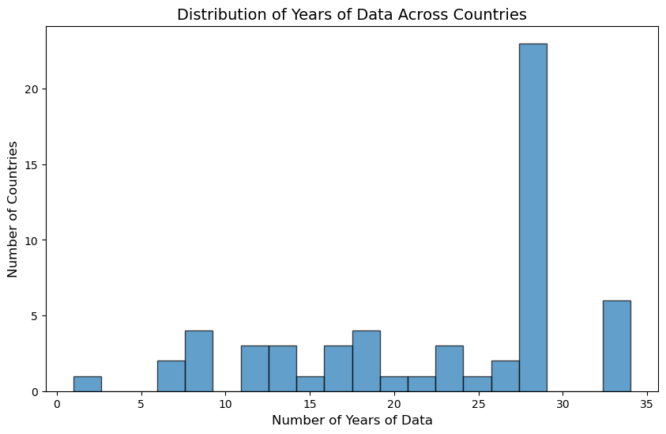

```python
# Count the number of unique years of data available for each country
features = ['country', 'year', 'population', 'gdp', 'electricity_generation', 'fossil_fuel_consumption', 'hydro_share_elec', 'renewables_share_energy', 'renewable_energy_percentage', 'hydro_share_energy',
            'low_carbon_share_energy', 'biofuel_share_energy', 'renewables_energy_per_capita', 'hydro_energy_per_capita', 'low_carbon_energy_per_capita', 'biofuel_cons_per_capita', 'hydro_elec_per_capita', 'renewables_elec_per_capita',
            'other_renewables_share_energy', 'other_renewables_share_elec', 'hydro_consumption', 'hydro_electricity', 'per_capita_electricity', 'gas_energy_per_capita', 'low_carbon_electricity_percentage']
energy_data_ = energy_data[features]
years_per_country = energy_data_.dropna().groupby('country')['year'].nunique()

# Convert to a DataFrame for better readability
years_per_country_df = years_per_country.reset_index()
years_per_country_df.columns = ['country', 'number_of_years']

# Display the result
display(years_per_country_df)
plt.figure(figsize=(10, 6))
plt.hist(years_per_country_df['number_of_years'], bins=20, edgecolor='k', alpha=0.7)
plt.xlabel('Number of Years of Data', fontsize=12)
plt.ylabel('Number of Countries', fontsize=12)
plt.title('Distribution of Years of Data Across Countries', fontsize=14)
plt.show()
```

All countries taken into account to train our model will need to have the same number of years of data available ; this means, if a country has more, we'll cut some years to get the same number as the threshold we will have defined. If a country has less years of data available, we won't take it into account. We need to define the threshold accordingly to get the maximum data without losing too much information because we'd have too few years on record. On this graph, we can see that 15 years looks like a good threshold. Let's format data this way :

```python
filtered_countries = years_per_country[years_per_country >= 15].index
filtered_energy_data = energy_data_[energy_data_['country'].isin(filtered_countries)]
sorted_filtered_data = filtered_energy_data.sort_values(by=['country', 'year'], ascending=[True, False])
most_recent_15yrs_pr_country = sorted_filtered_data.groupby('country').head(15)

display(most_recent_15yrs_pr_country.head(35))
```

|  | country | year | population | gdp | electricity_generation | fossil_fuel_consumption | hydro_share_elec | renewables_share_energy | renewable_energy_percentage | hydro_share_energy | ... | biofuel_cons_per_capita | hydro_elec_per_capita | renewables_elec_per_capita | other_renewables_share_energy | other_renewables_share_elec | hydro_consumption | hydro_electricity | per_capita_electricity | gas_energy_per_capita | low_carbon_electricity_percentage |
| --- | --- | --- | --- | --- | --- | --- | --- | --- | --- | --- | --- | --- | --- | --- | --- | --- | --- | --- | --- | --- | --- |
| 1634 | Australia | 2022 | 26177410.0 | NaN | 251.680 | 1421.068 | 6.194 | 14.455 | 14.454716 | 2.687 | ... | 50.855 | 595.552 | 3105.731 | 0.624 | 1.212 | 44.642 | 15.590 | 9614.396 | 15901.653 | 32.302924 |
| 1633 | Australia | 2021 | 25921094.0 | NaN | 247.060 | 1387.223 | 5.974 | 12.895 | 12.895158 | 2.619 | ... | 47.643 | 569.420 | 2776.889 | 0.670 | 1.251 | 41.717 | 14.760 | 9531.233 | 15396.160 | 29.134623 |
| 1632 | Australia | 2020 | 25670052.0 | NaN | 250.910 | 1415.129 | 5.883 | 10.835 | 10.834538 | 2.386 | ... | 46.859 | 574.989 | 2492.788 | 0.686 | 1.267 | 37.874 | 14.760 | 9774.425 | 16553.490 | 25.503168 |
| 1631 | Australia | 2019 | 25357168.0 | NaN | 249.860 | 1531.156 | 6.243 | 8.874 | 8.873594 | 2.200 | ... | 59.703 | 615.211 | 2106.308 | 0.659 | 1.297 | 36.958 | 15.600 | 9853.624 | 17374.590 | 21.375971 |
| 1630 | Australia | 2018 | 24979228.0 | 1.238560e+12 | 250.380 | 1490.901 | 6.310 | 8.278 | 8.278493 | 2.818 | ... | 66.270 | 632.526 | 1718.628 | 0.705 | 1.398 | 45.801 | 15.800 | 10023.528 | 14888.683 | 17.145938 |
| 1629 | Australia | 2017 | 24590336.0 | 1.205343e+12 | 249.910 | 1493.950 | 6.418 | 6.743 | 6.742948 | 2.243 | ... | 74.589 | 652.289 | 1657.968 | 0.710 | 1.356 | 35.927 | 16.040 | 10162.936 | 15162.218 | 16.313873 |
| 1628 | Australia | 2016 | 24195706.0 | 1.176481e+12 | 246.070 | 1491.312 | 6.104 | 7.186 | 7.185489 | 2.937 | ... | 76.707 | 620.771 | 1587.472 | 0.721 | 1.414 | 47.195 | 15.020 | 10169.986 | 15685.702 | 15.609379 |
| 1627 | Australia | 2015 | 23820240.0 | 1.145387e+12 | 230.840 | 1500.939 | 5.770 | 6.282 | 6.282219 | 2.369 | ... | 100.199 | 559.188 | 1390.414 | 0.733 | 1.443 | 37.935 | 13.320 | 9690.918 | 16370.515 | 14.347600 |
| 1626 | Australia | 2014 | 23469578.0 | 1.117472e+12 | 241.610 | 1472.994 | 7.591 | 5.967 | 5.966582 | 2.505 | ... | 127.943 | 781.437 | 1540.292 | 0.723 | 1.403 | 39.239 | 18.340 | 10294.604 | 16006.997 | 14.962129 |
| 1625 | Australia | 2013 | 23111788.0 | 1.087110e+12 | 229.980 | 1454.284 | 7.879 | 6.512 | 6.512144 | 3.344 | ... | 126.406 | 784.016 | 1479.764 | 0.684 | 1.331 | 52.025 | 18.120 | 9950.766 | 15143.996 | 14.870858 |
| 1624 | Australia | 2012 | 22729272.0 | 1.064162e+12 | 233.380 | 1448.736 | 5.990 | 5.688 | 5.688188 | 3.041 | ... | 131.186 | 615.066 | 1171.617 | 0.644 | 1.255 | 46.712 | 13.980 | 10267.817 | 14644.045 | 11.410575 |
| 1623 | Australia | 2011 | 22357032.0 | 1.026035e+12 | 240.890 | 1469.942 | 6.928 | 5.688 | 5.688431 | 3.464 | ... | 137.211 | 746.521 | 1222.434 | 0.527 | 1.021 | 53.992 | 16.690 | 10774.687 | 14797.118 | 11.345427 |
| 1622 | Australia | 2010 | 22019166.0 | 9.940677e+11 | 233.630 | 1443.765 | 5.778 | 4.313 | 4.312789 | 2.529 | ... | 117.021 | 613.102 | 959.618 | 0.517 | 0.984 | 38.153 | 13.500 | 10610.303 | 14399.467 | 9.044215 |
| 1621 | Australia | 2009 | 21660898.0 | 9.649375e+11 | 234.740 | 1450.366 | 4.976 | 3.920 | 3.920257 | 2.339 | ... | 81.846 | 539.220 | 845.764 | 0.589 | 1.133 | 35.306 | 11.680 | 10837.039 | 13451.167 | 7.804379 |
| 1620 | Australia | 2008 | 21247876.0 | 9.421089e+11 | 229.550 | 1475.357 | 5.136 | 3.681 | 3.681354 | 2.168 | ... | 60.205 | 554.879 | 870.205 | 0.770 | 1.516 | 33.201 | 11.790 | 10803.433 | 13429.558 | 8.054890 |
| 1799 | Austria | 2022 | 8939617.0 | NaN | 64.690 | 241.898 | 55.758 | 36.608 | 36.608044 | 24.279 | ... | 534.141 | 4034.848 | 5520.370 | 3.928 | 5.596 | 92.647 | 36.070 | 7236.328 | 8851.414 | 76.286907 |
| 1798 | Austria | 2021 | 8922086.0 | NaN | 66.950 | 257.993 | 57.879 | 36.084 | 36.084183 | 25.121 | ... | 560.002 | 4343.155 | 5912.294 | 3.552 | 6.692 | 101.400 | 38.750 | 7503.850 | 10102.873 | 78.790142 |
| 1797 | Austria | 2020 | 8907780.0 | NaN | 69.190 | 247.937 | 60.702 | 38.186 | 38.186047 | 27.499 | ... | 558.705 | 4714.979 | 6221.527 | 3.662 | 6.634 | 110.299 | 42.000 | 7767.368 | 9572.810 | 80.098280 |
| 1796 | Austria | 2019 | 8879939.0 | NaN | 70.860 | 276.533 | 57.621 | 35.544 | 35.544300 | 25.084 | ... | 658.971 | 4598.005 | 6153.195 | 3.473 | 6.576 | 107.616 | 40.830 | 7979.784 | 10023.088 | 77.109794 |
| 1795 | Austria | 2018 | 8840518.0 | 3.822695e+11 | 65.040 | 267.331 | 57.872 | 34.528 | 34.527923 | 24.388 | ... | 658.024 | 4257.669 | 5662.564 | 3.865 | 7.580 | 99.580 | 37.640 | 7357.035 | 9826.255 | 76.968020 |
| 1794 | Austria | 2017 | 8797497.0 | 3.732380e+11 | 67.420 | 273.110 | 56.793 | 34.538 | 34.538020 | 24.427 | ... | 632.997 | 4352.375 | 5802.787 | 3.775 | 7.298 | 101.911 | 38.290 | 7663.543 | 10309.585 | 75.719371 |
| 1793 | Austria | 2016 | 8736491.0 | 3.642183e+11 | 65.250 | 262.339 | 61.257 | 35.699 | 35.698704 | 26.228 | ... | 730.732 | 4575.063 | 5846.741 | 3.752 | 7.326 | 107.005 | 39.970 | 7468.674 | 9548.673 | 78.283525 |
| 1792 | Austria | 2015 | 8642422.0 | 3.589881e+11 | 61.850 | 256.637 | 60.081 | 35.003 | 35.003102 | 25.342 | ... | 891.271 | 4299.721 | 5506.558 | 3.770 | 7.518 | 100.062 | 37.160 | 7156.558 | 9219.747 | 76.944220 |
| 1791 | Austria | 2014 | 8546066.0 | 3.553646e+11 | 61.620 | 250.132 | 66.553 | 36.643 | 36.643043 | 28.139 | ... | 756.699 | 4798.699 | 5874.048 | 3.688 | 7.384 | 111.093 | 41.010 | 7210.335 | 8788.811 | 81.467056 |
| 1790 | Austria | 2013 | 8479542.0 | 3.529138e+11 | 64.590 | 266.151 | 65.057 | 35.275 | 35.275192 | 27.848 | ... | 613.661 | 4955.456 | 5955.511 | 3.657 | 7.277 | 114.513 | 42.020 | 7617.156 | 9670.877 | 78.185478 |
| 1789 | Austria | 2012 | 8429641.0 | 3.524509e+11 | 68.700 | 265.732 | 63.828 | 35.895 | 35.894665 | 29.004 | ... | 701.470 | 5201.882 | 6089.228 | 3.613 | 6.812 | 120.228 | 43.850 | 8149.813 | 10230.733 | 74.716157 |
| 1788 | Austria | 2011 | 8391201.0 | 3.498431e+11 | 62.260 | 275.227 | 54.995 | 30.510 | 30.510165 | 23.847 | ... | 712.217 | 4080.465 | 4875.345 | 3.685 | 7.324 | 94.449 | 34.240 | 7419.677 | 10775.343 | 65.708320 |
| 1787 | Austria | 2010 | 8362829.0 | 3.389271e+11 | 67.910 | 287.390 | 56.487 | 31.599 | 31.599378 | 25.343 | ... | 711.078 | 4586.965 | 5379.759 | 3.419 | 6.597 | 106.481 | 38.360 | 8120.458 | 11494.689 | 66.249448 |
| 1786 | Austria | 2009 | 8342939.0 | 3.311922e+11 | 66.300 | 267.230 | 61.689 | 34.317 | 34.316509 | 28.073 | ... | 731.296 | 4902.350 | 5655.082 | 3.370 | 6.456 | 114.212 | 40.900 | 7946.840 | 10586.094 | 71.161388 |
| 1785 | Austria | 2008 | 8321134.0 | 3.428909e+11 | 64.500 | 288.421 | 59.426 | 31.330 | 31.329968 | 25.644 | ... | 577.792 | 4606.344 | 5351.434 | 3.175 | 6.450 | 107.708 | 38.330 | 7751.347 | 10898.219 | 69.038760 |
| 2285 | Belarus | 2022 | 9534956.0 | NaN | 39.641 | 282.160 | 0.865 | 0.996 | 1.036771 | 0.301 | ... | 0.000 | 35.973 | 112.713 | 0.282 | 0.663 | 0.894 | 0.343 | 4157.466 | 19362.898 | 14.543024 |
| 2284 | Belarus | 2021 | 9578172.0 | NaN | 43.860 | 288.320 | 0.889 | 0.920 | 0.966225 | 0.294 | ... | 15.869 | 40.718 | 135.725 | 0.274 | 1.231 | 0.898 | 0.390 | 4579.162 | 19587.965 | 16.142271 |
| 2283 | Belarus | 2020 | 9633745.0 | NaN | 36.200 | 282.934 | 1.077 | 1.045 | 1.048155 | 0.366 | ... | 16.427 | 40.483 | 131.828 | 0.298 | 1.409 | 1.051 | 0.390 | 3757.625 | 18425.863 | 4.447514 |
| 2282 | Belarus | 2019 | 9673971.0 | NaN | 37.680 | 306.476 | 0.902 | 0.761 | 0.760946 | 0.300 | ... | 16.999 | 35.146 | 97.168 | 0.114 | 0.637 | 0.925 | 0.340 | 3894.988 | 19810.375 | 2.494692 |
| 2281 | Belarus | 2018 | 9695573.0 | 1.784353e+11 | 36.660 | 305.329 | 0.873 | 0.626 | 0.625871 | 0.279 | ... | 14.841 | 33.005 | 83.543 | 0.113 | 0.573 | 0.857 | 0.320 | 3781.107 | 19920.711 | 2.209493 |

35 rows × 25 columns

Now we can use LSTM with a time step of 15.

```python
# To use LSTM, we need to normalize the data.
features_ = features[1:-1]
X = energy_data[features_]
y = energy_data['low_carbon_electricity_percentage']
X=X.dropna()
y=y.loc[X.index]

# Normalize data
scaler_X = MinMaxScaler()
scaler_y = MinMaxScaler()
X_scaled = scaler_X.fit_transform(X)
y_scaled = scaler_y.fit_transform(y.values.reshape(-1, 1))

# Convert data to sequences for LSTM
def create_sequences(X, y, time_steps):
    X_seq, y_seq = [], []
    for i in range(len(X) - time_steps):
        X_seq.append(X[i:i+time_steps, :])
        y_seq.append(y[i+time_steps])
    return np.array(X_seq), np.array(y_seq)

time_steps = 15

X_seq, y_seq = create_sequences(X_scaled, y_scaled, time_steps)

# While using LSTM, we split data ONCE we have created the sequences.
X_train, X_test, y_train, y_test = train_test_split(X_seq, y_seq, test_size=0.3, random_state=42)
```

```python
# Build the LSTM model
model = Sequential()
model.add(LSTM(50, activation='relu', input_shape=(time_steps, X_train.shape[2])))
model.add(Dense(1))  # Output layer

# Compile and train the model
model.compile(optimizer='adam', loss='mse')
history = model.fit(X_train, y_train, epochs=50, batch_size=32, validation_data=(X_test, y_test), verbose=1)
```

```
29/29 ━━━━━━━━━━━━━━━━━━━━ 1s 10ms/step - loss: 0.1996 - val_loss: 0.0614
29/29 ━━━━━━━━━━━━━━━━━━━━ 0s 5ms/step - loss: 0.0485 - val_loss: 0.0462
29/29 ━━━━━━━━━━━━━━━━━━━━ 0s 17ms/step - loss: 0.0361 - val_loss: 0.0370
29/29 ━━━━━━━━━━━━━━━━━━━━ 0s 5ms/step - loss: 0.0314 - val_loss: 0.0259
29/29 ━━━━━━━━━━━━━━━━━━━━ 0s 5ms/step - loss: 0.0212 - val_loss: 0.0208
29/29 ━━━━━━━━━━━━━━━━━━━━ 0s 5ms/step - loss: 0.0158 - val_loss: 0.0193
29/29 ━━━━━━━━━━━━━━━━━━━━ 0s 5ms/step - loss: 0.0143 - val_loss: 0.0206
29/29 ━━━━━━━━━━━━━━━━━━━━ 0s 5ms/step - loss: 0.0152 - val_loss: 0.0172
29/29 ━━━━━━━━━━━━━━━━━━━━ 0s 5ms/step - loss: 0.0129 - val_loss: 0.0164
29/29 ━━━━━━━━━━━━━━━━━━━━ 0s 5ms/step - loss: 0.0109 - val_loss: 0.0184
29/29 ━━━━━━━━━━━━━━━━━━━━ 0s 5ms/step - loss: 0.0129 - val_loss: 0.0155
29/29 ━━━━━━━━━━━━━━━━━━━━ 0s 5ms/step - loss: 0.0101 - val_loss: 0.0157
29/29 ━━━━━━━━━━━━━━━━━━━━ 0s 5ms/step - loss: 0.0093 - val_loss: 0.0153
29/29 ━━━━━━━━━━━━━━━━━━━━ 0s 5ms/step - loss: 0.0107 - val_loss: 0.0170
29/29 ━━━━━━━━━━━━━━━━━━━━ 0s 5ms/step - loss: 0.0118 - val_loss: 0.0166
29/29 ━━━━━━━━━━━━━━━━━━━━ 0s 5ms/step - loss: 0.0083 - val_loss: 0.0146
29/29 ━━━━━━━━━━━━━━━━━━━━ 0s 5ms/step - loss: 0.0092 - val_loss: 0.0156
29/29 ━━━━━━━━━━━━━━━━━━━━ 0s 5ms/step - loss: 0.0087 - val_loss: 0.0143
29/29 ━━━━━━━━━━━━━━━━━━━━ 0s 5ms/step - loss: 0.0095 - val_loss: 0.0145
29/29 ━━━━━━━━━━━━━━━━━━━━ 0s 5ms/step - loss: 0.0069 - val_loss: 0.0154
29/29 ━━━━━━━━━━━━━━━━━━━━ 0s 5ms/step - loss: 0.0077 - val_loss: 0.0158
29/29 ━━━━━━━━━━━━━━━━━━━━ 0s 5ms/step - loss: 0.0075 - val_loss: 0.0147
29/29 ━━━━━━━━━━━━━━━━━━━━ 0s 5ms/step - loss: 0.0078 - val_loss: 0.0142
29/29 ━━━━━━━━━━━━━━━━━━━━ 0s 5ms/step - loss: 0.0080 - val_loss: 0.0137
29/29 ━━━━━━━━━━━━━━━━━━━━ 0s 5ms/step - loss: 0.0082 - val_loss: 0.0152
29/29 ━━━━━━━━━━━━━━━━━━━━ 0s 5ms/step - loss: 0.0086 - val_loss: 0.0141
29/29 ━━━━━━━━━━━━━━━━━━━━ 0s 5ms/step - loss: 0.0088 - val_loss: 0.0146
29/29 ━━━━━━━━━━━━━━━━━━━━ 0s 5ms/step - loss: 0.0073 - val_loss: 0.0140
29/29 ━━━━━━━━━━━━━━━━━━━━ 0s 5ms/step - loss: 0.0084 - val_loss: 0.0142
29/29 ━━━━━━━━━━━━━━━━━━━━ 0s 5ms/step - loss: 0.0053 - val_loss: 0.0138
29/29 ━━━━━━━━━━━━━━━━━━━━ 0s 5ms/step - loss: 0.0067 - val_loss: 0.0141
29/29 ━━━━━━━━━━━━━━━━━━━━ 0s 5ms/step - loss: 0.0082 - val_loss: 0.0142
29/29 ━━━━━━━━━━━━━━━━━━━━ 0s 5ms/step - loss: 0.0059 - val_loss: 0.0150
29/29 ━━━━━━━━━━━━━━━━━━━━ 0s 5ms/step - loss: 0.0066 - val_loss: 0.0138
29/29 ━━━━━━━━━━━━━━━━━━━━ 0s 5ms/step - loss: 0.0073 - val_loss: 0.0136
29/29 ━━━━━━━━━━━━━━━━━━━━ 0s 5ms/step - loss: 0.0058 - val_loss: 0.0148
29/29 ━━━━━━━━━━━━━━━━━━━━ 0s 5ms/step - loss: 0.0059 - val_loss: 0.0140
29/29 ━━━━━━━━━━━━━━━━━━━━ 0s 5ms/step - loss: 0.0069 - val_loss: 0.0156
29/29 ━━━━━━━━━━━━━━━━━━━━ 0s 5ms/step - loss: 0.0073 - val_loss: 0.0134
29/29 ━━━━━━━━━━━━━━━━━━━━ 0s 5ms/step - loss: 0.0058 - val_loss: 0.0144
29/29 ━━━━━━━━━━━━━━━━━━━━ 0s 5ms/step - loss: 0.0062 - val_loss: 0.0134
29/29 ━━━━━━━━━━━━━━━━━━━━ 0s 5ms/step - loss: 0.0066 - val_loss: 0.0147
29/29 ━━━━━━━━━━━━━━━━━━━━ 0s 5ms/step - loss: 0.0061 - val_loss: 0.0135
29/29 ━━━━━━━━━━━━━━━━━━━━ 0s 5ms/step - loss: 0.0058 - val_loss: 0.0132
29/29 ━━━━━━━━━━━━━━━━━━━━ 0s 5ms/step - loss: 0.0064 - val_loss: 0.0150
29/29 ━━━━━━━━━━━━━━━━━━━━ 0s 5ms/step - loss: 0.0054 - val_loss: 0.0133
29/29 ━━━━━━━━━━━━━━━━━━━━ 0s 5ms/step - loss: 0.0065 - val_loss: 0.0136
29/29 ━━━━━━━━━━━━━━━━━━━━ 0s 5ms/step - loss: 0.0064 - val_loss: 0.0135
29/29 ━━━━━━━━━━━━━━━━━━━━ 0s 5ms/step - loss: 0.0063 - val_loss: 0.0140
29/29 ━━━━━━━━━━━━━━━━━━━━ 0s 5ms/step - loss: 0.0068 - val_loss: 0.0137
```

```python
# Evaluate the model
y_pred = model.predict(X_test)
y_pred_rescaled = scaler_y.inverse_transform(y_pred)  # Rescale to original values
y_test_rescaled = scaler_y.inverse_transform(y_test)  # Rescale to original values

# Calculate RMSE or other metrics
rmse = np.sqrt(mean_squared_error(y_test_rescaled, y_pred_rescaled))
print(f"RMSE: {rmse}")
```

```
13/13 ━━━━━━━━━━━━━━━━━━━━ 0s 9ms/step
RMSE: 11.721722967359494
```

```
29/29 ━━━━━━━━━━━━━━━━━━━━ 0s 2ms/step
Training RMSE: 7.489795986628153
13/13 ━━━━━━━━━━━━━━━━━━━━ 0s 2ms/step
Test RMSE: 11.721722967359494
```

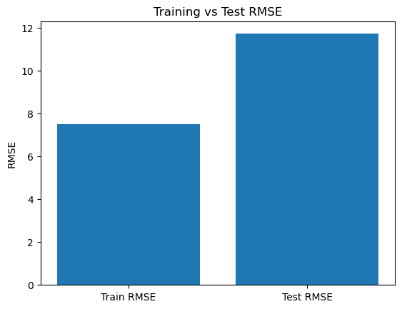

```python
# Predict on training data
y_train_pred = model.predict(X_train)

# Rescale predictions and actual values back to original scale
y_train_pred_rescaled = scaler_y.inverse_transform(y_train_pred)
y_train_rescaled = scaler_y.inverse_transform(y_train)

rmse_train = np.sqrt(mean_squared_error(y_train_rescaled, y_train_pred_rescaled))
print(f"Training RMSE: {rmse_train}")


# Predict on test data
y_test_pred = model.predict(X_test)

# Rescale predictions and actual values back to original scale
y_test_pred_rescaled = scaler_y.inverse_transform(y_test_pred)
y_test_rescaled = scaler_y.inverse_transform(y_test)

# Calculate RMSE for test data
rmse_test = np.sqrt(mean_squared_error(y_test_rescaled, y_test_pred_rescaled))
print(f"Test RMSE: {rmse_test}")


plt.bar(['Train RMSE', 'Test RMSE'], [rmse_train, rmse_test])
plt.title('Training vs Test RMSE')
plt.ylabel('RMSE')
plt.show()
```

```python
# hyperparameters to tune
neurons = 150
dropouts = [0.0, 0.2, 0.5]
learning_rates = [0.001, 0.01]
batch_sizes = [16, 32]
time_steps_options = [5, 10, 20]

# Function to create sequences
def create_sequences(X, y, time_steps):
    X_seq, y_seq = [], []
    for i in range(len(X) - time_steps):
        X_seq.append(X[i:i + time_steps, :])
        y_seq.append(y[i + time_steps])
    return np.array(X_seq), np.array(y_seq)


results = []
# Iterate through all parameter combinations
for dropout_, lr_, batch_size_, time_steps_ in itertools.product(dropouts, learning_rates, batch_sizes, time_steps_options):

    # Prepare data with the current time_steps
    X_seq, y_seq = create_sequences(X_scaled, y_scaled, time_steps_)
    X_train, X_test, y_train, y_test = train_test_split(X_seq, y_seq, test_size=0.3, random_state=42)

    # Build the model
    model = Sequential()
    model.add(LSTM(neurons, activation='tanh', input_shape=(time_steps_, X_train.shape[2])))
    if dropout_ > 0.0:
        model.add(Dropout(dropout_))
    model.add(Dense(1))

    # Compile the model
    optimizer = Adam(learning_rate=lr_)
    model.compile(optimizer=optimizer, loss='mse')

    # Train the model
    history = model.fit(X_train, y_train, epochs=10, batch_size=batch_size_, validation_data=(X_test, y_test), verbose=0)

    # Predict & calculate RMSE
    y_train_pred = scaler_y.inverse_transform(model.predict(X_train))
    y_train_actual = scaler_y.inverse_transform(y_train)
    y_test_pred = scaler_y.inverse_transform(model.predict(X_test))
    y_test_actual = scaler_y.inverse_transform(y_test)

    rmse_train = np.sqrt(mean_squared_error(y_train_actual, y_train_pred))
    rmse_test = np.sqrt(mean_squared_error(y_test_actual, y_test_pred))

    # Store the results
    results.append({
        'neurons': neurons,
        'dropout': dropout_,
        'learning_rate': lr_,
        'batch_size': batch_size_,
        'time_steps': time_steps_,
        'rmse_train': rmse_train,
        'rmse_test': rmse_test
    })

    print(f"Done: dropout={dropout_}, lr={lr_}, batch_size={batch_size_}, time_steps={time_steps_}")

# Convert results to a DataFrame
results_df = pd.DataFrame(results)
results_df = results_df.sort_values(by='rmse_test')

# Display results and show the top configs to draw conclusions
print("LSTM Hyperparameter Tuning Results:")
print(results_df.head(10))
```

```
29/29 ━━━━━━━━━━━━━━━━━━━━ 0s 4ms/step
13/13 ━━━━━━━━━━━━━━━━━━━━ 0s 2ms/step
Done: dropout=0.0, lr=0.001, batch_size=16, time_steps=5
29/29 ━━━━━━━━━━━━━━━━━━━━ 0s 5ms/step
13/13 ━━━━━━━━━━━━━━━━━━━━ 0s 3ms/step
Done: dropout=0.0, lr=0.001, batch_size=16, time_steps=10
29/29 ━━━━━━━━━━━━━━━━━━━━ 0s 6ms/step
13/13 ━━━━━━━━━━━━━━━━━━━━ 0s 4ms/step
Done: dropout=0.0, lr=0.001, batch_size=16, time_steps=20
29/29 ━━━━━━━━━━━━━━━━━━━━ 0s 4ms/step
13/13 ━━━━━━━━━━━━━━━━━━━━ 0s 2ms/step
Done: dropout=0.0, lr=0.001, batch_size=32, time_steps=5
29/29 ━━━━━━━━━━━━━━━━━━━━ 0s 5ms/step
13/13 ━━━━━━━━━━━━━━━━━━━━ 0s 2ms/step
Done: dropout=0.0, lr=0.001, batch_size=32, time_steps=10
29/29 ━━━━━━━━━━━━━━━━━━━━ 0s 6ms/step
13/13 ━━━━━━━━━━━━━━━━━━━━ 0s 4ms/step
Done: dropout=0.0, lr=0.001, batch_size=32, time_steps=20
29/29 ━━━━━━━━━━━━━━━━━━━━ 0s 5ms/step
13/13 ━━━━━━━━━━━━━━━━━━━━ 0s 2ms/step
Done: dropout=0.0, lr=0.01, batch_size=16, time_steps=5
29/29 ━━━━━━━━━━━━━━━━━━━━ 0s 6ms/step
13/13 ━━━━━━━━━━━━━━━━━━━━ 0s 3ms/step
Done: dropout=0.0, lr=0.01, batch_size=16, time_steps=10
29/29 ━━━━━━━━━━━━━━━━━━━━ 0s 7ms/step
13/13 ━━━━━━━━━━━━━━━━━━━━ 0s 5ms/step
Done: dropout=0.0, lr=0.01, batch_size=16, time_steps=20
29/29 ━━━━━━━━━━━━━━━━━━━━ 0s 4ms/step
13/13 ━━━━━━━━━━━━━━━━━━━━ 0s 2ms/step
Done: dropout=0.0, lr=0.01, batch_size=32, time_steps=5
29/29 ━━━━━━━━━━━━━━━━━━━━ 0s 5ms/step
13/13 ━━━━━━━━━━━━━━━━━━━━ 0s 3ms/step
Done: dropout=0.0, lr=0.01, batch_size=32, time_steps=10
29/29 ━━━━━━━━━━━━━━━━━━━━ 0s 6ms/step
13/13 ━━━━━━━━━━━━━━━━━━━━ 0s 4ms/step
Done: dropout=0.0, lr=0.01, batch_size=32, time_steps=20
29/29 ━━━━━━━━━━━━━━━━━━━━ 0s 4ms/step
13/13 ━━━━━━━━━━━━━━━━━━━━ 0s 2ms/step
Done: dropout=0.2, lr=0.001, batch_size=16, time_steps=5
29/29 ━━━━━━━━━━━━━━━━━━━━ 0s 5ms/step
```

[output cut: 77 more lines]

```
32      150      0.5          0.010          16          20   10.785867
11      150      0.0          0.010          32          20   10.751642
35      150      0.5          0.010          32          20   10.788783

    rmse_test
22   9.340001
19   9.560091
31   9.722712
10   9.754061
34   9.846556
20  10.139507
1   10.271813
32  10.325229
11  10.464793
35  10.465806
```

```python
# Choose the best configuration based on RMSE
best_config = results_df.iloc[0]
print("\nBest Configuration:")
print(best_config)

# Display some predictions from the best model
print("\n=== Actual vs Predicted ===")
#n_samples_to_display = 10  # Number of samples to display
comparison_df = pd.DataFrame({
    'True Value': y_test_actual.flatten(),
    'Predicted Value': y_test_pred.flatten()
})

# Display the DataFrame
display(comparison_df.head(10))
```

```
Best Configuration:
neurons          150.000000
dropout            0.200000
learning_rate      0.010000
batch_size        32.000000
time_steps        10.000000
rmse_train        10.123088
rmse_test          9.340001
Name: 22, dtype: float64

=== Actual vs Predicted ===
```

|  | True Value | Predicted Value |
| --- | --- | --- |
| 0 | 19.967213 | 18.476095 |
| 1 | 7.269512 | 5.101093 |
| 2 | 73.723507 | 69.870102 |
| 3 | 5.836447 | 3.879525 |
| 4 | 6.443164 | 6.469654 |
| 5 | 49.669500 | 47.900528 |
| 6 | 94.928425 | 98.776558 |
| 7 | 75.839157 | 73.562698 |
| 8 | 29.336617 | 24.938553 |
| 9 | 0.979730 | 6.253077 |

```python
comparison_df['True Above 90'] = (comparison_df['True Value'] > 90).astype(int)
comparison_df['Predicted Above 90'] = (comparison_df['Predicted Value'] > 90).astype(int)

# Display the updated DataFrame
print("\nUpdated DataFrame with Binary Columns:")
display(comparison_df.head(20))

# Generate a classification report
true_labels = comparison_df['True Above 90']
predicted_labels = comparison_df['Predicted Above 90']

report = classification_report(true_labels, predicted_labels, target_names=['Below 90', 'Above 90'])

# Display the classification report
print("\nClassification Report:")
print(report)
```

```
Updated DataFrame with Binary Columns:
```

|  | True Value | Predicted Value | True Above 90 | Predicted Above 90 |
| --- | --- | --- | --- | --- |
| 0 | 19.967213 | 18.476095 | 0 | 0 |
| 1 | 7.269512 | 5.101093 | 0 | 0 |
| 2 | 73.723507 | 69.870102 | 0 | 0 |
| 3 | 5.836447 | 3.879525 | 0 | 0 |
| 4 | 6.443164 | 6.469654 | 0 | 0 |
| 5 | 49.669500 | 47.900528 | 0 | 0 |
| 6 | 94.928425 | 98.776558 | 1 | 1 |
| 7 | 75.839157 | 73.562698 | 0 | 0 |
| 8 | 29.336617 | 24.938553 | 0 | 0 |
| 9 | 0.979730 | 6.253077 | 0 | 0 |
| 10 | 7.061527 | 10.258363 | 0 | 0 |
| 11 | 1.130199 | -4.378078 | 0 | 0 |
| 12 | 35.608279 | 32.430183 | 0 | 0 |
| 13 | 33.434681 | 38.857803 | 0 | 0 |
| 14 | 88.086420 | 71.401314 | 0 | 0 |
| 15 | 22.102740 | 25.086985 | 0 | 0 |
| 16 | 68.066802 | 70.792343 | 0 | 0 |
| 17 | 16.375278 | 17.854311 | 0 | 0 |
| 18 | 0.117509 | -3.724308 | 0 | 0 |
| 19 | 53.751351 | 58.244205 | 0 | 0 |

```
Classification Report:
              precision    recall  f1-score   support

    Below 90       0.97      0.99      0.98       367
    Above 90       0.88      0.54      0.67        26

    accuracy                           0.96       393
   macro avg       0.92      0.77      0.82       393
weighted avg       0.96      0.96      0.96       393
```

# Project Conclusion

To sum eveything up, if we want to predict a country's ability to use low-carbon and renewable energies based on diverse data, as all of this data is closely related, we don't need to dig deep in Neural Network techniques. Simple regressions and Gradient Boost techniques give satisfying techniques.

# Addendum

Separating countries in only 2 categories can make us short of information when we'll need these predictions. A political advisor or decision-maker, for example, could need a more refined report. That's the occasion for us to implement technical solutions we never got the chance to implement here, but that are often major parts of Machine Learning courses : classification problems. We will also take the occasion to use PCA, that we've a bit underused, which is a very good solution to limit the resources needed to execute a code, and is fitting our situation : PCA works better when several segments of data are highly correlated, and we have this here.

Here, we will start with a simple Random Forest Classifier, which will allow us to implement PCA a first time.

```python
features = ['population', 'gdp', 'electricity_generation', 'fossil_fuel_consumption', 'hydro_share_elec', 'renewables_share_energy', 'renewable_energy_percentage', 'hydro_share_energy',
            'low_carbon_share_energy', 'biofuel_share_energy', 'renewables_energy_per_capita', 'hydro_energy_per_capita', 'low_carbon_energy_per_capita', 'biofuel_cons_per_capita', 'hydro_elec_per_capita', 'renewables_elec_per_capita',
            'year', 'low_carbon_elec_per_capita', 'other_renewables_share_energy', 'other_renewables_share_elec', 'hydro_consumption', 'hydro_electricity', 'per_capita_electricity', 'gas_energy_per_capita']

filtered_data = energy_data[features + ['low_carbon_electricity_percentage']].dropna()
X = filtered_data[features]
y = filtered_data['low_carbon_electricity_percentage']

# Binning the target variable into 3 classes
bins = [0, 30, 60, 100]
labels = ['Low', 'Medium', 'High']
y_binned = pd.cut(y, bins=bins, labels=labels)

# Ensure no NaN values in features or target
X_cleaned = X.loc[y_binned.dropna().index]
y_binned_cleaned = y_binned.dropna()
X_cleaned = X_cleaned.dropna()
y_binned_cleaned = y_binned_cleaned.loc[X_cleaned.index]

# Standardize features and apply PCA
scaler = StandardScaler()
X_scaled = scaler.fit_transform(X_cleaned)
pca = PCA(n_components=0.95)
X_pca = pca.fit_transform(X_scaled)

# Split the data
X_train, X_test, y_train, y_test = train_test_split(X_pca, y_binned_cleaned, test_size=0.3, random_state=42)

# Train a Random Forest Classifier, a basic choice for a categorical prevision.
clf = RandomForestClassifier(random_state=42)
clf.fit(X_train, y_train)

# Predict on the test set
y_pred = clf.predict(X_test)

# Evaluate the model
classification_report_result = classification_report(y_test, y_pred, output_dict=True)
accuracy = accuracy_score(y_test, y_pred)

# Display the results
print("Classification Report:")
print(classification_report(y_test, y_pred))
print(f"Accuracy: {accuracy}")
```

```
Classification Report:
              precision    recall  f1-score   support

        High       0.94      0.91      0.93       123
         Low       0.93      0.98      0.95       151
      Medium       0.89      0.86      0.87       121

    accuracy                           0.92       395
   macro avg       0.92      0.92      0.92       395
weighted avg       0.92      0.92      0.92       395

Accuracy: 0.9215189873417722
```

```python
results_df = pd.DataFrame({
    'Actual': y_test.values,
    'Predicted': y_pred})

# Calculate probabilities for each class
probabilities = clf.predict_proba(X_test)
class_labels = clf.classes_  # Get the class labels

# Add probabilities to the results DataFrame
for idx, label in enumerate(class_labels):
    results_df[f'Probability_{label}'] = probabilities[:, idx]

# Include a few principal components for context
components_to_display = 3
for i in range(components_to_display):
    results_df[f'PC{i + 1}'] = X_test[:, i]

# Define a function to apply conditional formatting
def highlight_row(row):
    if row['Actual'] == row['Predicted']:
        return ['background-color: lightgreen'] * len(row)
    else:
        return ['background-color: lightcoral'] * len(row)

# Display PCA components for context
print("PCA Components:")
pca_components = pd.DataFrame(pca.components_, columns=X_cleaned.columns,
                              index=[f'PC{i+1}' for i in range(pca.components_.shape[0])])
display(pca_components)

# Apply conditional formatting and display the styled DataFrame
styled_df = results_df.head(10).style.apply(highlight_row, axis=1)
display(styled_df)
```

```
PCA Components:
```

|  | population | gdp | electricity_generation | fossil_fuel_consumption | hydro_share_elec | renewables_share_energy | renewable_energy_percentage | hydro_share_energy | low_carbon_share_energy | biofuel_share_energy | ... | hydro_elec_per_capita | renewables_elec_per_capita | year | low_carbon_elec_per_capita | other_renewables_share_energy | other_renewables_share_elec | hydro_consumption | hydro_electricity | per_capita_electricity | gas_energy_per_capita |
| --- | --- | --- | --- | --- | --- | --- | --- | --- | --- | --- | --- | --- | --- | --- | --- | --- | --- | --- | --- | --- | --- |
| PC1 | -0.019645 | -0.009908 | -0.006771 | -0.014777 | 0.230207 | 0.283999 | 0.291024 | 0.276526 | 0.270853 | 0.079436 | ... | 0.299091 | 0.304845 | 0.031458 | 0.292434 | 0.118808 | 0.078628 | 0.036244 | 0.035141 | 0.227515 | 0.017015 |
| PC2 | 0.397076 | 0.409697 | 0.410860 | 0.409685 | -0.000391 | -0.000943 | -0.002887 | -0.002194 | -0.009494 | 0.038601 | ... | -0.003195 | -0.004732 | 0.042141 | -0.007650 | -0.019531 | -0.020281 | 0.407153 | 0.407504 | 0.001605 | 0.013378 |
| PC3 | 0.013433 | -0.012007 | -0.033824 | -0.038768 | 0.198409 | 0.226121 | 0.206781 | 0.127245 | 0.105594 | 0.449272 | ... | -0.176578 | -0.139877 | 0.190023 | -0.182350 | 0.300000 | 0.328830 | 0.007550 | 0.008548 | -0.299151 | -0.253732 |
| PC4 | -0.046210 | 0.027022 | 0.028499 | 0.024337 | -0.359901 | -0.162544 | -0.142773 | -0.295304 | -0.079397 | 0.021972 | ... | -0.011954 | 0.061211 | 0.363157 | 0.109593 | 0.369929 | 0.394643 | -0.040178 | -0.037077 | 0.252393 | 0.343767 |
| PC5 | -0.102861 | -0.023190 | -0.016806 | -0.027004 | 0.048618 | -0.020673 | -0.028517 | 0.021010 | -0.004965 | 0.419641 | ... | 0.007785 | -0.026119 | 0.209896 | -0.019507 | -0.460222 | -0.427738 | 0.002200 | 0.001233 | 0.042655 | 0.353505 |
| PC6 | 0.066200 | -0.014598 | -0.031009 | -0.028992 | 0.082302 | 0.084966 | 0.028172 | 0.093747 | -0.205852 | -0.242654 | ... | 0.125262 | 0.108966 | 0.823954 | -0.125487 | -0.109675 | -0.082980 | -0.024059 | -0.015146 | -0.139660 | -0.097357 |
| PC7 | -0.057904 | -0.011387 | -0.003419 | 0.013603 | 0.329239 | 0.134360 | 0.024529 | 0.166944 | -0.285098 | -0.078783 | ... | 0.050360 | 0.035600 | -0.195248 | -0.219863 | 0.095955 | 0.218848 | 0.042053 | 0.037322 | -0.168836 | 0.714274 |

7 rows × 24 columns

|  | Actual | Predicted | Probability_High | Probability_Low | Probability_Medium | PC1 | PC2 | PC3 |
| --- | --- | --- | --- | --- | --- | --- | --- | --- |
| 0 | High | High | 0.980000 | 0.000000 | 0.020000 | 6.940901 | 0.899647 | -2.787857 |
| 1 | Low | Low | 0.000000 | 0.910000 | 0.090000 | -1.652920 | -0.453519 | -1.009985 |
| 2 | Medium | Medium | 0.460000 | 0.020000 | 0.520000 | 0.565403 | -0.359395 | 2.392785 |
| 3 | Medium | Medium | 0.150000 | 0.070000 | 0.780000 | -0.599191 | -0.445420 | 0.264636 |
| 4 | High | High | 0.990000 | 0.000000 | 0.010000 | 8.137685 | 0.753753 | -4.126325 |
| 5 | Low | Medium | 0.020000 | 0.460000 | 0.520000 | -1.155961 | -0.037396 | -0.716783 |
| 6 | High | High | 0.990000 | 0.000000 | 0.010000 | 5.737531 | -0.719795 | 0.068628 |
| 7 | High | High | 0.980000 | 0.000000 | 0.020000 | 8.001829 | -0.458330 | -1.446429 |
| 8 | Low | Low | 0.000000 | 0.950000 | 0.050000 | -2.575759 | -0.511097 | -1.260190 |
| 9 | Medium | Medium | 0.080000 | 0.030000 | 0.890000 | 0.054765 | -0.353122 | 1.050866 |

Now, let's generalize this to other models and see which one performs better. This time, we don't need to balance the data as classes have close number of events.

```python
# We'll use a pipeline to see if results are better with PCA with other models.

# First we define the models to test
models = {
    "Logistic Regression": LogisticRegression(random_state=42, max_iter=500),
    "SVM": SVC(random_state=42),
    "Gradient Boosting": GradientBoostingClassifier(random_state=42),
    "k-Nearest Neighbors": KNeighborsClassifier(n_neighbors=5)}

# Iterate over models and evaluate each
results = {}
for model_name, model in models.items():
    # Train the model
    model.fit(X_train, y_train)

    # Predict on the test set
    y_pred = model.predict(X_test)

    # Store accuracy and classification report
    accuracy = accuracy_score(y_test, y_pred)
    classification_report_result = classification_report(y_test, y_pred, output_dict=True)

    # Save the results
    results[model_name] = {
        "Accuracy": accuracy,
        "Classification Report": classification_report_result,
        "Predictions": pd.DataFrame({
            'Actual': y_test.values,
            'Predicted': y_pred})}

# Display results
for model_name, result in results.items():
    print(f"Model: {model_name}")
    print(f"Accuracy: {result['Accuracy']:.2f}")
    display(pd.DataFrame(result['Classification Report']).transpose())
```

```
Model: Logistic Regression
Accuracy: 0.80
```

|  | precision | recall | f1-score | support |
| --- | --- | --- | --- | --- |
| High | 0.854839 | 0.861789 | 0.858300 | 123.000000 |
| Low | 0.791908 | 0.907285 | 0.845679 | 151.000000 |
| Medium | 0.734694 | 0.595041 | 0.657534 | 121.000000 |
| accuracy | 0.797468 | 0.797468 | 0.797468 | 0.797468 |
| macro avg | 0.793813 | 0.788038 | 0.787171 | 395.000000 |
| weighted avg | 0.793978 | 0.797468 | 0.791975 | 395.000000 |

```
Model: SVM
Accuracy: 0.81
```

|  | precision | recall | f1-score | support |
| --- | --- | --- | --- | --- |
| High | 0.885965 | 0.821138 | 0.852321 | 123.000000 |
| Low | 0.812865 | 0.920530 | 0.863354 | 151.000000 |
| Medium | 0.727273 | 0.661157 | 0.692641 | 121.000000 |
| accuracy | 0.810127 | 0.810127 | 0.810127 | 0.810127 |
| macro avg | 0.808701 | 0.800942 | 0.802772 | 395.000000 |
| weighted avg | 0.809409 | 0.810127 | 0.807624 | 395.000000 |

```
Model: Gradient Boosting
Accuracy: 0.88
```

|  | precision | recall | f1-score | support |
| --- | --- | --- | --- | --- |
| High | 0.915966 | 0.886179 | 0.900826 | 123.000000 |
| Low | 0.887500 | 0.940397 | 0.913183 | 151.000000 |
| Medium | 0.818966 | 0.785124 | 0.801688 | 121.000000 |
| accuracy | 0.875949 | 0.875949 | 0.875949 | 0.875949 |
| macro avg | 0.874144 | 0.870567 | 0.871899 | 395.000000 |
| weighted avg | 0.875370 | 0.875949 | 0.875181 | 395.000000 |

```
Model: k-Nearest Neighbors
Accuracy: 0.89
```

|  | precision | recall | f1-score | support |
| --- | --- | --- | --- | --- |
| High | 0.888889 | 0.910569 | 0.899598 | 123.000000 |
| Low | 0.901840 | 0.973510 | 0.936306 | 151.000000 |
| Medium | 0.867925 | 0.760331 | 0.810573 | 121.000000 |
| accuracy | 0.888608 | 0.888608 | 0.888608 | 0.888608 |
| macro avg | 0.886218 | 0.881470 | 0.882159 | 395.000000 |
| weighted avg | 0.887418 | 0.888608 | 0.886360 | 395.000000 |

We can also try a Sequential model using the keras library, as we did in the end of Stage 3. For that, we will need to use one-hot encoding.

```python
# One-hot encode the target variable
encoder = OneHotEncoder(sparse_output=False)
y_train_encoded = encoder.fit_transform(y_train.values.reshape(-1, 1))
y_test_encoded = encoder.transform(y_test.values.reshape(-1, 1))

# Define the Sequential Keras model
model = Sequential([
    Dense(128, activation='relu', input_shape=(X_train.shape[1],)),
    Dropout(0.3),
    Dense(64, activation='relu'),
    Dropout(0.3),
    Dense(y_train_encoded.shape[1], activation='softmax')])

# Compile the model
model.compile(optimizer='adam', loss='categorical_crossentropy', metrics=['accuracy'])

# Train the model
history = model.fit(X_train, y_train_encoded, epochs=50, batch_size=32, validation_split=0.2, verbose=1)

# Predict on the test set
y_pred_encoded = model.predict(X_test)
y_pred = encoder.inverse_transform(y_pred_encoded)  # Decode one-hot predictions

# Evaluate the model
accuracy = accuracy_score(y_test, y_pred)
classification_report_result = classification_report(y_test, y_pred, output_dict=True)

# Combine predictions and actual labels into a DataFrame
results_df = pd.DataFrame({
    'Actual': y_test.values,
    'Predicted': y_pred.flatten()})


styled_df = results_df.head(10).style.apply(highlight_row, axis=1)
display(pd.DataFrame(classification_report_result).transpose())
display(styled_df)
```

```
23/23 ━━━━━━━━━━━━━━━━━━━━ 1s 7ms/step - accuracy: 0.5218 - loss: 1.0092 - val_accuracy: 0.7228 - val_loss: 0.6944
23/23 ━━━━━━━━━━━━━━━━━━━━ 0s 3ms/step - accuracy: 0.6931 - loss: 0.7075 - val_accuracy: 0.7228 - val_loss: 0.5910
23/23 ━━━━━━━━━━━━━━━━━━━━ 0s 3ms/step - accuracy: 0.6972 - loss: 0.6519 - val_accuracy: 0.7446 - val_loss: 0.5336
23/23 ━━━━━━━━━━━━━━━━━━━━ 0s 3ms/step - accuracy: 0.7168 - loss: 0.5915 - val_accuracy: 0.7772 - val_loss: 0.4964
23/23 ━━━━━━━━━━━━━━━━━━━━ 0s 3ms/step - accuracy: 0.7540 - loss: 0.5271 - val_accuracy: 0.7880 - val_loss: 0.4720
23/23 ━━━━━━━━━━━━━━━━━━━━ 0s 3ms/step - accuracy: 0.7701 - loss: 0.5046 - val_accuracy: 0.7880 - val_loss: 0.4553
23/23 ━━━━━━━━━━━━━━━━━━━━ 0s 3ms/step - accuracy: 0.7910 - loss: 0.5036 - val_accuracy: 0.8098 - val_loss: 0.4396
23/23 ━━━━━━━━━━━━━━━━━━━━ 0s 3ms/step - accuracy: 0.7498 - loss: 0.4762 - val_accuracy: 0.8207 - val_loss: 0.4351
23/23 ━━━━━━━━━━━━━━━━━━━━ 0s 3ms/step - accuracy: 0.8029 - loss: 0.4352 - val_accuracy: 0.8152 - val_loss: 0.4251
23/23 ━━━━━━━━━━━━━━━━━━━━ 0s 3ms/step - accuracy: 0.8041 - loss: 0.4263 - val_accuracy: 0.8261 - val_loss: 0.4210
23/23 ━━━━━━━━━━━━━━━━━━━━ 0s 3ms/step - accuracy: 0.7978 - loss: 0.4616 - val_accuracy: 0.8315 - val_loss: 0.4208
23/23 ━━━━━━━━━━━━━━━━━━━━ 0s 3ms/step - accuracy: 0.8139 - loss: 0.4196 - val_accuracy: 0.8261 - val_loss: 0.4127
23/23 ━━━━━━━━━━━━━━━━━━━━ 0s 3ms/step - accuracy: 0.8318 - loss: 0.3881 - val_accuracy: 0.8098 - val_loss: 0.4086
23/23 ━━━━━━━━━━━━━━━━━━━━ 0s 3ms/step - accuracy: 0.8098 - loss: 0.3982 - val_accuracy: 0.8098 - val_loss: 0.4058
23/23 ━━━━━━━━━━━━━━━━━━━━ 0s 3ms/step - accuracy: 0.7854 - loss: 0.4167 - val_accuracy: 0.8152 - val_loss: 0.3984
23/23 ━━━━━━━━━━━━━━━━━━━━ 0s 3ms/step - accuracy: 0.8366 - loss: 0.3791 - val_accuracy: 0.8261 - val_loss: 0.3978
23/23 ━━━━━━━━━━━━━━━━━━━━ 0s 3ms/step - accuracy: 0.8087 - loss: 0.3796 - val_accuracy: 0.8043 - val_loss: 0.3936
23/23 ━━━━━━━━━━━━━━━━━━━━ 0s 3ms/step - accuracy: 0.8408 - loss: 0.3396 - val_accuracy: 0.8261 - val_loss: 0.3960
23/23 ━━━━━━━━━━━━━━━━━━━━ 0s 3ms/step - accuracy: 0.8328 - loss: 0.3763 - val_accuracy: 0.8207 - val_loss: 0.3915
23/23 ━━━━━━━━━━━━━━━━━━━━ 0s 3ms/step - accuracy: 0.8228 - loss: 0.3682 - val_accuracy: 0.8207 - val_loss: 0.3855
23/23 ━━━━━━━━━━━━━━━━━━━━ 0s 3ms/step - accuracy: 0.8409 - loss: 0.3658 - val_accuracy: 0.8315 - val_loss: 0.3871
23/23 ━━━━━━━━━━━━━━━━━━━━ 0s 3ms/step - accuracy: 0.8509 - loss: 0.3529 - val_accuracy: 0.8315 - val_loss: 0.3896
23/23 ━━━━━━━━━━━━━━━━━━━━ 0s 3ms/step - accuracy: 0.8093 - loss: 0.4010 - val_accuracy: 0.8261 - val_loss: 0.3825
23/23 ━━━━━━━━━━━━━━━━━━━━ 0s 3ms/step - accuracy: 0.8356 - loss: 0.3592 - val_accuracy: 0.8315 - val_loss: 0.3802
23/23 ━━━━━━━━━━━━━━━━━━━━ 0s 3ms/step - accuracy: 0.8555 - loss: 0.3384 - val_accuracy: 0.8370 - val_loss: 0.3754
23/23 ━━━━━━━━━━━━━━━━━━━━ 0s 3ms/step - accuracy: 0.8534 - loss: 0.3147 - val_accuracy: 0.8261 - val_loss: 0.3826
23/23 ━━━━━━━━━━━━━━━━━━━━ 0s 3ms/step - accuracy: 0.8244 - loss: 0.3807 - val_accuracy: 0.8261 - val_loss: 0.3769
23/23 ━━━━━━━━━━━━━━━━━━━━ 0s 3ms/step - accuracy: 0.8535 - loss: 0.3315 - val_accuracy: 0.8261 - val_loss: 0.3801
23/23 ━━━━━━━━━━━━━━━━━━━━ 0s 3ms/step - accuracy: 0.8887 - loss: 0.3043 - val_accuracy: 0.8370 - val_loss: 0.3781
23/23 ━━━━━━━━━━━━━━━━━━━━ 0s 3ms/step - accuracy: 0.8530 - loss: 0.3133 - val_accuracy: 0.8261 - val_loss: 0.3760
23/23 ━━━━━━━━━━━━━━━━━━━━ 0s 3ms/step - accuracy: 0.8421 - loss: 0.3625 - val_accuracy: 0.8152 - val_loss: 0.3730
23/23 ━━━━━━━━━━━━━━━━━━━━ 0s 3ms/step - accuracy: 0.8440 - loss: 0.3208 - val_accuracy: 0.8261 - val_loss: 0.3700
23/23 ━━━━━━━━━━━━━━━━━━━━ 0s 3ms/step - accuracy: 0.8659 - loss: 0.3199 - val_accuracy: 0.8207 - val_loss: 0.3674
23/23 ━━━━━━━━━━━━━━━━━━━━ 0s 3ms/step - accuracy: 0.8457 - loss: 0.3180 - val_accuracy: 0.8261 - val_loss: 0.3655
23/23 ━━━━━━━━━━━━━━━━━━━━ 0s 3ms/step - accuracy: 0.8710 - loss: 0.2941 - val_accuracy: 0.8370 - val_loss: 0.3657
23/23 ━━━━━━━━━━━━━━━━━━━━ 0s 3ms/step - accuracy: 0.8718 - loss: 0.2777 - val_accuracy: 0.8261 - val_loss: 0.3641
23/23 ━━━━━━━━━━━━━━━━━━━━ 0s 3ms/step - accuracy: 0.8561 - loss: 0.3064 - val_accuracy: 0.8370 - val_loss: 0.3636
23/23 ━━━━━━━━━━━━━━━━━━━━ 0s 3ms/step - accuracy: 0.8899 - loss: 0.2952 - val_accuracy: 0.8478 - val_loss: 0.3606
23/23 ━━━━━━━━━━━━━━━━━━━━ 0s 3ms/step - accuracy: 0.8716 - loss: 0.3005 - val_accuracy: 0.8315 - val_loss: 0.3583
23/23 ━━━━━━━━━━━━━━━━━━━━ 0s 3ms/step - accuracy: 0.8500 - loss: 0.3242 - val_accuracy: 0.8261 - val_loss: 0.3617
23/23 ━━━━━━━━━━━━━━━━━━━━ 0s 3ms/step - accuracy: 0.8675 - loss: 0.3018 - val_accuracy: 0.8315 - val_loss: 0.3605
23/23 ━━━━━━━━━━━━━━━━━━━━ 0s 3ms/step - accuracy: 0.8770 - loss: 0.2859 - val_accuracy: 0.8370 - val_loss: 0.3636
23/23 ━━━━━━━━━━━━━━━━━━━━ 0s 3ms/step - accuracy: 0.8706 - loss: 0.3128 - val_accuracy: 0.8424 - val_loss: 0.3558
23/23 ━━━━━━━━━━━━━━━━━━━━ 0s 3ms/step - accuracy: 0.8796 - loss: 0.2892 - val_accuracy: 0.8261 - val_loss: 0.3521
23/23 ━━━━━━━━━━━━━━━━━━━━ 0s 3ms/step - accuracy: 0.8779 - loss: 0.2961 - val_accuracy: 0.8261 - val_loss: 0.3548
23/23 ━━━━━━━━━━━━━━━━━━━━ 0s 3ms/step - accuracy: 0.8401 - loss: 0.2985 - val_accuracy: 0.8424 - val_loss: 0.3474
23/23 ━━━━━━━━━━━━━━━━━━━━ 0s 3ms/step - accuracy: 0.8941 - loss: 0.2649 - val_accuracy: 0.8315 - val_loss: 0.3512
23/23 ━━━━━━━━━━━━━━━━━━━━ 0s 3ms/step - accuracy: 0.8813 - loss: 0.2699 - val_accuracy: 0.8315 - val_loss: 0.3526
23/23 ━━━━━━━━━━━━━━━━━━━━ 0s 3ms/step - accuracy: 0.8897 - loss: 0.2642 - val_accuracy: 0.8315 - val_loss: 0.3487
23/23 ━━━━━━━━━━━━━━━━━━━━ 0s 3ms/step - accuracy: 0.8909 - loss: 0.2821 - val_accuracy: 0.8587 - val_loss: 0.3537
13/13 ━━━━━━━━━━━━━━━━━━━━ 0s 3ms/step
```

|  | precision | recall | f1-score | support |
| --- | --- | --- | --- | --- |
| High | 0.906780 | 0.869919 | 0.887967 | 123.00000 |
| Low | 0.849398 | 0.933775 | 0.889590 | 151.00000 |
| Medium | 0.774775 | 0.710744 | 0.741379 | 121.00000 |
| accuracy | 0.845570 | 0.845570 | 0.845570 | 0.84557 |
| macro avg | 0.843651 | 0.838146 | 0.839645 | 395.00000 |
| weighted avg | 0.844407 | 0.845570 | 0.843683 | 395.00000 |

|  | Actual | Predicted |
| --- | --- | --- |
| 0 | High | High |
| 1 | Low | Low |
| 2 | Medium | Medium |
| 3 | Medium | Medium |
| 4 | High | High |
| 5 | Low | Low |
| 6 | High | High |
| 7 | High | High |
| 8 | Low | Low |
| 9 | Medium | Medium |

The results don't change much. Once more, Neural Networks from the Keras library don't add much value compared to more basic models on this dataset.

Now, we can also take an interest in whether we enhance these when we're not using PCA. Do we have more precise data ? Does the model understand more information ? Or does it learn noise, meaning that PCA is energetically economic but also a good tool to learn and avoid overfitting ?

```python
# Now, we try with the models that worked better but without PCA
filtered_data = energy_data[features + ['low_carbon_electricity_percentage']].dropna()

# Separate features and target
X = filtered_data[features]
y = filtered_data['low_carbon_electricity_percentage']

# Ensure no NaN values in features or target
X_cleaned = X.loc[y_binned.dropna().index]
y_binned_cleaned = y_binned.dropna()
X_cleaned = X_cleaned.dropna()
y_binned_cleaned = y_binned_cleaned.loc[X_cleaned.index]
X_train, X_test, y_train, y_test = train_test_split(X_pca, y_binned_cleaned, test_size=0.3, random_state=42)

# Standardize the features (skip PCA)
scaler = StandardScaler()
X_scaled = scaler.fit_transform(X)

# Define models
models = {
    "Gradient Boosting": GradientBoostingClassifier(random_state=42),
    "k-Nearest Neighbors": KNeighborsClassifier(n_neighbors=5),
    "Random Forest": RandomForestClassifier(random_state=42)
}

# Train and evaluate each model
results = []

for model_name, model in models.items():
    # Train the model
    model.fit(X_train, y_train)

    # Predict on the test set
    y_pred = model.predict(X_test)

    # Evaluate the model
    accuracy = accuracy_score(y_test, y_pred)
    classification_report_result = classification_report(y_test, y_pred, output_dict=True)
    f1_macro = classification_report_result['macro avg']['f1-score']
    f1_weighted = classification_report_result['weighted avg']['f1-score']

    # Store and display results
    results.append({
        "Model": model_name,
        "Accuracy": accuracy,
        "F1-Score (Macro)": f1_macro,
        "F1-Score (Weighted)": f1_weighted
    })

    print(f"Model: {model_name}")
    print(f"Accuracy: {result['Accuracy']:.2f}")
    print(f"F1-Score (Macro): {f1_macro:.2f}")
    print(f"F1-Score (Weighted): {f1_weighted:.2f}")
    display(pd.DataFrame(result['Classification Report']).transpose())

    styled_predictions = result['Predictions'].head(10).style.apply(highlight_row, axis=1)
    print(f"Predictions for {model_name}:")
    display(styled_predictions)
```

```
Model: Gradient Boosting
Accuracy: 0.89
F1-Score (Macro): 0.87
F1-Score (Weighted): 0.88
```

|  | precision | recall | f1-score | support |
| --- | --- | --- | --- | --- |
| High | 0.888889 | 0.910569 | 0.899598 | 123.000000 |
| Low | 0.901840 | 0.973510 | 0.936306 | 151.000000 |
| Medium | 0.867925 | 0.760331 | 0.810573 | 121.000000 |
| accuracy | 0.888608 | 0.888608 | 0.888608 | 0.888608 |
| macro avg | 0.886218 | 0.881470 | 0.882159 | 395.000000 |
| weighted avg | 0.887418 | 0.888608 | 0.886360 | 395.000000 |

```
Predictions for Gradient Boosting:
```

|  | Actual | Predicted |
| --- | --- | --- |
| 0 | High | High |
| 1 | Low | Low |
| 2 | Medium | High |
| 3 | Medium | Medium |
| 4 | High | High |
| 5 | Low | Medium |
| 6 | High | High |
| 7 | High | High |
| 8 | Low | Low |
| 9 | Medium | Medium |

```
Model: k-Nearest Neighbors
Accuracy: 0.89
F1-Score (Macro): 0.88
F1-Score (Weighted): 0.89
```

|  | precision | recall | f1-score | support |
| --- | --- | --- | --- | --- |
| High | 0.888889 | 0.910569 | 0.899598 | 123.000000 |
| Low | 0.901840 | 0.973510 | 0.936306 | 151.000000 |
| Medium | 0.867925 | 0.760331 | 0.810573 | 121.000000 |
| accuracy | 0.888608 | 0.888608 | 0.888608 | 0.888608 |
| macro avg | 0.886218 | 0.881470 | 0.882159 | 395.000000 |
| weighted avg | 0.887418 | 0.888608 | 0.886360 | 395.000000 |

```
Predictions for k-Nearest Neighbors:
```

|  | Actual | Predicted |
| --- | --- | --- |
| 0 | High | High |
| 1 | Low | Low |
| 2 | Medium | High |
| 3 | Medium | Medium |
| 4 | High | High |
| 5 | Low | Medium |
| 6 | High | High |
| 7 | High | High |
| 8 | Low | Low |
| 9 | Medium | Medium |

```
Model: Random Forest
Accuracy: 0.89
F1-Score (Macro): 0.92
F1-Score (Weighted): 0.92
```

|  | precision | recall | f1-score | support |
| --- | --- | --- | --- | --- |
| High | 0.888889 | 0.910569 | 0.899598 | 123.000000 |
| Low | 0.901840 | 0.973510 | 0.936306 | 151.000000 |
| Medium | 0.867925 | 0.760331 | 0.810573 | 121.000000 |
| accuracy | 0.888608 | 0.888608 | 0.888608 | 0.888608 |
| macro avg | 0.886218 | 0.881470 | 0.882159 | 395.000000 |
| weighted avg | 0.887418 | 0.888608 | 0.886360 | 395.000000 |

```
Predictions for Random Forest:
```

|  | Actual | Predicted |
| --- | --- | --- |
| 0 | High | High |
| 1 | Low | Low |
| 2 | Medium | High |
| 3 | Medium | Medium |
| 4 | High | High |
| 5 | Low | Medium |
| 6 | High | High |
| 7 | High | High |
| 8 | Low | Low |
| 9 | Medium | Medium |